# Modelovanje: predviđanje godišnje kompenzacije

Prethodna tri notebook-a su pripremala podatke. Prvi je odredio ciljnu promenljivu i pokazao kako je nastala, drugi je skup očistio i podelio na trening i test, treći je iz anketnih odgovora izveo promenljive koje model može da primi. Ovde se ti podaci konačno koriste za ono zbog čega su i pravljeni: za predviđanje plate.

Ulaz su `train_features.csv.gz` i `test_features.csv.gz` — 14.608 i 3.652 ispitanika, po 429 kolona.

Četiri pravila važe kroz ceo notebook i postavljamo ih pre nego što napravimo ijedan model:

- **Model se uči na logaritmu plate**, jer je odluka doneta u prvom notebook-u. Greške zato prijavljujemo i **prevedene u dolare**, pošto greška izražena u logaritmu nikome ništa ne znači.
- **Enkodiranje i sve što se računa iz podataka radi se po trening skupu**, pa se primenjuje na test.
- **Metrike se prijavljuju isključivo na test skupu.** Do sedme sekcije test ne diramo; sve poređenje modela dotle ide preko unakrsne validacije nad treningom.
- **Statistički testovi na pragu 0,05, ali uz p-vrednost uvek ide i mera veličine efekta.** Pri 14.608 redova skoro sve ispada značajno, u šta smo se već dvaput uverili.

Redosled sekcija:

1. polazna tačka i enkodiranje;
2. čime merimo model;
3. linearna regresija i dijagnostika;
4. Ridge;
5. Lasso;
6. regresija na glavne komponente;
7. poređenje modela;
8. šta model kaže;
9. gde model greši i šta ostaje kao ograničenje;
10. čuvanje i zaključak.

## 1. Polazna tačka i enkodiranje

### 1.1 Da li je stiglo ono što je poslato

Isto kao na početku prethodnog notebook-a, skup čitamo iz fajla a ne iz promenljive koja je ostala u memoriji, pa nemamo garanciju da je u njemu baš ono što smo mislili da čuvamo.

Proveravamo pet stvari: da je podela i dalje 80:20, da oba skupa imaju iste kolone istim redom, da praznih polja nema, da je ciljna promenljiva popunjena, i da je `log_comp` zaista dekadni logaritam kompenzacije. Poslednja provera je tu zato što su te dve kolone računate u prethodnom notebook-u — ako se između njih nešto razišlo, ceo ovaj notebook bi modelovao pogrešnu veličinu, a to se iz rezultata ne bi videlo.

```python
from pathlib import Path

import matplotlib.pyplot as plt
import numpy as np
import pandas as pd
import seaborn as sns

sns.set_theme(style="whitegrid")
plt.rcParams["figure.dpi"] = 110

PROCESSED_DIR = Path.cwd().parent / "data" / "processed"

TARGET = "ConvertedCompYearly"
# The logarithm of the target, added in the previous notebook. The model is
# fitted on this column, never on the raw amount.
TARGET_LOG = "log_comp"

# The significance threshold used everywhere in this notebook.
ALPHA = 0.05

train = pd.read_csv(PROCESSED_DIR / "train_features.csv.gz", low_memory=False)
test = pd.read_csv(PROCESSED_DIR / "test_features.csv.gz", low_memory=False)

print(f"trening: {train.shape[0]:>6,} redova x {train.shape[1]} kolona")
print(f"test:    {test.shape[0]:>6,} redova x {test.shape[1]} kolona")
print()
print(f"odnos trening : test            {100 * len(train) / (len(train) + len(test)):.0f} : "
      f"{100 * len(test) / (len(train) + len(test)):.0f}")
print(f"iste kolone, istim redom        {list(train.columns) == list(test.columns)}")
print(f"praznih polja                   {int(train.isna().sum().sum())} u treningu, "
      f"{int(test.isna().sum().sum())} u testu")
print(f"ciljna promenljiva popunjena    {train[TARGET].notna().all() and test[TARGET].notna().all()}")
print(f"log_comp je zaista log10 plate  "
      f"{bool(np.allclose(train[TARGET_LOG], np.log10(train[TARGET])))}")
print()
print(f"prag značajnosti kroz ceo notebook: {ALPHA}")
```

```
trening: 14,608 redova x 429 kolona
test:     3,652 redova x 429 kolona

odnos trening : test            80 : 20
iste kolone, istim redom        True
praznih polja                   0 u treningu, 0 u testu
ciljna promenljiva popunjena    True
log_comp je zaista log10 plate  True

prag značajnosti kroz ceo notebook: 0.05
```

**Zapažanje:** Svih pet provera prolazi. Podela je **80 : 20**, kolone su iste i istim redom, praznih polja nema ni u jednom skupu, ciljna promenljiva je popunjena svuda, a `log_comp` se poklapa sa logaritmom kompenzacije.

**Tumačenje:** Isporuka iz prethodnog notebook-a je stigla cela i možemo da nastavimo. Poslednja provera je jedina koja nije rutinska — njome smo isključili mogućnost da modelujemo kolonu koja više ne odgovara plati. Da je tu nešto pošlo naopako, model bi se i dalje uredno namestio, samo na pogrešnu veličinu, pa bi greška izašla na videlo tek pri tumačenju koeficijenata, ako uopšte.

### 1.2 Šta je ciljna promenljiva, a šta prediktor

Podelu treba napisati izričito, jer je jedna od dve kolone koje **ne smeju** u model lako prevideti.

`log_comp` je ono što predviđamo. Ali u skupu stoji i `ConvertedCompYearly`, ista veličina u dolarima — a `log_comp` je njen logaritam. Kad bi ta kolona ušla među prediktore, model bi ciljnu promenljivu rekonstruisao iz nje, dobio bi savršen rezultat i ne bi naučio ništa. To je isti razlog zbog kog je u prvom notebook-u iz skupa izbačen `CompTotal`.

Uz podelu gledamo i od čega se 427 prediktora sastoji, po prefiksima koje smo sami uveli.

```python
def is_text(series):
    """True for columns pandas stores as strings, whichever string dtype it uses."""
    return series.dtype.kind in "OU" or str(series.dtype) in ("str", "string")


# Neither of these two may enter the model: log_comp is what we predict, and
# ConvertedCompYearly is the same quantity unlogged, so it would hand over the
# answer directly.
predictors = [c for c in train.columns if c not in (TARGET, TARGET_LOG)]
categorical = [c for c in predictors if is_text(train[c])]
numeric = [c for c in predictors if c not in categorical]

y_train = train[TARGET_LOG]
y_test = test[TARGET_LOG]

print(f"prediktora:      {len(predictors)}")
print(f"  brojčanih:     {len(numeric)}")
print(f"  kategorijskih: {len(categorical)}")
print(f"van modela:      {TARGET} i {TARGET_LOG}")
print()

# The prefixes this project gave the variables it derived; whatever carries none
# of them came out of the survey as it was.
PREFIXES = ["Chose_", "Count_", "KeptShare_", "NotAnswered_"]

print("od čega se prediktori sastoje:")
derived = 0
for prefix in PREFIXES:
    size = sum(c.startswith(prefix) for c in predictors)
    derived += size
    print(f"  {prefix:<14} {size:>3}")
print(f"  {'nasleđene':<14} {len(predictors) - derived:>3}   (anketna pitanja koja nismo izvodili)")
print(f"  {'ukupno izvedeno':<14} {derived:>3}   od {len(predictors)} prediktora")
print()
print("ciljna promenljiva na trening skupu:")
for label, value in [("najmanja", y_train.min()), ("medijana", y_train.median()),
                     ("najveća", y_train.max())]:
    print(f"  {label:<9} log10 = {value:>5.3f}   u dolarima {10 ** value:>9,.0f}")

# The rows the cleaning notebook deliberately kept; the text below refers to
# them, so they are counted here rather than quoted.
low_pay = int((train[TARGET] < 1000).sum())
print()
print(f"ispitanika sa platom ispod 1.000 USD: {low_pay} "
      f"({100 * low_pay / len(train):.2f}% trening skupa)")
```

```
prediktora:      427
  brojčanih:     394
  kategorijskih: 33
van modela:      ConvertedCompYearly i log_comp

od čega se prediktori sastoje:
  Chose_         314
  Count_          16
  KeptShare_       7
  NotAnswered_    15
  nasleđene       75   (anketna pitanja koja nismo izvodili)
  ukupno izvedeno 352   od 427 prediktora

ciljna promenljiva na trening skupu:
  najmanja  log10 = 1.431   u dolarima        27
  medijana  log10 = 4.910   u dolarima    81,210
  najveća   log10 = 6.000   u dolarima 1,000,000

ispitanika sa platom ispod 1.000 USD: 89 (0.61% trening skupa)
```

**Zapažanje:** Prediktora ima **427**, od čega **394 brojčanih** i **33 kategorijske** kolone. Najveći deo su promenljive koje smo sami izveli: **314** kolona po stavci, 16 brojeva izabranih stavki, 15 indikatora neodgovaranja i 7 odnosa zadržanog. Nasleđenih anketnih kolona je **75**.

Ciljna promenljiva u logaritmu ide od **1,431** do **6,000**, sa medijanom **4,910** — u dolarima od **27** do **1.000.000**, sa medijanom **81.210**.

**Tumačenje:** Odnos je vredan pažnje: od 427 prediktora, njih 352 smo napravili mi, a samo 75 su pitanja iz ankete onakva kakva su stigla. Ako se pokaže da model radi, dobar deo toga je zasluga prethodnog notebook-a — ali i obrnuto, ako se pokaže da su te kolone šum, teret je isto na njima.

Raspon ciljne promenljive podseća i na jedno ograničenje koje nosimo sa sobom. Donja granica od 27 dolara nije greška u podacima nego ispitanik koji je toliko prijavio, a ispis pokazuje da takvih, sa iznosom ispod hiljadu dolara, ima **89** — **0,61%** trening skupa. Zadržani su svesno, odlukom iz prethodnog notebook-a: pravilo po zemlji ih nije označilo, a svaka apsolutna donja granica bila bi izmišljen broj. U logaritmu ti redovi leže daleko levo od ostalih, pa je razumno **očekivati** da će model na njima grešiti više nego na sredini raspodele. Za sada je to samo očekivanje — greška po nivou plate meri se u devetoj sekciji, i tek tamo se vidi da li je tačno.

### 1.3 Enkodiranje po kategorijama iz treninga

Regresija ne ume da radi sa tekstom, pa 33 kategorijske kolone moraju u dummy promenljive — po jedna za svaku kategoriju osim jedne, kao što smo učili na predavanjima.

Način na koji se to radi nije svejedan. Ako bismo svaki skup enkodirali za sebe, kolone bi im se razišle: test nema sve kategorije koje ima trening, pa bi dobio manje kolona i model se na njega ne bi mogao ni primeniti. Zato **spisak kategorija uzimamo sa treninga** i njime enkodiramo oba skupa. Time kategorija koje u testu nema postaje kolona popunjena nulama, što je tačno ono što treba: koeficijent za nju postoji, samo ga nijedan red testa ne koristi.

Obrnut slučaj — vrednost koje u treningu nema a u testu je ima — ovaj postupak ne bi rešio nego sakrio, jer bi takav red tiho postao sam nula u svim kolonama te promenljive. Zato ga proveravamo posebno, pre enkodiranja. U prethodnom notebook-u smo takve vrednosti već našli i uklonili kod valuta, pa očekujemo da ih više nema — ali to je očekivanje, ne dokaz.

```python
def encode(frame, categories):
    """Categorical columns as dummy variables, using the category list given.

    The list comes from the training set, so both frames come out with the same
    columns in the same order. A value the training set never saw would silently
    become a row of zeros rather than a column of its own, which is why that case
    is checked separately before this runs.
    """
    parts = []
    for column in frame.columns:
        if column in categories:
            values = pd.Categorical(frame[column], categories=categories[column])
            parts.append(pd.get_dummies(values, prefix=column, drop_first=True, dtype=float))
        else:
            parts.append(frame[[column]].astype(float))
    return pd.concat(parts, axis=1)


train_categories = {c: sorted(train[c].dropna().unique()) for c in categorical}
unseen = {c: sorted(set(test[c].dropna().unique()) - set(train_categories[c]))
          for c in categorical}
unseen = {c: values for c, values in unseen.items() if values}

print(f"vrednosti u testu kojih trening ne poznaje: {sum(len(v) for v in unseen.values())}   {unseen}")
print()

X_train = encode(train[predictors], train_categories)
X_test = encode(test[predictors], train_categories)

print(f"kolona posle enkodiranja:    trening {X_train.shape[1]}   test {X_test.shape[1]}")
print(f"iste kolone, istim redom:    {list(X_train.columns) == list(X_test.columns)}")
print(f"praznih polja:               {int(X_train.isna().sum().sum())} i "
      f"{int(X_test.isna().sum().sum())}")
print(f"redova po koloni u treningu: {len(X_train) / X_train.shape[1]:.0f}")
print()
widths = pd.Series({c: len(v) - 1 for c, v in train_categories.items()}).sort_values(ascending=False)
print("kategorijske kolone koje se najviše šire:")
for name, width in widths.head(4).items():
    print(f"  {name:<12} {len(train_categories[name]):>3} kategorija -> {width:>3} kolona")
print(f"  ostalih {len(widths) - 4} zajedno -> {int(widths.iloc[4:].sum())} kolona")
print(f"  prve dve zajedno -> {int(widths.head(2).sum())} od {X_train.shape[1]} kolona")
print()
empty_in_test = [c for c in X_test.columns if X_test[c].sum() == 0]
empty_in_train = [c for c in X_train.columns if X_train[c].sum() == 0]
print(f"kolona koje su u testu svuda nula: {len(empty_in_test)}   "
      f"(u treningu {len(empty_in_train)})")
print(f"  {empty_in_test[:3]} ...")
print()
# What encoding each set separately would have given, which is the thing
# this whole step exists to avoid.
test_own = encode(test[predictors],
                  {c: sorted(test[c].dropna().unique()) for c in categorical})
print(f"da je test enkodiran po svojim kategorijama: {test_own.shape[1]} kolona, "
      f"a ovako ih ima {X_test.shape[1]}")
```

```
vrednosti u testu kojih trening ne poznaje: 0   {}
```

```
kolona posle enkodiranja:    trening 709   test 709
iste kolone, istim redom:    True
praznih polja:               0 i 0
redova po koloni u treningu: 21

kategorijske kolone koje se najviše šire:
  Currency      82 kategorija ->  81 kolona
  Country       62 kategorija ->  61 kolona
  DevType       32 kategorija ->  31 kolona
  Industry      16 kategorija ->  15 kolona
  ostalih 29 zajedno -> 127 kolona
  prve dve zajedno -> 142 od 709 kolona

kolona koje su u testu svuda nula: 12   (u treningu 0)
  ['DevType_Retired', 'Currency_BOB Bolivian boliviano', 'Currency_DOP Dominican peso'] ...

da je test enkodiran po svojim kategorijama: 697 kolona, a ovako ih ima 709
```

**Zapažanje:** Vrednosti kojih trening ne poznaje **nema nijedne**, pa enkodiranje ne krije nikakav slučaj. Oba skupa dobijaju **709 kolona**, iste i istim redom, bez praznih polja. Na trening skup to znači **21 red po koloni**.

Najviše se šire `Currency` (82 kategorije, 81 kolona) i `Country` (62 kategorije, 61 kolona) — te dve same nose 142 od 709 kolona.

U testu je **12 kolona svuda nula**, a u treningu nijedna. Prva među njima je `DevType_Retired`.

**Tumačenje:** Onih 12 praznih kolona po broju odgovaraju vrednostima koje po prethodnom notebook-u postoje u treningu a ne i u testu, i one su razlog zbog kog enkodiranje po skupu ne bi radilo — tamo bi dale 697 kolona umesto 709. Ovako model ima koeficijent i za penzionisanog developera, samo ga na test skupu nema ko da iskoristi. To nije problem: kolona od samih nula ne utiče ni na jedno predviđanje, a alternativa bi bila da se dva skupa razlikuju po obliku.

Odnos od **21 reda po koloni** dobijen je deljenjem — 14.608 redova trening skupa na 709 kolona — i kaže koliko ispitanika u proseku stoji iza jednog koeficijenta koji model procenjuje. Što je taj broj manji, na tim se manje ljudi svaki koeficijent oslanja, pa lakše prati i one razlike koje su među njima nastale slučajno. Dvadesetak je malo, i taj isti odnos nas je zabrinjavao još u prethodnom notebook-u — ali „malo" je tvrdnja kao svaka druga, pa je odeljak 1.5 meri umesto da je pretpostavi.

### 1.4 Standardizacija

Ridge i Lasso ne kažnjavaju model za složenost uopšteno nego **za veličinu koeficijenata**. Zbog toga im merna jedinica svake kolone nije svejedno: kolona sa velikim brojevima dobija mali koeficijent i prolazi kaznu jeftino, a kolona sa malim brojevima veliki koeficijent i biva kažnjena jače — iako obe mogu nositi isto. Sa predavanja zato znamo da uz Ridge i Lasso ide standardizacija: od svake kolone se oduzme njena sredina i podeli se njenom standardnom devijacijom, pa sve kolone uđu na istu skalu.

Pre nego što to uradimo, gledamo koliko su skale zaista raspoređene, jer se odatle vidi je li korak uopšte potreban. I ovde važi isto pravilo kao kod enkodiranja: **sredina i standardna devijacija računaju se na treningu**, pa se ista transformacija primeni na test. Test se ne standardizuje sam za sebe.

```python
center = X_train.mean()
scale = X_train.std(ddof=0)

print("raspon standardnih devijacija pre standardizacije:")
print(f"  najmanja {scale.min():>7.4f}   ({scale.idxmin()})")
print(f"  najveća  {scale.max():>7.2f}   ({scale.idxmax()})")
print(f"  odnos    {scale.max() / scale.min():>7,.0f} puta")
print(f"kolona bez ijedne razlike u treningu (sd = 0): {int((scale == 0).sum())}")
print()

# A column that never varies would divide by zero. There are none, but the guard
# keeps this step from depending on that.
Z_train = (X_train - center) / scale.replace(0, 1.0)
Z_test = (X_test - center) / scale.replace(0, 1.0)

print(f"{'trening posle standardizacije':<32} prosek {Z_train.mean().abs().max():>8.1e}   "
      f"sd od {Z_train.std(ddof=0).min():.3f} do {Z_train.std(ddof=0).max():.3f}")
print(f"{'test posle iste transformacije':<32} prosek od {Z_test.mean().min():>.3f} do "
      f"{Z_test.mean().max():.3f}   sd od {Z_test.std(ddof=0).min():.3f} do "
      f"{Z_test.std(ddof=0).max():.3f}")
print()
# Exact equality would miss these: an all-zero column comes out constant
# but not bit-for-bit zero once it has been shifted and divided.
flat_in_test = [c for c in Z_test.columns if Z_test[c].std(ddof=0) < 1e-12]
print(f"kolona u testu bez ikakve razlike: {len(flat_in_test)}")
print(f"  to su iste one koje su svuda nula: {sorted(flat_in_test) == sorted(empty_in_test)}")
```

```
raspon standardnih devijacija pre standardizacije:
```

```
  najmanja  0.0117   (DevType_Retired)
  najveća    10.47   (YearsCode)
  odnos        895 puta
kolona bez ijedne razlike u treningu (sd = 0): 0
```

```
trening posle standardizacije    prosek  3.1e-16   sd od 1.000 do 1.000
test posle iste transformacije   prosek od -0.049 do 0.075   sd od 0.000 do 2.449

kolona u testu bez ikakve razlike: 12
  to su iste one koje su svuda nula: True
```

**Zapažanje:** Skale su raspoređene mnogo šire nego što se očekivalo. Najmanju standardnu devijaciju ima `DevType_Retired`, **0,0117**, a najveću `YearsCode`, **10,47** — odnos je **895 puta**. Kolona bez ijedne razlike u treningu nema.

Posle standardizacije nijedna kolona treninga nema prosek veći od **3,1·10⁻¹⁶** po apsolutnoj vrednosti, uz standardnu devijaciju **tačno 1** u svakoj. Taj prosek je nula: računar realne brojeve pamti sa ograničenim brojem cifara, pa se pri oduzimanju sredine od četrnaest hiljada vrednosti nakupi zaokruživanje petnaestak decimala ispod jedinice. Da je prosek zaista pomeren, video bi se na trećoj ili četvrtoj decimali, kao kod test skupa u redu ispod. Test, na koji je primenjena ista transformacija, ima prosek između **−0,049 i 0,075** i standardnu devijaciju između **0,000 i 2,449**.

**Tumačenje:** Odnos od 895 puta odgovara na pitanje da li je korak potreban — jeste. Bez njega bi `YearsCode`, koji ide do nekoliko desetina, i indikatorska kolona koja je nula ili jedan ulazili u istu kaznu kao da su iste vrste, pa bi Ridge i Lasso birali koje promenljive da zadrže delom po tome u čemu su merene.

Jedno ograničenje ide uz ovaj korak i lako se previdi. Standardizovane matrice `Z_train` i `Z_test` ovde su napravljene da bi se videlo šta korak radi, ali ih dalje **ne nosimo takve**. U unakrsnoj validaciji se skup deli na delove, i standardizacija se mora raditi **unutar svakog dela posebno** — inače bi svaki deo pri skaliranju koristio i redove iz onih delova na kojima se u tom trenutku proverava. Zato od četvrte sekcije standardizacija ide kao prvi korak u nizu obrade zajedno sa modelom, a ne kao nešto urađeno unapred.

### 1.5 Koliko slobode ima model sa 709 kolona

Odnos od **21 reda po koloni** iz odeljka 1.3 dobili smo deljenjem: 14.608 redova trening skupa na 709 kolona koje model ima posle enkodiranja. On kaže koliko ispitanika u proseku stoji iza jednog koeficijenta koji model procenjuje. Što je taj broj manji, tim se svaki koeficijent oslanja na manje ljudi, pa lakše prati i one razlike koje su među tih nekoliko redova nastale slučajno.

Da li je dvadesetak dovoljno malo da se to zaista dogodi, ne procenjujemo nego merimo.

Postupak je isti onaj kojim smo u prethodnom notebook-u merili dokle stiže čista slučajnost. Uzmemo ciljnu promenljivu i **nasumično joj promešamo redove**. Time svakom ispitaniku pripada tuđa plata, pa veze sa prediktorima po konstrukciji nema nikakve — sve što model na takvoj koloni objasni je čisto prilagođavanje šumu. Zatim isti model pustimo i na stvarnu i na promešanu ciljnu promenljivu, i to za sve više kolona, od deset do svih 709.

Ako se model zaista prilagođava slučajnostima, R² na promešanoj ciljnoj promenljivoj **neće ostati na nuli** nego će rasti sa brojem kolona. Ako se ne prilagođava, ostaće pri nuli bez obzira na to koliko mu kolona damo.

### Grafik 1 — koliko regresija objasni od ciljne promenljive koju ne može da zna

**Motivacija:** Tabela daje osam parova brojeva, ali se iz nje ne vidi **oblik** rasta — da li fit na promešanoj ciljnoj promenljivoj raste postepeno sa svakom dodatom kolonom ili tek na kraju odskoči. To je ono što odlučuje da li je problem u broju kolona ili u nekoj njihovoj osobini. Zato uz obe krive crtamo i pravu `broj kolona / broj redova`, kao meru koliko bi se dobilo kad bi svaka kolona doprinosila samo onoliko koliko joj sledi iz toga što je u modelu.

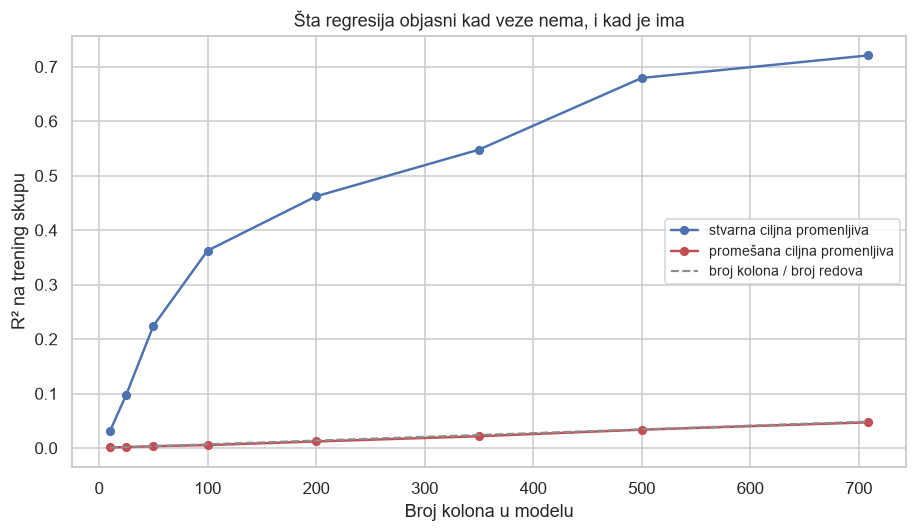

```
 kolona  nezavisnih  R2_stvarna  adj_stvarna  R2_promešana  adj_promešana  kolona/redova
     10          10      0.0308       0.0301        0.0014         0.0008         0.0007
     25          25      0.0975       0.0960        0.0016        -0.0002         0.0017
     50          50      0.2241       0.2215        0.0034        -0.0001         0.0034
    100         100      0.3624       0.3580        0.0053        -0.0015         0.0068
    200         200      0.4621       0.4546        0.0120        -0.0017         0.0137
    350         350      0.5478       0.5367        0.0216        -0.0024         0.0240
    500         499      0.6794       0.6681        0.0336        -0.0005         0.0342
    709         707      0.7209       0.7067        0.0471        -0.0013         0.0485

korelacija stvarne i promešane ciljne promenljive: 0.0092
sa svih 709 kolona (707 nezavisnih):
  stvarna ciljna promenljiva   R² = 0.7209   prilagođeni 0.7067
  promešana                    R² = 0.0471   prilagođeni -0.0013
  za poređenje, kolona/redova  0.0485

najveći prilagođeni R² koji promešana postiže u svih 8 koraka: +0.0008
```

```python
# The target with its rows shuffled: every respondent gets somebody else's pay,
# so nothing in the predictors can explain it. A fixed seed keeps it repeatable.
rng = np.random.default_rng(0)
y_shuffled = pd.Series(rng.permutation(y_train.to_numpy()), index=y_train.index)

# How many columns to give the model at each step, up to all of them.
SIZES = [10, 25, 50, 100, 200, 350, 500, X_train.shape[1]]


def fit_quality(design, targets):
    """R2 and adjusted R2 of a least-squares fit, for several targets at once.

    lstsq is used rather than a regression object because some of these column
    sets are rank-deficient — a few columns are exact combinations of others —
    and it solves that case without complaint. The rank it reports is also the
    honest number of parameters to charge the adjusted R2 for.
    """
    coefficients, _, rank, _ = np.linalg.lstsq(design, targets, rcond=None)
    fitted = design @ coefficients
    rows = len(design)
    out = []
    for column in range(targets.shape[1]):
        observed = targets[:, column]
        residual = observed - fitted[:, column]
        r_squared = 1 - float(residual @ residual) / float(
            (observed - observed.mean()) @ (observed - observed.mean()))
        out.append((r_squared, 1 - (1 - r_squared) * (rows - 1) / (rows - rank)))
    return out, int(rank) - 1


targets = np.column_stack([y_train.to_numpy(), y_shuffled.to_numpy()])
records = []
for size in SIZES:
    picked = (list(X_train.columns) if size == X_train.shape[1]
              else list(rng.choice(X_train.columns, size=size, replace=False)))
    design = np.column_stack([np.ones(len(X_train)), X_train[picked].to_numpy(dtype=float)])
    (real, noise), independent = fit_quality(design, targets)
    records.append({"kolona": size, "nezavisnih": independent,
                    "R2_stvarna": real[0], "adj_stvarna": real[1],
                    "R2_promešana": noise[0], "adj_promešana": noise[1],
                    "kolona/redova": size / len(X_train)})

quality = pd.DataFrame(records)

fig, ax = plt.subplots(figsize=(8.5, 5))
ax.plot(quality["kolona"], quality["R2_stvarna"], marker="o", markersize=5,
        linewidth=1.6, color="#4C72B0", label="stvarna ciljna promenljiva")
ax.plot(quality["kolona"], quality["R2_promešana"], marker="o", markersize=5,
        linewidth=1.6, color="#C44E52", label="promešana ciljna promenljiva")
ax.plot(quality["kolona"], quality["kolona/redova"], linestyle="--", linewidth=1.4,
        color="#8C8C8C", label="broj kolona / broj redova")

ax.set_xlabel("Broj kolona u modelu")
ax.set_ylabel("R² na trening skupu")
ax.set_title("Šta regresija objasni kad veze nema, i kad je ima")
ax.legend(loc="center right", fontsize=9)
plt.tight_layout()
plt.show()

print(quality.round(4).to_string(index=False))
print()
print(f"korelacija stvarne i promešane ciljne promenljive: "
      f"{float(np.corrcoef(y_train, y_shuffled)[0, 1]):.4f}")
biggest = quality.iloc[-1]
print(f"sa svih {int(biggest['kolona'])} kolona ({int(biggest['nezavisnih'])} nezavisnih):")
print(f"  stvarna ciljna promenljiva   R² = {biggest['R2_stvarna']:.4f}   "
      f"prilagođeni {biggest['adj_stvarna']:.4f}")
print(f"  promešana                    R² = {biggest['R2_promešana']:.4f}   "
      f"prilagođeni {biggest['adj_promešana']:+.4f}")
print(f"  za poređenje, kolona/redova  {biggest['kolona/redova']:.4f}")
print()
print(f"najveći prilagođeni R² koji promešana postiže u svih {len(quality)} koraka: "
      f"{quality['adj_promešana'].max():+.4f}")
```

**Zapažanje:** Prilagođavanje se dešava, i to skoro tačno onoliko koliko sledi iz broja kolona.

Crvena kriva **ne stoji na nuli**. Sa deset kolona regresija na promešanoj ciljnoj promenljivoj dobija R² od 0,0014, sa dvesta 0,0120, a sa svih 709 kolona **0,0471** — dakle skoro **pet posto** ciljne promenljive sa kojom po konstrukciji nema nikakve veze. Njena korelacija sa stvarnom platom je 0,0092. Crvena kriva pri tome leži gotovo tačno na isprekidanoj pravoj: odnos broja kolona i broja redova je na kraju **0,0485**, a dobijeni R² 0,0471.

Prilagođeni R² se ponaša sasvim drugačije. Na promešanoj ciljnoj promenljivoj ne prelazi **+0,0008** ni u jednom od osam koraka, a na kraju je **−0,0013**.

Plava kriva raste do **0,7209**, uz prilagođeni R² od **0,7067** — isti broj koji je prethodni notebook izmerio na ovom skupu.

**Tumačenje:** Ovo je ono što se u gradivu naziva krajem bias-variance krive na kom varijansa preuzima posao. Model sa mnogo kolona ima dovoljno slobode da kroz podatke provuče površ koja prati i ono što je puki slučaj, a pošto se ta površ ocenjuje na istim redovima na kojima je i nameštena, izgleda uspešno. Veličina tog efekta nije stvar procene: prati odnos broja kolona i broja redova, pa se sa 709 kolona na 14.608 redova dobija oko pet stotih delova varijanse ni iz čega.

Za nas iz ovoga slede tri stvari.

**R² na trening skupu nije mera kvaliteta modela.** Od 0,7209 koliko dobija stvarni model, oko 0,047 je iste vrste kao ono što bi se dobilo i da podataka nema. To ne znači da je model loš — znači da se po tom broju ne sme suditi.

**Prilagođeni R² tu grešku ispravlja**, i to pouzdano: na promešanoj ciljnoj promenljivoj ostaje oko nule kroz ceo raspon. Zato smo ga u prethodnom notebook-u i koristili kao merilo.

**Ridge i Lasso nisu izbor nego posledica.** Oba rade tako što modelu oduzimaju deo te slobode, a upravo smo izmerili koliko je slobode previše.

Ono što ovim **nije** rešeno jeste kako meriti model na podacima koje nije video. Prilagođeni R² kažnjava broj kolona, ali i dalje gleda iste redove na kojima je model učen. Time se bavi sledeća sekcija.

### Šta sekcija ostavlja sledećoj

Iz sekcije izlazimo sa četiri stvari: matricama prediktora `X_train` i `X_test`, po **709 kolona** svaka i sa istim kolonama u istom redosledu, i ciljnim promenljivama `y_train` i `y_test`, koje su logaritam kompenzacije.

Tri nalaza se prenose dalje:

- **oba skupa imaju isti oblik**, jer je enkodiranje rađeno po kategorijama iz treninga. Vrednosti koje trening ne poznaje nema nijedne, a 12 kolona koje u testu ostaju prazne su cena tog izbora i ne smetaju;
- **21 red po koloni je premalo, i to je izmereno, ne pretpostavljeno.** Na nasumično promešanoj ciljnoj promenljivoj regresija sa 709 kolona dobija R² od 0,0471, pa toliko od trening rezultata otpada na prilagođavanje šumu. Prilagođeni R² tu grešku ispravlja, ali i dalje gleda iste redove na kojima je model učen;
- **skale kolona se razlikuju do 895 puta**, pa je standardizacija uz Ridge i Lasso obavezna — ali ide unutar unakrsne validacije, ne pre nje.

Ostaje da se dogovorimo **čime merimo** da li je model dobar, pre nego što napravimo ijedan. To je posao sledeće sekcije.

## 2. Čime merimo model

Odeljak 1.5 je pokazao da R² na trening skupu nije mera kvaliteta: od 0,7209 koliko dobija stvarni model, oko 0,047 je iste vrste kao ono što bi se dobilo i da veze u podacima nema. Prilagođeni R² tu grešku ispravlja, ali i on gleda **iste redove** na kojima je model učen.

Zato merila postavljamo sada, pre nego što napravimo ijedan model, i tražimo od njih tri stvari.

**Da se računaju na redovima koje model nije video.** To rešava unakrsna validacija, koju smo učili na predavanjima: skup se podeli na delove, model se uči na svim delovima osim jednog, a proverava na tom jednom, pa se postupak ponovi za svaki deo. Tako svaki ispitanik bude predviđen modelom koji njega nije imao pred sobom.

**Da se mogu pročitati u dolarima.** Model uči logaritam plate, pa je i greška u logaritmu. Broj kao „RMSE = 0,2" nikome ništa ne znači, a označava nešto vrlo konkretno — i to prevodimo.

**Da uz njih stoji referentna tačka.** R² od 0,54 zvuči osrednje ili dobro u zavisnosti od toga sa čim se poredi. Zato prvo izmerimo šta dobija najprostije moguće predviđanje, pa se svaki dalji model čita naspram toga.

### 2.1 Greška u logaritmu i greška u dolarima

Pošto je ciljna promenljiva dekadni logaritam, razlika predviđene i stvarne vrednosti nije razlika u dolarima nego **odnos**: ako se predviđanje i stvarna plata razlikuju za `d` u logaritmu, onda je `predviđeno / stvarno = 10^d`. Greška se zato u dolarima ne izražava kao iznos nego kao **koliko puta** model promaši, i to je za platu i prirodnije — isti promašaj u dolarima ne znači isto kod niske i kod visoke plate.

Uz standardna tri merila (RMSE, MAE, R²) računamo zato i četiri koja se čitaju bez prevođenja. Nisu izabrana po osećaju nego izvedena iz gornje veze. **Koliko puta model promaši** je direktan prevod greške iz logaritma. **Medijana promašaja u procentima i u dolarima** je isti taj broj u dva oblika — jednom bez iznosa, jednom sa njim, jer „promaši za četvrtinu" i „promaši za 17.000 dolara" ne znače istom čitaocu isto. Preostala dva su pragovi, i uzimamo ih tamo gde su okrugli **u jedinici u kojoj model radi**: predviđanje **u okviru dvostruko** je tačno greška od 0,30 u logaritmu, a **u okviru četvrtine** otprilike 0,10. Prvi prag kaže koliko često predviđanje nije grubo promašeno, drugi koliko često je upotrebljivo.

Jednu stvar treba razjasniti odmah, jer se lako pogreši. `10^ŷ` daje iznos u dolarima i ništa komplikovanije od toga — ali taj iznos **nije procena prosečne plate** takvog ispitanika. Prosek u dolarima podižu najveće plate, pa leži osetno iznad onoga što se dobija stepenovanjem sredine logaritma; ispis ispod pokazuje koliko se te dve veličine razilaze već na celom trening skupu. Zato sve dolarske iznose u nastavku prijavljujemo kao **medijane**, nikad kao aritmetičke sredine.

```python
from sklearn.model_selection import KFold


def metrics(actual, predicted):
    """Errors of a prediction of the logged pay, in the logarithm and in dollars.

    The target is a base-10 logarithm, so a difference of d between prediction
    and truth means the prediction is 10**d times the real amount. That ratio is
    what the dollar-side numbers are built on.
    """
    actual = np.asarray(actual, dtype=float)
    predicted = np.asarray(predicted, dtype=float)
    error = predicted - actual
    centered = actual - actual.mean()
    ratio = 10.0 ** error
    rmse = float(np.sqrt(np.mean(error ** 2)))
    mae = float(np.mean(np.abs(error)))
    return {
        "RMSE_log": rmse,
        "MAE_log": mae,
        "R2": 1 - float(error @ error) / float(centered @ centered),
        "puta_RMSE": 10 ** rmse,
        "puta_MAE": 10 ** mae,
        "promašaj_%": float(np.median(np.abs(ratio - 1)) * 100),
        "promašaj_USD": float(np.median(np.abs(10.0 ** predicted - 10.0 ** actual))),
        "u_okviru_25%": float(np.mean(np.abs(ratio - 1) <= 0.25) * 100),
        "u_okviru_2x": float(np.mean((ratio >= 0.5) & (ratio <= 2)) * 100),
    }


def show_metrics(table):
    """Print a table of measures, each column formatted the way it reads best."""
    out = pd.DataFrame(index=table.index)
    for column, form in [("RMSE_log", "{:.4f}"), ("MAE_log", "{:.4f}"), ("R2", "{:+.4f}"),
                         ("puta_RMSE", "{:.2f}x"), ("puta_MAE", "{:.2f}x"),
                         ("promašaj_%", "{:.1f}%"), ("promašaj_USD", "{:,.0f}"),
                         ("u_okviru_25%", "{:.1f}%"), ("u_okviru_2x", "{:.1f}%")]:
        out[column] = table[column].map(form.format)
    print(out.to_string())


print("koliko puta model promaši, u zavisnosti od greške u logaritmu:")
for step in [0.05, 0.10, 0.15, 0.20, 0.30, 0.50]:
    print(f"  greška {step:.2f} u log10  ->  odnos {10 ** step:.2f}x   "
          f"promašaj {100 * (10 ** step - 1):+.0f}%")
print()
print(f"standardna devijacija ciljne promenljive (log10): {y_train.std(ddof=0):.4f}")
print(f"prosek log10 {y_train.mean():.4f} -> {10 ** y_train.mean():>9,.0f} USD")
print(f"medijana     {y_train.median():.4f} -> {10 ** y_train.median():>9,.0f} USD")
print()
# Why every dollar figure in this notebook is a median: three middle values of
# the same distribution, thirty thousand dollars apart.
print("ista raspodela, tri srednje vrednosti u dolarima:")
print(f"  aritmetička sredina plate  {train[TARGET].mean():>9,.0f}")
print(f"  medijana plate             {train[TARGET].median():>9,.0f}")
print(f"  10 na prosek logaritma     {10 ** y_train.mean():>9,.0f}")
```

```
koliko puta model promaši, u zavisnosti od greške u logaritmu:
  greška 0.05 u log10  ->  odnos 1.12x   promašaj +12%
  greška 0.10 u log10  ->  odnos 1.26x   promašaj +26%
  greška 0.15 u log10  ->  odnos 1.41x   promašaj +41%
  greška 0.20 u log10  ->  odnos 1.58x   promašaj +58%
  greška 0.30 u log10  ->  odnos 2.00x   promašaj +100%
  greška 0.50 u log10  ->  odnos 3.16x   promašaj +216%

standardna devijacija ciljne promenljive (log10): 0.4390
prosek log10 4.8298 ->    67,584 USD
medijana     4.9096 ->    81,210 USD

ista raspodela, tri srednje vrednosti u dolarima:
  aritmetička sredina plate     94,499
  medijana plate                81,210
  10 na prosek logaritma        67,584
```

**Zapažanje:** Prevod je nelinearan, i to menja način na koji se svaki dalji rezultat čita. Greška od **0,05** u logaritmu znači da je predviđanje **1,12 puta** stvarnog iznosa, dakle promašaj od 12%. Greška od **0,15** daje **1,41 puta** (41%), a greška od **0,30** tačno **2,00 puta**, dakle promašaj od 100%.

Standardna devijacija ciljne promenljive je **0,4390** u logaritmu. Prosek logaritma je **4,8298**, što je **67.584 dolara**, a medijana **4,9096**, odnosno **81.210**.

**Tumačenje:** Prva tabela daje skalu na kojoj ćemo čitati sve dalje. Ako model dobije RMSE oko 0,30, to nije „mala greška u logaritmu" nego promašaj od dvostruko — što za predviđanje plate nije upotrebljivo. Da bi predviđanje bilo u okviru četvrtine, greška mora da padne ispod 0,10.

Razlika proseka i medijane logaritma pokazuje isto ono što je prethodni notebook našao kod asimetrije: i posle čišćenja je raspodela logaritma iskošena ulevo, pa je prosek niži od medijane.

### 2.2 Zašto unakrsna validacija, i sa koliko delova

Postupak je onaj sa predavanja: trening skup podelimo na `k` delova, pa `k` puta učimo model na `k − 1` dela i predviđamo onaj koji je izostavljen. Na kraju je **svaki red predviđen modelom koji ga nije video**, pa se metrike računaju nad predviđanjima koja nisu mogla da budu naučena napamet.

Jedan detalj vredi zapisati, jer se izvodi na dva načina. Mi predviđanja iz svih deset delova sastavimo u **jedan niz** i metriku računamo **jednom, nad svih 14.608 redova**. Druga mogućnost je izračunati R² u svakom delu posebno pa uzeti prosek tih deset brojeva — to nije ista veličina, jer takav prosek zavisi i od toga koliko je koji deo ispao lak. Ispis ispod daje i tih deset pojedinačnih vrednosti, ali samo zato da se vidi koliko se međusobno razlikuju.

Broj delova ne biramo po osećaju. Sa predavanja znamo tri mogućnosti: validacioni skup (jedna podela), `k`-fold i LOOCV. LOOCV bi ovde značio 14.608 modela sa po 709 kolona, što je neizvodljivo, a jedna podela bi rezultat vezala za to kako je ispala. Ostaje `k`-fold, a da izbor između 5 i 10 delova ne bi bio proizvoljan, izmerićemo oba na istom modelu i videti da li se razlikuju.

Uz to imamo priliku da proverimo i samu metodu. U odeljku 1.5 smo videli da regresija sa 709 kolona na **promešanoj** ciljnoj promenljivoj dobija R² od 0,0471 na trening skupu. Ako unakrsna validacija radi ono zbog čega je uvodimo, na istoj promešanoj koloni mora da da nulu ili manje — jer model tamo nema šta da nauči, pa na izostavljenom delu ne može ništa da pogodi.

```python
# Ten parts, and the same seed the previous notebook used for the split, so a
# rerun gives the same folds.
FOLDS = 10
# The same seed the cleaning notebook used for the train/test split.
SEED = 42


def ols_fit_predict(design_fit, target_fit, design_eval):
    """Least squares on one part of the rows, prediction on another.

    lstsq again rather than a regression object, for the same reason as in 1.5:
    some of these designs are rank-deficient and it handles that case quietly.
    """
    coefficients, _, _, _ = np.linalg.lstsq(design_fit, target_fit, rcond=None)
    return design_eval @ coefficients


def with_intercept(columns):
    """The design matrix for these columns, with a column of ones in front."""
    if not columns:
        return np.ones((len(X_train), 1))
    return np.column_stack([np.ones(len(X_train)), X_train[columns].to_numpy(dtype=float)])


def cross_validated(design, target, fit_predict=ols_fit_predict, folds=FOLDS, seed=SEED):
    """Predictions made out of fold, one per row of the training set."""
    target = np.asarray(target, dtype=float)
    out = np.empty(len(target))
    splitter = KFold(n_splits=folds, shuffle=True, random_state=seed)
    for fit_rows, eval_rows in splitter.split(design):
        out[eval_rows] = fit_predict(design[fit_rows], target[fit_rows], design[eval_rows])
    return out


country_columns = [c for c in X_train.columns if c.startswith("Country_")]
country_design = with_intercept(country_columns)

print("da li broj delova menja rezultat (model: samo Country):")
for folds in (5, 10):
    predicted = cross_validated(country_design, y_train, folds=folds)
    measured = metrics(y_train, predicted)
    print(f"  {folds:>2} delova:  R² {measured['R2']:.4f}   RMSE {measured['RMSE_log']:.4f}")
print()

print(f"R² po pojedinačnom delu, pri {FOLDS} delova:")
splitter = KFold(n_splits=FOLDS, shuffle=True, random_state=SEED)
per_fold = []
for number, (fit_rows, eval_rows) in enumerate(splitter.split(country_design), start=1):
    predicted = ols_fit_predict(country_design[fit_rows], y_train.to_numpy()[fit_rows],
                                country_design[eval_rows])
    per_fold.append(metrics(y_train.to_numpy()[eval_rows], predicted)["R2"])
print("  " + "  ".join(f"{value:.3f}" for value in per_fold))
print(f"  najmanji {min(per_fold):.4f}   najveći {max(per_fold):.4f}   "
      f"raspon {max(per_fold) - min(per_fold):.4f}")
print()

# The same shuffled target as in 1.5: if cross-validation works, it cannot find
# anything there.
full_design = with_intercept(list(X_train.columns))
noise_predicted = cross_validated(full_design, y_shuffled)
print("promešana ciljna promenljiva, svih 709 kolona:")
print(f"  R² na trening skupu, iz 1.5:        {quality.iloc[-1]['R2_promešana']:+.4f}")
print(f"  R² po unakrsnoj validaciji:         {metrics(y_shuffled, noise_predicted)['R2']:+.4f}")
```

```
da li broj delova menja rezultat (model: samo Country):
   5 delova:  R² 0.5421   RMSE 0.2971
```

```
  10 delova:  R² 0.5429   RMSE 0.2968

R² po pojedinačnom delu, pri 10 delova:
  0.526  0.560  0.519  0.550  0.545  0.573  0.521  0.545  0.546  0.538
  najmanji 0.5188   najveći 0.5727   raspon 0.0539
```

```
promešana ciljna promenljiva, svih 709 kolona:
  R² na trening skupu, iz 1.5:        +0.0471
  R² po unakrsnoj validaciji:         -0.0573
```

**Zapažanje:** Broj delova ne menja rezultat. Sa 5 delova model sa samom zemljom dobija R² **0,5421**, sa 10 delova **0,5429** — razlika je na trećoj decimali. R² po pojedinačnim delovima kreće se od **0,5188** do **0,5727**, dakle raspon je **0,0539**.

Provera metode prolazi, i to jasnije nego što se očekivalo. Na promešanoj ciljnoj promenljivoj sa svih 709 kolona R² na trening skupu iznosi **+0,0471**, a po unakrsnoj validaciji **−0,0573**.

**Tumačenje:** To što 5 i 10 delova daju isto znači da izbor nije taj koji vodi rezultat, pa uzimamo **10 delova** — više dela za učenje po prolazu, a cena je zanemarljiva. Raspon od 0,0539 između najgoreg i najboljeg dela je pri tome podsetnik da jedna podela ne bi bila dovoljna: da smo uzeli samo jedan validacioni skup, mogli smo dobiti 0,52 ili 0,57 zavisno od toga koji je ispao.

Druga provera je važnija. Na promešanoj koloni unakrsna validacija ne daje samo nulu nego **negativan** R², i to nije greška u računu. Negativan R² znači da je model **gori od predviđanja prosekom** — što je tačno ono što se očekuje: model je na svom delu naučio slučajne razlike, pa ih na izostavljenom delu primenjuje tamo gde ih nema, i time aktivno pogoršava predviđanje.

Time je pitanje iz 1.5 zatvoreno. Trening R² od 0,0471 i unakrsni R² od −0,0573 su ista stvar viđena sa dve strane: prvo je mera koliko se model prilagodio šumu, drugo je mera koliko ga to košta kod novih ljudi. Sve dalje merimo drugim.

### 2.3 Donja granica: predviđanje bez ijednog prediktora

Prvi stepenik je najniži zamisliv. Svakom ispitaniku damo **isti broj**, i to je celo predviđanje — nijedna kolona se ne gleda. Taj broj se, kao i sve ostalo, računa **na delu na kom se uči** pa primenjuje na izostavljeni deo, dakle prolazi kroz istu unakrsnu validaciju kao pravi modeli. To je najgore što se može uraditi a da se i dalje zove predviđanje, i ništa što u nastavku nazovemo modelom ne sme biti gore.

Ostaje pitanje **koji** broj, i ono nije formalno. Sa predavanja znamo da RMSE i MAE ne minimizuje ista vrednost: zbir kvadrata odstupanja najmanji je oko **proseka**, zbir apsolutnih odstupanja oko **medijane**. Da su plate simetrično raspoređene, ta dva broja bi se poklopila i pitanje ne bi ni postojalo; kod nas se razilaze — u 2.1 smo videli da je prosek logaritma 4,8298 a medijana 4,9096. Zato računamo **obe konstante** i pustimo merila da pokažu koja gde pobeđuje, umesto da unapred izaberemo jednu.

```python
def median_fit_predict(design_fit, target_fit, design_eval):
    """The simplest prediction there is: the median of the rows it was fitted on."""
    return np.full(len(design_eval), float(np.median(target_fit)))


def mean_fit_predict(design_fit, target_fit, design_eval):
    """The same, with the mean instead of the median."""
    return np.full(len(design_eval), float(np.mean(target_fit)))


intercept_only = with_intercept([])
baselines = {
    "medijana treninga": cross_validated(intercept_only, y_train, median_fit_predict),
    "prosek treninga": cross_validated(intercept_only, y_train, mean_fit_predict),
}
floor = pd.DataFrame({name: metrics(y_train, predicted)
                      for name, predicted in baselines.items()}).T
show_metrics(floor)
print()
for column, better in [("RMSE_log", "min"), ("MAE_log", "min"), ("promašaj_%", "min"),
                       ("u_okviru_2x", "max")]:
    winner = floor[column].idxmin() if better == "min" else floor[column].idxmax()
    print(f"  po {column:<14} bolja je {winner}")
```

```
                  RMSE_log MAE_log       R2 puta_RMSE puta_MAE promašaj_% promašaj_USD u_okviru_25% u_okviru_2x
medijana treninga   0.4462  0.2965  -0.0330     2.79x    1.98x      42.8%       36,718        29.6%       66.4%
prosek treninga     0.4390  0.3054  -0.0001     2.75x    2.02x      44.8%       36,315        27.6%       62.2%

  po RMSE_log       bolja je prosek treninga
  po MAE_log        bolja je medijana treninga
  po promašaj_%     bolja je medijana treninga
  po u_okviru_2x    bolja je medijana treninga
```

**Zapažanje:** Dve konstante se razlikuju, i to na predvidiv način. **Prosek** daje niži RMSE (**0,4390** naspram 0,4462) i R² bliži nuli (**−0,0001** naspram −0,0330). **Medijana** daje niži MAE (**0,2965** naspram 0,3054), manji tipičan promašaj (**42,8%** naspram 44,8%) i više ispitanika u okviru dvostruko (**66,4%** naspram 62,2%).

**Tumačenje:** Rezultat je provera da merila rade ono što od njih očekujemo, a ne nalaz o podacima — prosek pobeđuje tamo gde se greška kvadrira, medijana tamo gde se ne kvadrira, tačno kao što sledi iz definicija. Da je ispalo obrnuto, tražili bismo grešku u kodu.

Praktična posledica je da **donja granica nije jedan broj nego zavisi od merila**, pa ćemo u nastavku navoditi oba. Za R² uzimamo prosek kao donju granicu, jer je R² građen oko kvadratne greške.

Obe donje granice su pri tome **negativne**. To nije greška: konstanta se računa na delu za učenje pa primenjuje na izostavljeni deo, i time je za taj deo neznatno pogrešna. Nula na unakrsnom R² je, dakle, već malo bolja od ničega.

### 2.4 Koje pojedinačno obeležje je najjače

Donja granica je preniska da bi bila korisna. Model sa 709 kolona koji pobedi konstantu nije pokazao ništa — pravo pitanje je da li pobeđuje **jedno jedino anketno pitanje**.

Iz prethodnog notebook-a nosimo uverenje da je to pitanje `Country`, ali ono je tamo izmereno drugim merilom (prilagođeni R² na trening skupu) i na drugačije sažetoj promenljivoj. Ovde ga zato ne pretpostavljamo nego merimo iznova, istom unakrsnom validacijom kojom merimo sve ostalo, i to **za svako** nasleđeno anketno obeležje.

Obeležjem smatramo jedno anketno pitanje: to je jedna kolona kod većine, a kod rang-pitanja ceo blok kolona koji je iz njega izvezen. Promenljive koje smo sami napravili ovde ne ulaze — one se mere kasnije, naspram letvice koju upravo postavljamo.

```python
# The four ranking questions; each was exported as one column per offered item,
# so the question, not the column, is the feature.
RANK_PREFIXES = ("TechEndorse_", "TechOppose_", "JobSatPoints_", "SO_Actions_")
# The prefixes of everything this project derived, which is what "inherited" excludes.
DERIVED_PREFIXES = ("Chose_", "Count_", "KeptShare_", "NotAnswered_")

inherited = [c for c in predictors if not c.startswith(DERIVED_PREFIXES)]
features = {c: [c] for c in inherited if not c.startswith(RANK_PREFIXES)}
for prefix in RANK_PREFIXES:
    features[prefix.rstrip("_")] = [c for c in inherited if c.startswith(prefix)]



def encoded_columns_for(names):
    """Where these survey features sit in the encoded matrix.

    A numeric column keeps its name. A categorical one was expanded into dummy
    columns called "<column>_<category>", so it is found by that prefix instead.
    """
    found = []
    for name in names:
        if name in X_train.columns:
            found.append(name)
        else:
            found.extend(c for c in X_train.columns if c.startswith(name + "_"))
    return found


def cv_r2_of(names):
    """Cross-validated R2 of a model built from these survey features alone."""
    design = with_intercept(encoded_columns_for(names))
    return metrics(y_train, cross_validated(design, y_train))["R2"], design.shape[1] - 1


# Every inherited column has to land in exactly one feature, otherwise the table
# below would be measuring something other than what it claims.
claimed = [c for columns in features.values() for c in encoded_columns_for(columns)]
print(f"nasleđenih kolona: {len(inherited)}   anketnih obeležja: {len(features)}")
print(f"kolona modela koje ta obeležja pokrivaju: {len(claimed)}   "
      f"bez ponavljanja: {len(set(claimed)) == len(claimed)}")
print()


single = pd.DataFrame(
    [{"obeležje": name, "kolona": width, "CV_R2": value}
     for name, (value, width) in ((name, cv_r2_of(columns)) for name, columns in features.items())]
).sort_values("CV_R2", ascending=False).reset_index(drop=True)

print("osam najjačih pojedinačnih obeležja:")
print(single.head(8).to_string(index=False,
                               formatters={"CV_R2": "{:.4f}".format}))
print()
print("tri najslabija:")
print(single.tail(3).to_string(index=False, formatters={"CV_R2": "{:.4f}".format}))
print()
print(f"najjače:  {single.loc[0, 'obeležje']} = {single.loc[0, 'CV_R2']:.4f}")
print(f"drugo:    {single.loc[1, 'obeležje']} = {single.loc[1, 'CV_R2']:.4f}   "
      f"razlika {single.loc[0, 'CV_R2'] - single.loc[1, 'CV_R2']:.4f}")
print(f"treće:    {single.loc[2, 'obeležje']} = {single.loc[2, 'CV_R2']:.4f}   "
      f"razlika {single.loc[1, 'CV_R2'] - single.loc[2, 'CV_R2']:.4f}")
print(f"obeležja sa negativnim CV R²: {int((single['CV_R2'] < 0).sum())} od {len(single)}")

# Whichever feature came out strongest becomes the second reference point, so the
# choice follows the measurement instead of being made in advance.
best_feature = str(single.loc[0, "obeležje"])
baselines[f"samo {best_feature}"] = cross_validated(
    with_intercept(encoded_columns_for(features[best_feature])), y_train)
print()
print(f"druga referentna tačka je time određena: samo {best_feature}")
```

```
nasleđenih kolona: 75   anketnih obeležja: 43
kolona modela koje ta obeležja pokrivaju: 357   bez ponavljanja: True
```

```
osam najjačih pojedinačnih obeležja:
    obeležje  kolona  CV_R2
     Country      61 0.5429
    Currency      81 0.4821
  SODuration       7 0.1829
         Age       6 0.1552
   YearsCode       1 0.1479
     WorkExp       1 0.1280
JobSatPoints      13 0.0660
     OrgSize       1 0.0398

tri najslabija:
         obeležje  kolona   CV_R2
       Employment       1  0.0001
ToolCountPersonal       1  0.0000
      LearnCodeAI       5 -0.0002

najjače:  Country = 0.5429
drugo:    Currency = 0.4821   razlika 0.0608
treće:    SODuration = 0.1829   razlika 0.2992
obeležja sa negativnim CV R²: 1 od 43

druga referentna tačka je time određena: samo Country
```

**Zapažanje:** Merenje potvrđuje ono što smo nosili iz prethodnog notebook-a, ali uz dve stvari koje se odatle nisu videle.

**`Country` je najjače**, sa CV R² od **0,5429**. Drugo je **`Currency` sa 0,4821**, dakle svega **0,0608** iza. Treće je `SODuration` sa **0,1829** — a razlika između drugog i trećeg je **0,2992**, skoro pet puta veća od razlike između prvog i drugog.

Zatim slede `Age` (0,1552), `YearsCode` (0,1479) i `WorkExp` (0,1280). Od **43** obeležja, njih **42** ima pozitivan CV R², a jedno negativan.

**Tumačenje:** Letvica je time izmerena, a ne uvezena: **0,5429**, i to je `Country`.

To što jedno obeležje ima negativan CV R² je pri tome poučno na isti način kao donja granica iz 2.3: obeležje koje ne nosi ništa na unakrsnoj validaciji ne dobija nulu nego **malo manje od nule**, jer model potroši jedan koeficijent na šum.

### 2.5 Prava mera: sve što je anketa dala, bez ijedne naše promenljive

Najjače pojedinačno obeležje je poštena letvica za jednu promenljivu, ali ne i za ceo prethodni notebook. Ako se model sa 709 kolona poredi sa zemljom samom, pobeda mu je zagarantovana i ništa ne dokazuje — pobediće je već i time što uz zemlju ima valutu i uzrast.

Zato postavljamo i treći stepenik, i on je onaj koji stvarno nešto proverava: **model od svih anketnih obeležja u obliku u kom su došla iz čišćenja, bez ijedne promenljive koju smo sami napravili.** To je `Country`, `Currency`, `DevType`, uzrast, staž, rangiranja i ostalo — dakle 75 kolona iz odeljka 1.2, ili 357 kolona posle enkodiranja.

Ako model sa svim promenljivama ne pređe taj broj, feature engineering iz prethodnog notebook-a nije doneo ništa što anketa nije već imala. Letvicu postavljamo **sada, pre nego što napravimo prvi model**, baš zato da posle ne bismo birali poređenje koje nam odgovara.

```python
inherited_encoded = encoded_columns_for(inherited)
inherited_r2, inherited_width = cv_r2_of(inherited)
baselines["sva anketna obeležja"] = cross_validated(
    with_intercept(inherited_encoded), y_train)

reference = pd.DataFrame({name: metrics(y_train, predicted)
                          for name, predicted in baselines.items()}).T
show_metrics(reference)
print()
derived = [c for c in predictors if c.startswith(DERIVED_PREFIXES)]
print(f"{'nasleđenih kolona u modelu':<34} {inherited_width:>4}   "
      f"(od {len(inherited)} prediktora)")
print(f"{'naših kolona u modelu':<34} {X_train.shape[1] - inherited_width:>4}   "
      f"(od {len(derived)} prediktora)")
print(f"{'ukupno':<34} {X_train.shape[1]:>4}")
print()
print(f"letvica koju model sa svim promenljivama mora da pređe: {inherited_r2:.4f}")
print(f"  koliko od toga nosi sama zemlja: {single.loc[0, 'CV_R2'] / inherited_r2 * 100:.0f}%")
print(f"  koliko dodaje sve ostalo iz ankete: "
      f"{inherited_r2 - single.loc[0, 'CV_R2']:+.4f}")
```

```
                     RMSE_log MAE_log       R2 puta_RMSE puta_MAE promašaj_% promašaj_USD u_okviru_25% u_okviru_2x
medijana treninga      0.4462  0.2965  -0.0330     2.79x    1.98x      42.8%       36,718        29.6%       66.4%
prosek treninga        0.4390  0.3054  -0.0001     2.75x    2.02x      44.8%       36,315        27.6%       62.2%
samo Country           0.2968  0.2047  +0.5429     1.98x    1.60x      32.1%       22,186        40.6%       79.2%
sva anketna obeležja   0.2534  0.1652  +0.6668     1.79x    1.46x      25.5%       17,568        49.2%       86.7%

nasleđenih kolona u modelu          357   (od 75 prediktora)
naših kolona u modelu               352   (od 352 prediktora)
ukupno                              709

letvica koju model sa svim promenljivama mora da pređe: 0.6668
  koliko od toga nosi sama zemlja: 81%
  koliko dodaje sve ostalo iz ankete: +0.1239
```

**Zapažanje:** Sva anketna obeležja zajedno daju CV R² od **0,6668**, sa **357** kolona. Sama zemlja nosi **81%** te vrednosti, a sve ostalo iz ankete dodaje **+0,1239**.

Iz iste tabele se vidi i šta to znači u dolarima: tipičan promašaj pada sa 32,1% kod same zemlje na **25,5%**, odnosno sa 22.186 na **17.568 dolara**, a udeo ispitanika u okviru dvostruko raste sa 79,2% na **86,7%**.

**Tumačenje:** Ovo je letvica za sve dalje, i postavljena je pre prvog modela. Naših **352** kolone — koje posle enkodiranja daju 352 kolone modela — moraju da pređu **0,6668** da bi bile opravdane, i to je mnogo zahtevnije od 0,5429 koliko daje sama zemlja.

Zašto se ne poredimo sa zemljom, nije samo po sebi jasno. Model sa 709 kolona bi zemlju pobedio i bez ijedne naše promenljive, samo zahvaljujući valuti i uzrastu, pa bi takvo poređenje merilo anketu a pripisivalo zaslugu nama. Poređenje sa svim anketnim obeležjima to isključuje: ono što ostane iznad 0,6668 je isključivo doprinos prethodnog notebook-a.

Ostaje da se kaže i šta ovaj broj **nije**. On nije rezultat na test skupu — sve je mereno unakrsnom validacijom nad treningom. I nije konačan izbor modela, jer obična regresija sa 709 kolona nije jedini kandidat; upravo smo u 1.5 videli koliko slobode ona ima.

### Grafik 2 — kako se greška sužava sa svakim stepenikom

**Motivacija:** Tabela daje po jedan broj za svaki stepenik, ali sažima celu raspodelu u medijanu i procenat. Nas zanima i **oblik**: da li se sa svakim stepenikom greška sužava ravnomerno kod svih, ili se popravlja kod većine a ostaje ista kod manjine. To je važno jer se dva modela sa istim MAE mogu ponašati sasvim različito — jedan promašuje malo kod svih, drugi tačno kod većine a katastrofalno kod nekih.

Crtamo raspodelu odnosa `predviđeno / stvarno` za sva tri stepenika, na logaritamskoj osi, jer je na njoj promašaj od dva puta na gore jednako daleko od jedinice kao promašaj od dva puta na dole.

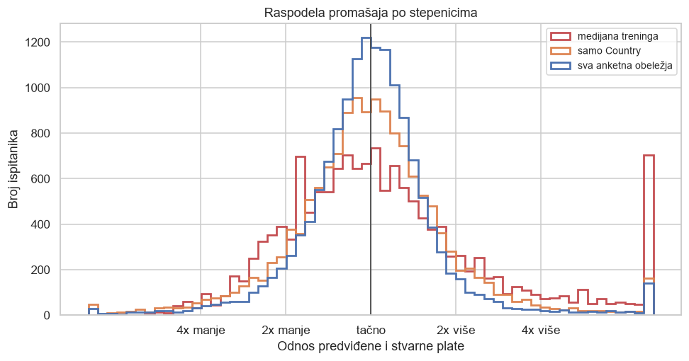

```
stepenik                5. pct 25. pct 50. pct 75. pct 95. pct
medijana treninga        0.37   0.65   1.00   1.67   8.73
samo Country             0.36   0.71   0.98   1.37   2.75
sva anketna obeležja     0.44   0.76   0.99   1.28   2.18

medijana treninga      preceni kod 49.1% ispitanika, promaši više od 4x kod 10.9%, izvan opsega grafika 654
samo Country           preceni kod 48.7% ispitanika, promaši više od 4x kod  4.8%, izvan opsega grafika 192
sva anketna obeležja   preceni kod 49.1% ispitanika, promaši više od 4x kod  3.4%, izvan opsega grafika 151
```

```python
fig, ax = plt.subplots(figsize=(9, 4.8))
edges = np.logspace(np.log10(0.1), np.log10(10), 61)
# The three steps drawn here, each keeping its colour for the rest of the notebook.
COLORS = {"medijana treninga": "#C44E52", f"samo {best_feature}": "#DD8452",
          "sva anketna obeležja": "#4C72B0"}

outside = {}
for name, color in COLORS.items():
    ratio = 10.0 ** (baselines[name] - y_train.to_numpy())
    outside[name] = int(np.sum((ratio < edges[0]) | (ratio > edges[-1])))
    # Clipped, not dropped: without this the worst misses would simply be missing
    # from the picture instead of piling up in the edge bins.
    ax.hist(np.clip(ratio, edges[0], edges[-1]), bins=edges, histtype="step",
            linewidth=1.8, color=color, label=name)

ax.axvline(1, color="#4C4C4C", linewidth=1.2)
ax.set_xscale("log")
ax.set_xticks([0.25, 0.5, 1, 2, 4])
ax.set_xticklabels(["4x manje", "2x manje", "tačno", "2x više", "4x više"])
ax.set_xlabel("Odnos predviđene i stvarne plate")
ax.set_ylabel("Broj ispitanika")
ax.set_title("Raspodela promašaja po stepenicima")
ax.legend(fontsize=9)
plt.tight_layout()
plt.show()

print(f"{'stepenik':<22} " + " ".join(f"{q:>2}. pct" for q in (5, 25, 50, 75, 95)))
for name in COLORS:
    ratio = 10.0 ** (baselines[name] - y_train.to_numpy())
    values = " ".join(f"{np.percentile(ratio, q):>6.2f}" for q in (5, 25, 50, 75, 95))
    print(f"{name:<22} {values}")
print()
for name in COLORS:
    ratio = 10.0 ** (baselines[name] - y_train.to_numpy())
    print(f"{name:<22} preceni kod {100 * np.mean(ratio > 1):>4.1f}% ispitanika, "
          f"promaši više od 4x kod {100 * np.mean((ratio > 4) | (ratio < 0.25)):>4.1f}%, "
          f"izvan opsega grafika {outside[name]:>3}")
```

**Zapažanje:** Sva tri stepenika su usredsređena oko jedinice, a razlikuju se po širini i po repovima.

Srednjih pola ispitanika je kod **medijane treninga** između **0,65 i 1,67 puta** stvarne plate, kod **same zemlje** između **0,71 i 1,37**, a kod **svih anketnih obeležja** između **0,76 i 1,28**. Peti i devedeset peti percentil idu od **0,37 i 8,73** kod medijane, preko **0,36 i 2,75** kod zemlje, do **0,44 i 2,18** kod svih obeležja.

Smer promašaja je kod svih uravnotežen — precenjeno je između **48,7%** i **49,1%** ispitanika. Veličina nije: promašaj veći od četiri puta pada sa **10,9%** kod medijane na **4,8%** kod zemlje i **3,4%** kod svih obeležja.

Stubić na samom desnom kraju nije gomila oko desetostrukog promašaja nego **sve što je izvan opsega grafika**, sabrano u poslednju kutiju: kod medijane treninga **654** ispitanika, a kod svih anketnih obeležja **151**. Bez tog sabiranja bi ti redovi sa slike prosto nedostajali, pa bi grafik izgledao bolje nego što stvari stoje.

**Tumačenje:** Oblik objašnjava zašto uz medijanu promašaja gledamo i udeo u okviru dvostruko. Kod medijane treninga je „tipičan" promašaj 42,8%, ali kod svakog devetog ispitanika predviđanje nije ni približno upotrebljivo. Sa svim anketnim obeležjima taj udeo pada na **3,4%** — a tipičan promašaj i dalje ostaje **25,5%**, dakle četvrtina plate.

### Šta sekcija ostavlja sledećoj

Merila su postavljena pre nego što je napravljen ijedan model: **RMSE, MAE i R²** u logaritmu, uz **koliko puta model promaši**, medijanu promašaja u procentima i dolarima, i udeo ispitanika kod kojih je predviđanje u okviru četvrtine odnosno dvostruko. Sve se računa **unakrsnom validacijom sa 10 delova** nad trening skupom, na istim delovima za svaki model.

Uz njih su izmerena, a ne izabrana, tri stepenika prema kojima se sve dalje čita:

| stepenik | kolona | CV R² | tipičan promašaj |
| --- | --- | --- | --- |
| konstanta (prosek treninga) | 0 | −0,0001 | 44,8% |
| najjače pojedinačno obeležje (`Country`) | 61 | 0,5429 | 32,1% |
| sva anketna obeležja, bez naših | 357 | 0,6668 | 25,5% |

Četiri nalaza se prenose dalje:

- **unakrsna validacija radi ono zbog čega je uvedena.** Na promešanoj ciljnoj promenljivoj daje −0,0573, dok trening R² daje +0,0471. Izbor između 5 i 10 delova ne menja rezultat, ali jedna jedina podela bi ga menjala — R² po delovima ide od 0,5188 do 0,5727;
- **donja granica zavisi od merila.** Prosek pobeđuje po RMSE, medijana po MAE, i obe donje granice su blago negativne;
- **zemlja i valuta se odvajaju od svega ostalog.** `Country` daje 0,5429, `Currency` 0,4821, a treće obeležje po jačini svega 0,1829. Nije, dakle, tačno da signal nosi samo zemlja;
- **letvica za prethodni notebook je 0,6668.** Naših 352 kolone opravdane su samo onoliko koliko model pređe taj broj — ne 0,5429, jer bi zemlju pobedila i sama anketa.

Test skup i dalje nije dodirnut. Sledeća sekcija gradi prvi pravi model — običnu višestruku regresiju sa svih 709 kolona — i na njoj proverava pretpostavke koje smo odložili još u prvom notebook-u.

## 3. Linearna regresija i dijagnostika

Sada pravimo prvi pravi model: **višestruku linearnu regresiju sa svim kolonama**. To je model sa predavanja i polazna tačka za sve ostalo — Ridge, Lasso i glavne komponente u nastavku menjaju upravo njega.

Uz rezultat, sekcija vraća i jedno dugovanje. Kad smo u prvom notebook-u odlučili da modelujemo logaritam plate, rekli smo da se taj izbor ne opravdava asimetrijom ciljne kolone nego **rasipanjem grešaka modela** — a modela tada nismo imali.

### 3.1 Model sa svim kolonama

Prvo treba skloniti dve kolone. U 1.5 smo videli da je od 709 kolona **707 nezavisnih**, dakle dve su tačna kombinacija ostalih. Za predviđanje to ne smeta, ali za regresiju sa standardnim greškama smeta, jer koeficijenti tada nisu jednoznačno određeni.

Model merimo dvaput: na trening skupu i unakrsnom validacijom. Razlika između tih dva je ono što nas zanima.

```python
import statsmodels.api as sm
from scipy import linalg, stats


def format_p(value):
    """A p-value too small for a float prints as a bound, not as a plain zero."""
    return "< 1e-300" if value == 0 else f"{value:.2g}"


def independent_columns(frame):
    """The columns that are not an exact combination of the others.

    The factorisation orders the columns by how much new direction each adds, so
    the ones that add nothing land at the end and are the ones to leave out.
    """
    matrix = frame.to_numpy(dtype=float)
    _, upper, order = linalg.qr(matrix, mode="economic", pivoting=True)
    tolerance = abs(upper[0, 0]) * max(matrix.shape) * np.finfo(float).eps
    rank = int((abs(np.diag(upper)) > tolerance).sum())
    return ([frame.columns[i] for i in order[:rank]],
            [frame.columns[i] for i in order[rank:]])


independent, dependent = independent_columns(X_train)
# Kept in the original order, so the columns keep meaning what they meant.
independent = [c for c in X_train.columns if c in set(independent)]

print(f"kolona: {X_train.shape[1]}   nezavisnih: {len(independent)}   "
      f"izbačeno: {len(dependent)}")
print(f"  izbačene: {list(dependent)}")
print()

full_design = np.column_stack([np.ones(len(X_train)),
                               X_train[independent].to_numpy(dtype=float)])
full_model = sm.OLS(y_train.to_numpy(), full_design).fit()

print("na trening skupu:")
print(f"  R²                {full_model.rsquared:.4f}")
print(f"  prilagođeni R²    {full_model.rsquared_adj:.4f}")
print(f"  F-test            F = {full_model.fvalue:.1f}   p = {format_p(full_model.f_pvalue)}")
print(f"  RSE (u log10)     {np.sqrt(full_model.mse_resid):.4f}")
print()

full_cv = cross_validated(full_design, y_train)
full_metrics = metrics(y_train, full_cv)
reference.loc["sve kolone, regresija"] = pd.Series(full_metrics)
show_metrics(reference)
print()
step = reference.loc["sve kolone, regresija", "R2"] - reference.loc["sva anketna obeležja", "R2"]
print(f"trening R² naspram unakrsnog:   {full_model.rsquared:.4f} -> {full_metrics['R2']:.4f}"
      f"   razlika {full_model.rsquared - full_metrics['R2']:.4f}")
print(f"letvica iz 2.5 (sva anketna obeležja): {reference.loc['sva anketna obeležja', 'R2']:.4f}")
print(f"koliko naše 352 kolone dodaju:  {step:+.4f}")
print(f"prelazi letvicu: {bool(step > 0)}")
```

```
kolona: 709   nezavisnih: 707   izbačeno: 2
  izbačene: ['Country_Indonesia', 'Currency_NPR Nepalese rupee']
```

```
na trening skupu:
  R²                0.7209
  prilagođeni R²    0.7067
  F-test            F = 50.8   p = < 1e-300
  RSE (u log10)     0.2377
```

```
                      RMSE_log MAE_log       R2 puta_RMSE puta_MAE promašaj_% promašaj_USD u_okviru_25% u_okviru_2x
medijana treninga       0.4462  0.2965  -0.0330     2.79x    1.98x      42.8%       36,718        29.6%       66.4%
prosek treninga         0.4390  0.3054  -0.0001     2.75x    2.02x      44.8%       36,315        27.6%       62.2%
samo Country            0.2968  0.2047  +0.5429     1.98x    1.60x      32.1%       22,186        40.6%       79.2%
sva anketna obeležja    0.2534  0.1652  +0.6668     1.79x    1.46x      25.5%       17,568        49.2%       86.7%
sve kolone, regresija   0.2495  0.1615  +0.6769     1.78x    1.45x      24.8%       17,028        50.3%       87.5%

trening R² naspram unakrsnog:   0.7209 -> 0.6769   razlika 0.0440
letvica iz 2.5 (sva anketna obeležja): 0.6668
koliko naše 352 kolone dodaju:  +0.0101
prelazi letvicu: True
```

**Zapažanje:** Izbačene su `Country_Indonesia` i `Currency_NPR Nepalese rupee`. Na trening skupu model daje R² **0,7209** i prilagođeni **0,7067**, uz F = **50,8** i standardnu grešku ostatka **0,2377** u logaritmu. Unakrsnom validacijom dobija **0,6769** — tipičan promašaj **24,8%**, a kod **87,5%** ispitanika predviđanje je u okviru dvostruko. Naspram letvice iz 2.5 (**0,6668**) naših 352 kolone dodaju **+0,0101**.

**Tumačenje:** Model radi, ali dva broja traže objašnjenje.

Razlika trening i unakrsnog R² je **0,0440**, a u 1.5 smo izmerili da promešana ciljna promenljiva na treningu dobija 0,0471. Skoro celu razliku, dakle, objašnjava prilagođavanje šumu — i to je bilo izmereno pre nego što je model napravljen.

Doprinos prethodnog notebook-a je **+0,0101**, znatno manji nego što je izgledao na trening skupu. Da li regularizacija iz tih kolona može izvući više, pitanje je sekcija 4 i 5.

### 3.2 Dugovanje iz prvog notebook-a: da li je logaritam bio pravi izbor

Pretpostavka koja se proverava zove se **homoskedastičnost**: da je rasipanje ostatka **isto** duž celog raspona predviđenih vrednosti. Ostatak je razlika stvarne i predviđene vrednosti, pa to znači da model kod niskih plata sme da greši u proseku taman koliko i kod visokih. Kad rasipanje raste sa predviđenom vrednošću, oblak tačaka dobija oblik levka — to je heteroskedastičnost, i sa predavanja znamo da je prvi lek za nju transformacija ciljne promenljive, `log Y` ili `√Y`. Posledica nije da su koeficijenti pogrešni: oni ostaju nepristrasni, ali njihove **standardne greške** prestaju da važe, a iz njih se računaju p-vrednosti i intervali poverenja.

Postupak je poređenje: **isti model, istih 707 kolona, dva puta — jednom na logaritmu plate, jednom na sirovim dolarima.** R² ta dva modela se ne smeju porediti, jer mere razlike u različitim jedinicama; poredi se samo oblik rasipanja.

Uz sliku merimo i broj, jer se „levak" teško brani rečima. Predviđene vrednosti poređamo po veličini pa ih podelimo na deset jednakih delova — **decila** — i u svakom izmerimo standardnu devijaciju ostatka. Decil je, dakle, desetina poređanog niza: prvi decil su najnižih deset posto predviđanja, poslednji najviših deset posto, a granice među njima su 10, 20, ... 90. percentil. Ako je rasipanje ujednačeno, tih deset brojeva izlaze približno isti.

### Grafik 3 — rasipanje ostatka, u dolarima i u logaritmu

**Motivacija:** Homoskedastičnost je tvrdnja o obliku, pa se najbolje vidi na slici. Ako je logaritam bio pravi izbor, levi panel treba da pokaže lepezu koja se širi, a desni pojas ujednačene širine.

```
sirovi dolari: najniže predviđanje    -51,028 USD, negativnih predviđanja 419
```

```
logaritam plate: najniže predviđanje        838 USD, negativnih predviđanja 0
```

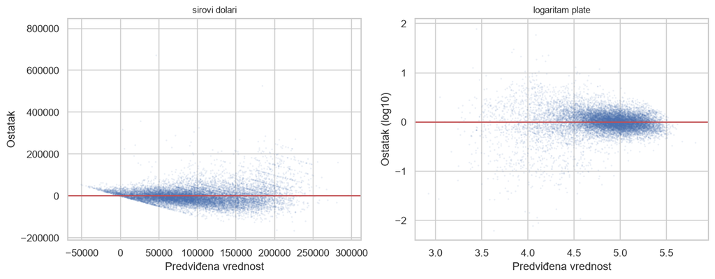

```
sirovi dolari — standardna devijacija ostatka po decilu predviđene vrednosti (USD):
  23,258  22,845  29,903  26,767  29,641  36,872  35,543  40,192  46,535  71,974
  prvi decil 23,258.292   poslednji 71,973.582   odnos poslednji/prvi 3.09
  bez prva dva decila: odnos najveći/najmanji 2.69

logaritam plate — standardna devijacija ostatka po decilu predviđene vrednosti (log10):
  0.483  0.321  0.208  0.177  0.152  0.146  0.141  0.140  0.134  0.139
  prvi decil 0.483   poslednji 0.139   odnos poslednji/prvi 0.29
  bez prva dva decila: odnos najveći/najmanji 1.55
```

```python
targets = {"sirovi dolari": train[TARGET].to_numpy(), "logaritam plate": y_train.to_numpy()}
spread = {}

fig, axes = plt.subplots(1, 2, figsize=(11, 4.4))
for ax, (label, target) in zip(axes, targets.items()):
    coefficients, _, _, _ = np.linalg.lstsq(full_design, target, rcond=None)
    fitted = full_design @ coefficients
    residual = target - fitted
    ax.scatter(fitted, residual, s=3, alpha=0.12, color="#4C72B0", linewidths=0)
    ax.axhline(0, color="#C44E52", linewidth=1.2)
    ax.set_title(label, fontsize=10)
    ax.set_xlabel("Predviđena vrednost")

    # Residual spread by decile of the fitted value: the same thing the picture
    # shows, as a number that can be compared.
    decile = pd.qcut(fitted, 10, labels=False)
    spread[label] = pd.Series(residual).groupby(decile).std(ddof=0)
    # In dollars a prediction can come out below zero; in the logarithm it
    # cannot, because the value is raised to a power to get back to dollars.
    lowest = fitted.min() if label == "sirovi dolari" else 10 ** fitted.min()
    negative = int((fitted < 0).sum()) if label == "sirovi dolari" else 0
    print(f"{label}: najniže predviđanje {lowest:>10,.0f} USD, "
          f"negativnih predviđanja {negative}")

axes[0].set_ylabel("Ostatak")
axes[1].set_ylabel("Ostatak (log10)")
plt.tight_layout()
plt.show()

for label, values in spread.items():
    unit = "USD" if label == "sirovi dolari" else "log10"
    print(f"{label} — standardna devijacija ostatka po decilu predviđene vrednosti ({unit}):")
    print("  " + "  ".join(f"{value:,.3f}" if unit == "log10" else f"{value:,.0f}"
                           for value in values))
    print(f"  prvi decil {values.iloc[0]:,.3f}   poslednji {values.iloc[-1]:,.3f}   "
          f"odnos poslednji/prvi {values.iloc[-1] / values.iloc[0]:.2f}")
    print(f"  bez prva dva decila: odnos najveći/najmanji "
          f"{values.iloc[2:].max() / values.iloc[2:].min():.2f}")
    print()
```

**Zapažanje:** Nijedan panel ne pokazuje ujednačen pojas.

Kod **sirovih dolara** rasipanje raste sa predviđenom vrednošću — standardna devijacija ostatka ide od **23.258** dolara u prvom decilu do **71.974** u poslednjem, dakle **3,09 puta** veća.

Kod **logaritma** je lepeza **obrnuta**: **0,483** u prvom decilu, **0,139** u poslednjem. Ali odnos prvog i poslednjeg ne opisuje ceo niz — po decilima ostatak ide **0,483, 0,321, 0,208, 0,177, 0,152, 0,146, 0,141, 0,140, 0,134, 0,139**, dakle od trećeg naviše je praktično ravan, sa odnosom **1,55**. Sav problem je u **prva dva decila**.

Levi panel pokazuje i nešto što se rasipanja ne tiče: predviđena vrednost ide **ispod nule**. Model na sirovim dolarima predviđa negativnu platu kod **419** ispitanika, najniže **−51.028** dolara. Model na logaritmu to ne može — najniže predviđa **838**.

**Tumačenje:** Odgovor je „da, ali ne do kraja", i znamo gde je granica. Logaritam je ispravio lepezu koja je u dolarima rasla sa nivoom plate, ali je napravio novu na dnu — kod ispitanika sa vrlo malim prijavljenim iznosima, koje smo svesno zadržali. U dolarima oni stoje zbijeni uz nulu; u logaritmu se razvlače ulevo.

**Logaritam zato ostaje**, i to iz dva razloga koja su oba upravo izmerena. Prvi: na osamdeset posto raspona rasipanje jeste ujednačeno, sa odnosom **1,55**, dok u dolarima nije ujednačeno nigde — tamo je odnos **3,09** i raste postepeno kroz sve decile. Drugi razlog sa homoskedastičnošću nema veze: model na sirovim dolarima predviđa **negativnu platu kod 419 ispitanika**, a to nije loša procena nego nemoguća vrednost. U logaritmu se ne može desiti, jer se u dolare vraća stepenovanjem, a `10^x` je uvek pozitivno.

Pretpostavka je, dakle, **narušena lokalno** — kod dvadeset posto najnižih predviđanja, a ne kroz ceo raspon. Gde tačno leže te greške, meri deveta sekcija.

### 3.3 Četiri dijagnostička grafika

Sa predavanja ide četvorka prikaza koja se standardno gleda zajedno — u R-u je daje `plot(model)`. Crtamo sva četiri, na modelu koji zaista koristimo, dakle na logaritmu plate, i zadržavamo imena pod kojima smo ih učili. Ovo je podsetnik šta koji od njih pokazuje:

| grafik | proverava | čita se |
| --- | --- | --- |
| **Residuals vs Fitted** | linearnost | vodoravan oblak → u redu; uočljiv obrazac → veza nije linearna |
| **Normal Q-Q** | normalnost ostatka | tačke na pravoj → u redu; odstupanje na krajevima → predugački repovi |
| **Scale-Location** | ujednačenost rasipanja | vodoravna linija → homoskedastičnost; levak → nije |
| **Residuals vs Leverage** | pojedinačne tačke koje vuku model | tačka daleko desno, uz velik ostatak → uticajna |

Poslednji panel uvodi pojam koji do sada nismo koristili. **Poluga** — na predavanjima *leverage*, u R-u `hatvalues()` — meri koliko je **kombinacija prediktora** jednog ispitanika neobična u odnosu na ostale. O njegovoj plati ne kaže ništa. Kreće se od nule do jedan, prosečna joj je uvek `p/n`, a granica sa predavanja je `2(p+1)/n`. Brojevima se bavi odeljak 3.4; ovde je dovoljno znati da desno na tom grafiku stoje ispitanici sa neobičnom kombinacijom odgovora.

Prvi panel ponavlja desni panel Grafika 3, ali sa dodatim **prosekom ostatka po decilu**, jer se iz oblaka od 14.608 tačaka sistematsko odstupanje ne vidi golim okom.

### Grafik 4 — četiri standardna dijagnostička prikaza

**Motivacija:** Svaki panel proverava drugu pretpostavku, pa se zajedno čitaju kao lista provera iz gornje tabele. Crtamo ih u istom rasporedu u kom ih daje `plot(model)`, da se mogu porediti sa onim što smo videli na vežbama.

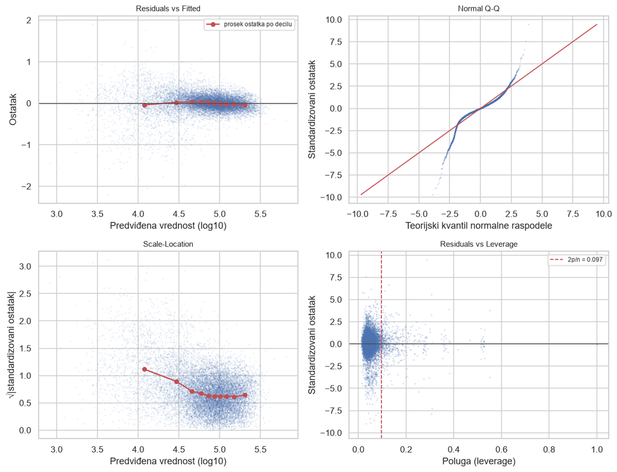

```
prosek ostatka po decilu, od najmanjeg predviđanja ka najvećem:
  -0.040  +0.024  +0.034  +0.030  +0.017  +0.004  -0.002  -0.018  -0.012  -0.038
  najveće odstupanje od nule: 0.040

√|standardizovani ostatak| po decilu:
  1.12  0.89  0.71  0.67  0.63  0.62  0.62  0.62  0.61  0.64

standardizovani ostatak: najmanji -9.71   najveći 9.45
  ispod −3: 246   iznad +3: 90

rasipanje: sd ostatka 0.4825 u najnižem decilu, 0.1385 u najvišem, odnos 3.48
           bez prva dva decila odnos 1.55
normalnost: asimetrija -1.088   spljoštenost +9.677   (kod normalne oba nula)
           ostatka izvan tri standardne devijacije 2.12%   (kod normalne 0,27%)
```

```python
residual = full_model.resid
fitted = full_model.fittedvalues
parameters = full_design.shape[1]

# Leverage from the QR factorisation: the diagonal of the hat matrix is the row
# norm of Q, which is far cheaper than forming the hat matrix itself.
orthogonal, _ = np.linalg.qr(full_design)
leverage = np.einsum("ij,ij->i", orthogonal, orthogonal)
sigma = np.sqrt(full_model.mse_resid)
standardized = residual / (sigma * np.sqrt(np.clip(1 - leverage, 1e-12, None)))

fig, axes = plt.subplots(2, 2, figsize=(11, 8.5))

ax = axes[0, 0]
ax.scatter(fitted, residual, s=3, alpha=0.12, color="#4C72B0", linewidths=0)
decile = pd.qcut(fitted, 10, labels=False)
centres = pd.Series(fitted).groupby(decile).median()
means = pd.Series(residual).groupby(decile).mean()
ax.plot(centres, means, marker="o", markersize=5, color="#C44E52", linewidth=1.6,
        label="prosek ostatka po decilu")
ax.axhline(0, color="#4C4C4C", linewidth=1)
ax.set_xlabel("Predviđena vrednost (log10)")
ax.set_ylabel("Ostatak")
ax.set_title("Residuals vs Fitted", fontsize=10)
ax.legend(fontsize=8)

ax = axes[0, 1]
(theoretical, ordered), _ = stats.probplot(standardized, dist="norm", fit=False), None
ax.scatter(theoretical, ordered, s=3, alpha=0.25, color="#4C72B0", linewidths=0)
limit = [min(theoretical.min(), ordered.min()), max(theoretical.max(), ordered.max())]
ax.plot(limit, limit, color="#C44E52", linewidth=1.2)
ax.set_xlabel("Teorijski kvantil normalne raspodele")
ax.set_ylabel("Standardizovani ostatak")
ax.set_title("Normal Q-Q", fontsize=10)

ax = axes[1, 0]
ax.scatter(fitted, np.sqrt(np.abs(standardized)), s=3, alpha=0.12,
           color="#4C72B0", linewidths=0)
root_means = pd.Series(np.sqrt(np.abs(standardized))).groupby(decile).mean()
ax.plot(centres, root_means, marker="o", markersize=5, color="#C44E52", linewidth=1.6)
ax.set_xlabel("Predviđena vrednost (log10)")
ax.set_ylabel("√|standardizovani ostatak|")
ax.set_title("Scale-Location", fontsize=10)

ax = axes[1, 1]
ax.scatter(leverage, standardized, s=4, alpha=0.2, color="#4C72B0", linewidths=0)
ax.axvline(2 * parameters / len(X_train), color="#C44E52", linestyle="--", linewidth=1.2,
           label=f"2p/n = {2 * parameters / len(X_train):.3f}")
ax.axhline(0, color="#4C4C4C", linewidth=1)
ax.set_xlabel("Poluga (leverage)")
ax.set_ylabel("Standardizovani ostatak")
ax.set_title("Residuals vs Leverage", fontsize=10)
ax.legend(fontsize=8)

plt.tight_layout()
plt.show()

print(f"prosek ostatka po decilu, od najmanjeg predviđanja ka najvećem:")
print("  " + "  ".join(f"{value:+.3f}" for value in means))
print(f"  najveće odstupanje od nule: {means.abs().max():.3f}")
print()
print(f"√|standardizovani ostatak| po decilu:")
print("  " + "  ".join(f"{value:.2f}" for value in root_means))
print()
print(f"standardizovani ostatak: najmanji {standardized.min():.2f}   "
      f"najveći {standardized.max():.2f}")
print(f"  ispod −3: {int((standardized < -3).sum())}   "
      f"iznad +3: {int((standardized > 3).sum())}")
print()
# Descriptive numbers for the two panels that show a problem, so the verdict
# does not rest on reading a picture.
by_decile = pd.Series(residual).groupby(decile).std(ddof=0)
print(f"rasipanje: sd ostatka {by_decile.iloc[0]:.4f} u najnižem decilu, "
      f"{by_decile.iloc[-1]:.4f} u najvišem, odnos {by_decile.iloc[0] / by_decile.iloc[-1]:.2f}")
print(f"           bez prva dva decila odnos "
      f"{by_decile.iloc[2:].max() / by_decile.iloc[2:].min():.2f}")
print(f"normalnost: asimetrija {float(stats.skew(residual)):+.3f}   "
      f"spljoštenost {float(stats.kurtosis(residual)):+.3f}   (kod normalne oba nula)")
print(f"           ostatka izvan tri standardne devijacije "
      f"{100 * np.mean(np.abs(residual) > 3 * sigma):.2f}%   (kod normalne 0,27%)")
```

**Zapažanje:** Četiri panela daju tri različita odgovora.

**Residuals vs Fitted — linearnost stoji.** Oblak je centriran oko nule kroz ceo raspon — prosek ostatka po decilima ne odstupa od nule više od **0,040**.

**Scale-Location — rasipanje nije ujednačeno.** Prosek korena standardizovanog ostatka pada sa **1,12** u prvom decilu na **0,64** u poslednjem, i pad je sistematski. Isti nalaz kao u 3.2: odnos **3,48** između dna i vrha, **1,55** bez prva dva decila.

**Normal Q-Q — ostatak nije normalan.** Oba repa odstupaju — standardizovani ostatak ide od **−9,71** do **+9,45**, dok bi kod normalne raspodele na 14.608 redova krajnosti bile oko ±4. Repovi su po dometu slični ali ne i po gustini: ispod −3 ima **246** ispitanika, iznad +3 samo **90**. Asimetrija je **−1,088**, spljoštenost **+9,677**, a ostatka izvan tri standardne devijacije je **2,12%** naspram 0,27% koliko bi dala normalna raspodela.

**Residuals vs Leverage.** Većina tačaka je pri niskoj poluzi, ali se vidi rep koji ide do jedinice, i tamošnje tačke imaju ostatak oko nule.

**Tumačenje:** Linearnost je u redu, i to nije bilo zagarantovano — u prethodnom notebook-u smo izmerili da veza broja izabranih stavki i plate nije prava linija, ali kod 707 kolona ostale imaju dovoljno slobode da to pokriju.

Druge dve pretpostavke su narušene i imaju isti uzrok: onaj levi rep. Praktična posledica je jedna i treba je zapisati: **p-vrednosti i intervali poverenja za pojedinačne koeficijente ovog modela nisu pouzdani.**

Interval poverenja je, sa predavanja, raspon `β̂ ± 2·SE(β̂)` za koji tvrdimo da sa 95% poverenja sadrži pravu vrednost koeficijenta; p-vrednost se računa iz iste standardne greške `SE`. A formula za `SE` izvedena je pod pretpostavkom da je rasipanje ostatka svuda isto i da je ostatak normalan — dakle pod tačno one dve pretpostavke koje smo upravo oborili. Sam koeficijent time nije pogrešan, ali raspon oko njega jeste, i ne znamo ni u kom smeru.

Predviđanja to ne kvari, jer se mere unakrsnom validacijom, koja se na te pretpostavke ne oslanja — ali u osmoj sekciji koeficijente treba čitati kao veličine, a ne kao rezultate testova.

Poslednji panel otvara pitanje koje sledeći odeljak razrešava brojevima.

### 3.4 Poluga i uticajne opservacije

Poslednji panel je pokazao tačke sa polugom blizu jedinice, i tu je lako pomešati tri različite stvari. Sa predavanja ih razdvajamo ovako:

| pojam | šta znači | čime se meri | granica sa predavanja |
| --- | --- | --- | --- |
| **netipična vrednost** | ispitanik čiju platu model promašuje | studentizovani ostatak | veći od 3 po apsolutnoj vrednosti |
| **visoka poluga** | ispitanik sa neobičnom **kombinacijom prediktora**, bez obzira na platu | poluga, `hatvalues` | veća od 2(p+1)/n |
| **uticajna opservacija** | ona čije bi izbacivanje pomerilo model | Cook-ova distanca | veća od 1 |

Tri mere iz treće kolone ukratko podsećamo, jer se odavde nadalje samo koriste. **Studentizovani ostatak** je ostatak podeljen sopstvenom standardnom greškom, i to izračunatom kao da je taj red izostavljen iz modela — dobija se broj koji se čita kao z-vrednost, pa granica 3 znači „tri standardne greške od nule". **Poluga** je udeo koji jedan red ima u sopstvenom predviđanju: ako je nula, predviđanje za njega dolazi isključivo od ostalih redova, ako je jedan, dolazi samo od njega. **Cook-ova distanca** spaja to dvoje u jedan broj — koliko bi se sva predviđanja pomerila da tog reda nema.

Razlika između poluge i uticaja je ono što se najlakše previdi, pa vredi reći svojim rečima. **Poluga** ne zna ništa o plati — ona meri samo koliko je ispitanikova kombinacija odgovora neobična u odnosu na ostale. Ispitanik može biti krajnje neobičan a da model ni ne pomeri, ako mu je plata baš onakva kakvu model za takvu kombinaciju i predviđa. **Uticaj** spaja to dvoje: neobična kombinacija **i** promašena plata.

Poluga ima i osobinu koju treba znati da bi se brojevi pročitali: prosečna poluga je uvek `p/n`, dakle kod nas oko 0,05, a najveća moguća je **1**. Poluga jednaka jedinici znači da model tog ispitanika predviđa **tačno**, sa ostatkom nula — ne zato što ga je razumeo, nego zato što mu je posvetio sopstveni parametar.

Jedna tehnička napomena: Cook-ova distanca u imeniocu ima `(1 − poluga)²`, pa kod poluge jednake jedinici deli nulom. Takve ispitanike izdvajamo posebno, jer su oni sami po sebi nalaz.

### Grafik 5 — kako je poluga raspoređena

**Motivacija:** Iz Grafika 4 se vidi da rep postoji, ali ne i koliko je gust — a to je razlika između „nekoliko neobičnih ispitanika" i „model se drži na malom broju ljudi". Crtamo raspodelu poluge, sa uspravnom osom u logaritmu, jer je inače vrh oko prosečne vrednosti toliko visok da se rep ne vidi.

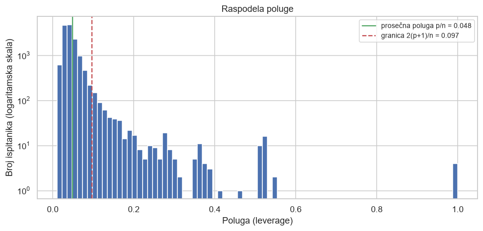

```
prosečna poluga p/n                             0.0485
granica 2(p+1)/n                                0.0969
najveća poluga                                  1.0000

netipičnih (|studentizovani ostatak| > 3)      336
sa visokom polugom (> 2(p+1)/n)                612
sa polugom praktično jednakom 1                  4

Cook-ova distanca, bez tih 4:
  najveća 0.0506   preko granice od 1: 0

tri najuticajnija ispitanika:
  plata   220,000   predviđeno     2,783   poluga 0.286   Cook 0.0506
  plata        30   predviđeno     1,082   poluga 0.307   Cook 0.0387
  plata        30   predviđeno       838   poluga 0.309   Cook 0.0338

ispitanika sa platom ispod 1.000 USD: 89   od njih netipičnih: 80
ispitanici koje model predviđa tačno (poluga ~ 1):
  plata    76,000   ostatak +2.40e-14
  plata    83,200   ostatak +1.95e-14
  plata    73,089   ostatak +1.42e-14
  plata    80,000   ostatak +1.95e-14
```

```python
average_leverage = parameters / len(X_train)
limit_leverage = 2 * parameters / len(X_train)
exactly_fitted = np.where(leverage > 0.999)[0]

# The externally studentized residual the lectures use for outliers: the same
# standardized residual, rescaled as if the row had been left out of the fit.
degrees = len(X_train) - parameters
studentized = standardized * np.sqrt((degrees - 1) / (degrees - standardized ** 2))

fig, ax = plt.subplots(figsize=(9, 4.4))
ax.hist(leverage, bins=80, color="#4C72B0")
ax.set_yscale("log")
ax.axvline(average_leverage, color="#55A868", linewidth=1.5,
           label=f"prosečna poluga p/n = {average_leverage:.3f}")
ax.axvline(limit_leverage, color="#C44E52", linestyle="--", linewidth=1.5,
           label=f"granica 2(p+1)/n = {limit_leverage:.3f}")
ax.set_xlabel("Poluga (leverage)")
ax.set_ylabel("Broj ispitanika (logaritamska skala)")
ax.set_title("Raspodela poluge")
ax.legend(fontsize=9)
plt.tight_layout()
plt.show()

print(f"{'prosečna poluga p/n':<44} {average_leverage:>9.4f}")
print(f"{'granica 2(p+1)/n':<44} {limit_leverage:>9.4f}")
print(f"{'najveća poluga':<44} {leverage.max():>9.4f}")
print()
print(f"{'netipičnih (|studentizovani ostatak| > 3)':<44} "
      f"{int((np.abs(studentized) > 3).sum()):>5}")
print(f"{'sa visokom polugom (> 2(p+1)/n)':<44} "
      f"{int((leverage > limit_leverage).sum()):>5}")
print(f"{'sa polugom praktično jednakom 1':<44} {len(exactly_fitted):>5}")
print()

# Cook's distance, with the exactly fitted rows left out: for them the formula
# divides by zero and the result would be an artefact of that.
usable = leverage <= 0.999
variance = float(residual[usable] @ residual[usable]) / (usable.sum() - parameters)
cooks = np.full(len(X_train), np.nan)
cooks[usable] = ((residual[usable] ** 2 / (parameters * variance))
                 * (leverage[usable] / (1 - leverage[usable]) ** 2))

print(f"Cook-ova distanca, bez tih {len(exactly_fitted)}:")
print(f"  najveća {np.nanmax(cooks):.4f}   preko granice od 1: {int(np.nansum(cooks > 1))}")
print()
print("tri najuticajnija ispitanika:")
for row in np.argsort(np.nan_to_num(cooks))[-3:][::-1]:
    print(f"  plata {train[TARGET].iloc[row]:>9,.0f}   predviđeno {10 ** fitted[row]:>9,.0f}   "
          f"poluga {leverage[row]:.3f}   Cook {cooks[row]:.4f}")
print()
low_pay = train[TARGET].to_numpy() < 1000
print(f"ispitanika sa platom ispod 1.000 USD: {int(low_pay.sum())}   "
      f"od njih netipičnih: {int((np.abs(studentized[low_pay]) > 3).sum())}")
print("ispitanici koje model predviđa tačno (poluga ~ 1):")
for row in exactly_fitted:
    print(f"  plata {train[TARGET].iloc[row]:>9,.0f}   ostatak {residual[row]:+.2e}")
```

Brojevi razdvajaju tri pojma:

- **netipičnih** vrednosti, sa studentizovanim ostatkom preko 3, ima **336**;
- **visoku polugu**, preko granice od **0,097**, ima **612** ispitanika, pri prosečnoj poluzi **0,048**;
- **polugu praktično jednaku jedinici** imaju **četiri** ispitanika, sa ostatkom reda 10⁻¹⁴.

**Uticajnih opservacija nema.** Kad se ta četiri izuzmu, najveća Cook-ova distanca je **0,0506**, dakle dvadeset puta manja od granice, i nijedan ispitanik je ne prelazi. Najuticajniji je onaj sa platom **220.000** dolara kome model predviđa **2.783**, pa dva sa prijavljenih **30** dolara.

Od **89** ispitanika sa platom ispod hiljadu dolara, **80** su netipične vrednosti.

**Tumačenje:** Ovo je bolja vest nego što je Grafik 4 sugerisao, uz jedan izuzetak.

Nijedan pojedinačni ispitanik ne vuče model — pri 14.608 redova jedan red i ne može mnogo da pomeri procenu, pa je Cook-ova distanca svuda mala. To znači da ne treba ništa izbacivati, i da bi izbacivanje bilo pogrešno: čišćenje je završeno u prethodnom notebook-u, a vraćanje na njega ovde značilo bi da podatke prilagođavamo modelu.

Ispitanici sa vrlo malim iznosima izdvajaju se i ovde, treći put u sekciji: oni prave obrnutu lepezu u 3.2, gušći levi rep u 3.3, a sada se pokazuje da su gotovo svi i netipične vrednosti. To je ograničenje uzorka i ide u zaključak.

### Šta sekcija ostavlja sledećoj

**Obična regresija sa 707 nezavisnih kolona daje unakrsni R² od 0,6769**, uz tipičan promašaj 24,8% i predviđanje u okviru dvostruko kod 87,5% ispitanika. Letvicu iz 2.5 prelazi za **+0,0101**.

Četiri nalaza se prenose dalje:

- **doprinos prethodnog notebook-a je skroman na podacima koje model nije video** — +0,0101, a razlika trening i unakrsnog R² (0,0440) skoro se poklapa sa 0,0471 koliko je u 1.5 izmereno kao prilagođavanje šumu;
- **logaritam je bio pravi izbor, ali ne rešava sve.** Na osamdeset posto raspona odnos rasipanja je 1,55, a na dnu 3,48. Uz to isključuje negativna predviđanja, kojih model u dolarima ima 419;
- **od tri pretpostavke jedna stoji.** Linearnost je u redu, rasipanje i normalnost nisu, pa se p-vrednosti pojedinačnih koeficijenata ne smeju čitati kao pouzdane;
- **uticajnih opservacija nema** (najveća Cook-ova distanca 0,0506), ali **četiri ispitanika model uči napamet**, sa polugom jednakom jedinici.

Sledeća sekcija uvodi Ridge regresiju: isti model, ali sa kaznom za veličinu koeficijenata.

## 4. Ridge regresija

Sekcija 1.5 je izmerila da model sa 707 kolona ima previše slobode, a sekcija 3 je pokazala kako to izgleda: četiri ispitanika koje predviđa napamet i razliku od 0,0440 između trening i unakrsnog R². Ridge je prvi odgovor na to sa predavanja.

Ideja je da se uz sumu kvadrata ostataka minimizuje i **kazna za veličinu koeficijenata**, `λ·Σβ²`. Model time ne dobija manje kolona nego **manje slobode u svakoj**: koeficijenti se skupljaju ka nuli, ali nijedan ne postaje tačno nula. Kod korelisanih prediktora — a mi ih imamo, 96 dummy kolona sa VIF-om preko 10 — to stabilizuje ocene, jer model više ne može da jednoj koloni da veliki pozitivan a drugoj veliki negativan koeficijent.

### 4.1 Izbor λ

Dve stvari određuju kako se to izvodi:

- **standardizacija ide unutar unakrsne validacije**, kako smo se dogovorili u 1.4. Kazna se odnosi na veličinu koeficijenata, pa bi kolona merena u drugoj jedinici bila drugačije kažnjena; a skaliranje mora da se računa na delu za učenje, ne na celom skupu;
- **λ ne biramo nego ga izvodimo** — probamo mrežu vrednosti i uzimamo onu sa najboljom unakrsnom greškom. Slobodan član se ne kažnjava.

```python
from sklearn.linear_model import Ridge, lasso_path
from sklearn.preprocessing import StandardScaler

# Regularized models get the design without the column of ones: they fit their
# own intercept and, unlike the other coefficients, do not penalise it.
regularized_design = X_train[independent].to_numpy(dtype=float)


def scaled_fit_predict(make_model):
    """Standardize on the fold being learned from, then fit and predict.

    Doing it this way rather than scaling everything up front is what keeps a
    fold from being scaled with information out of the part it is tested on.
    """
    def fit_predict(design_fit, target_fit, design_eval):
        scaler = StandardScaler().fit(design_fit)
        model = make_model().fit(scaler.transform(design_fit), target_fit)
        return model.predict(scaler.transform(design_eval))
    return fit_predict


# A wide grid, so the best value is found inside it rather than at an edge.
RIDGE_ALPHAS = np.logspace(3, -2, 30)

ridge_scores = []
for value in RIDGE_ALPHAS:
    predicted = cross_validated(regularized_design, y_train,
                                scaled_fit_predict(lambda a=value: Ridge(alpha=a)))
    ridge_scores.append(metrics(y_train, predicted))

ridge_table = pd.DataFrame(ridge_scores, index=RIDGE_ALPHAS)
best_alpha = float(ridge_table["R2"].idxmax())
ridge_cv = cross_validated(regularized_design, y_train,
                           scaled_fit_predict(lambda: Ridge(alpha=best_alpha)))

print("unakrsni R² za nekoliko vrednosti λ:")
for value in RIDGE_ALPHAS[::4]:
    print(f"  λ = {value:>9.4g}   R² = {ridge_table.loc[value, 'R2']:.4f}")
print()
print(f"najbolja λ: {best_alpha:.4g}   unakrsni R² {ridge_table['R2'].max():.4f}")
print(f"obična regresija iz 3.1:        {reference.loc['sve kolone, regresija', 'R2']:.4f}")
print(f"razlika:                        "
      f"{ridge_table['R2'].max() - reference.loc['sve kolone, regresija', 'R2']:+.4f}")
print(f"raspon R² kroz celu mrežu λ:    {ridge_table['R2'].min():.4f} do {ridge_table['R2'].max():.4f}")
print()

# How much the penalty actually shrank things, against the unpenalised fit.
scaler_all = StandardScaler().fit(regularized_design)
scaled_all = scaler_all.transform(regularized_design)
ridge_full = Ridge(alpha=best_alpha).fit(scaled_all, y_train)
ols_scaled = np.linalg.lstsq(np.column_stack([np.ones(len(scaled_all)), scaled_all]),
                             y_train.to_numpy(), rcond=None)[0][1:]
print(f"{'':<24} {'Ridge':>10} {'bez kazne':>10}")
print(f"{'najveći |koeficijent|':<24} {np.abs(ridge_full.coef_).max():>10.4f} "
      f"{np.abs(ols_scaled).max():>10.4f}")
print(f"{'suma kvadrata koeficijenata':<24} {(ridge_full.coef_ ** 2).sum():>10.4f} "
      f"{(ols_scaled ** 2).sum():>10.4f}")
print(f"{'koeficijenata tačno nula':<24} {int((ridge_full.coef_ == 0).sum()):>10} "
      f"{int((ols_scaled == 0).sum()):>10}")
print()

# Which columns the penalty actually works on: the claim above is about
# correlated predictors, and it is checkable only if they are named.
shrinkage = pd.DataFrame({"kolona": independent, "bez_kazne": ols_scaled,
                          "Ridge": ridge_full.coef_})
shrinkage["razlika"] = shrinkage["bez_kazne"].abs() - shrinkage["Ridge"].abs()
largest = shrinkage.reindex(
    shrinkage["razlika"].abs().sort_values(ascending=False).index).head(10)
print("deset kolona koje je kazna najviše promenila:")
print(largest.to_string(index=False, float_format=lambda v: f"{v:+.4f}"))

reference.loc["Ridge"] = pd.Series(metrics(y_train, ridge_cv))
```

```
unakrsni R² za nekoliko vrednosti λ:
  λ =      1000   R² = 0.6795
  λ =     204.3   R² = 0.6791
  λ =     41.75   R² = 0.6778
  λ =     8.532   R² = 0.6772
  λ =     1.743   R² = 0.6771
  λ =    0.3562   R² = 0.6770
  λ =   0.07279   R² = 0.6769
  λ =   0.01487   R² = 0.6769

najbolja λ: 672.3   unakrsni R² 0.6798
obična regresija iz 3.1:        0.6769
razlika:                        +0.0029
raspon R² kroz celu mrežu λ:    0.6769 do 0.6798
```

```
                              Ridge  bez kazne
najveći |koeficijent|        0.1005     0.1565
suma kvadrata koeficijenata     0.0656     0.1576
koeficijenata tačno nula          0          0

deset kolona koje je kazna najviše promenila:
                            kolona  bez_kazne   Ridge  razlika
        Currency_EUR European Euro    +0.1565 +0.0273  +0.1292
 Currency_USD United States dollar    +0.1266 +0.0313  +0.0954
       Currency_GBP Pound sterling    +0.0814 +0.0187  +0.0627
  Country_United States of America    +0.1561 +0.1005  +0.0557
         Currency_INR Indian rupee    -0.0002 -0.0439  -0.0437
      Currency_CAD Canadian dollar    +0.0519 +0.0117  +0.0401
        Currency_SEK Swedish krona    +0.0417 +0.0032  +0.0385
         Currency_DKK Danish krone    +0.0460 +0.0112  +0.0348
      Currency_VND Vietnamese dong    +0.0427 +0.0093  +0.0334
SODuration_Between 10 and 15 years    +0.0711 +0.0383  +0.0328
```

**Zapažanje:** Ridge pobeđuje običnu regresiju, ali malo. Najbolja λ je **672,3**, sa unakrsnim R² od **0,6798** naspram **0,6769** — razlika **+0,0029**.

Zanimljivije je koliko je kriva **ravna**: kroz celu mrežu λ, od 0,01 do 1.000, unakrsni R² se kreće samo od **0,6769 do 0,6798**. Dakle nijedna vrednost kazne ne pravi veliku razliku, ni na bolje ni na gore.

Kazna pri tome jasno radi svoj posao: najveći koeficijent pada sa **0,1565** na **0,1005**, a suma kvadrata sa **0,1576** na **0,0656**, dakle na manje od polovine. Nijedan koeficijent nije postao tačno nula, što je i očekivano — Ridge to po konstrukciji ne radi.

Jedan red ide u suprotnom smeru: `Currency_INR Indian rupee` bez kazne ima koeficijent **−0,0002**, dakle praktično nulu, a sa kaznom **−0,0439**.

**Tumačenje:** Rezultat je koristan i kad je mali, jer kaže nešto o tome gde je problem.

Prvo, tabela je kolinearnost uhvaćena na delu. Valuta i zemlja nose istu vrstu podatka — na kom tržištu ispitanik zarađuje — pa regresija bez kazne sme da najveći deo tog efekta pripiše jednoj koloni a drugoj skoro ništa. Tako je indijskoj rupiji dala nulu, a evru najveći koeficijent u celom modelu. Ridge tu slobodu oduzima, jer kažnjava **zbir kvadrata**, a on je pri istom ukupnom efektu najmanji kad je efekat **razdeljen** na više kolona. Otud se veliki koeficijenti spuštaju, a onaj koji je bio na nuli podiže.

Drugo, to što uz sve to Ridge dobija samo +0,0029 znači da **naš model ne gubi zbog velikih koeficijenata** — kolinearnost među dummy kolonama, koju smo merili u prethodnom notebook-u, kvari čitljivost koeficijenata ali ne i predviđanja. To se sa predavanja i očekuje, a sada je izmereno na našim podacima.

Ono što Ridge ne rešava je **broj** kolona: model i dalje koristi svih 707, samo sa manjim koeficijentima. Ako je pravi problem to što stotine kolona ne nose ništa, treba nam postupak koji ume da ih izbaci — i to je Lasso.

### Grafik 6 — šta kazna radi sa greškom i sa koeficijentima

**Motivacija:** Iz jedne najbolje vrednosti λ ne vidi se oblik. Zanima nas da li greška ima jasan minimum ili je ravna, i koliko se koeficijenti skupljaju duž istog raspona — jer to dvoje zajedno pokazuje da li je kazna uopšte ono što ovom modelu treba. Crtamo oba u dva panela, sa λ na logaritamskoj osi, jer se mreža i pravi logaritamski.

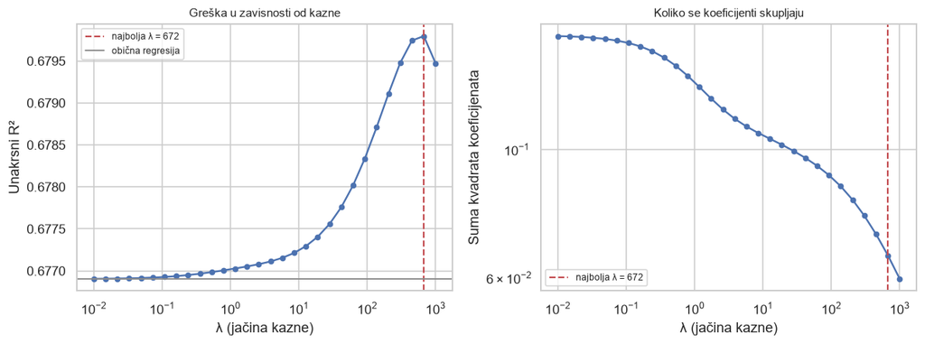

```
unakrsni R²: najmanji 0.6769 pri λ = 0.01, najveći 0.6798 pri λ = 672.3
suma kvadrata koeficijenata: 0.1571 pri najmanjoj λ, 0.0598 pri najvećoj
pri najboljoj λ iznosi 0.0656
```

```python
sizes = []
for value in RIDGE_ALPHAS:
    fitted_ridge = Ridge(alpha=value).fit(scaled_all, y_train)
    sizes.append(float((fitted_ridge.coef_ ** 2).sum()))

fig, axes = plt.subplots(1, 2, figsize=(11, 4.2))

ax = axes[0]
ax.plot(RIDGE_ALPHAS, ridge_table["R2"], marker="o", markersize=4, color="#4C72B0")
ax.axvline(best_alpha, color="#C44E52", linestyle="--", linewidth=1.4,
           label=f"najbolja λ = {best_alpha:.0f}")
ax.axhline(reference.loc["sve kolone, regresija", "R2"], color="#8C8C8C",
           linewidth=1.2, label="obična regresija")
ax.set_xscale("log")
ax.set_xlabel("λ (jačina kazne)")
ax.set_ylabel("Unakrsni R²")
ax.set_title("Greška u zavisnosti od kazne", fontsize=10)
ax.legend(fontsize=8)

ax = axes[1]
ax.plot(RIDGE_ALPHAS, sizes, marker="o", markersize=4, color="#4C72B0")
ax.axvline(best_alpha, color="#C44E52", linestyle="--", linewidth=1.4,
           label=f"najbolja λ = {best_alpha:.0f}")
ax.set_xscale("log")
ax.set_yscale("log")
ax.set_xlabel("λ (jačina kazne)")
ax.set_ylabel("Suma kvadrata koeficijenata")
ax.set_title("Koliko se koeficijenti skupljaju", fontsize=10)
ax.legend(fontsize=8)

plt.tight_layout()
plt.show()

print(f"unakrsni R²: najmanji {ridge_table['R2'].min():.4f} pri λ = {ridge_table['R2'].idxmin():.4g}, "
      f"najveći {ridge_table['R2'].max():.4f} pri λ = {best_alpha:.4g}")
print(f"suma kvadrata koeficijenata: {max(sizes):.4f} pri najmanjoj λ, {min(sizes):.4f} pri najvećoj")
print(f"pri najboljoj λ iznosi {sizes[int(np.argmin(np.abs(RIDGE_ALPHAS - best_alpha)))]:.4f}")
```

**Zapažanje:** Levi panel nema izražen minimum — kriva je gotovo vodoravna, sa vrhom oko λ = 672 i padom prema najmanjim vrednostima kazne koji iznosi svega tri hiljadita dela. Siva linija, koja označava običnu regresiju, praktično se poklapa sa levim krajem krive, što je i tačno: pri λ blizu nule Ridge se svodi na običnu regresiju.

Desni panel se menja više: suma kvadrata koeficijenata pada sa **0,1571** pri najslabijoj kazni na **0,0598** pri najjačoj, dakle **2,6 puta** duž istog raspona λ. Pri najboljoj λ iznosi **0,0656**.

**Tumačenje:** Dva panela zajedno kažu ono što jedan ne bi. Kazna menja koeficijente osetno više nego što menja grešku: suma kvadrata pada na manje od polovine, a unakrsni R² se pomera samo u trećoj decimali. Model, dakle, nije bio zavistan od velikih koeficijenata — mogu se prepoloviti bez gubitka, ali se time i ne dobija skoro ništa.

To je i praktičan zaključak za rad: Ridge ostaje u poređenju modela kao ozbiljna mogućnost, ali od njega ne treba očekivati preokret. Ako preokret postoji, treba ga tražiti u tome koje se kolone izbacuju, ne u tome koliko su koeficijenti veliki.

### Šta sekcija ostavlja sledećoj

**Ridge sa λ = 672,3 daje unakrsni R² 0,6798**, naspram 0,6769 obične regresije — dakle **+0,0029**.

Dva nalaza:

- **kriva greške je ravna.** Kroz raspon λ od 0,01 do 1.000 unakrsni R² se menja samo u trećoj decimali, pa izbor λ ovde nije osetljiv;
- **kazna radi, ali na pogrešnom problemu.** Suma kvadrata koeficijenata pada na manje od polovine (0,1571 na 0,0598, dakle 2,6 puta) bez gubitka u grešci, a najviše se skupljaju dummy kolone za valute, koje nose istu informaciju kao zemlja. Veliki koeficijenti, dakle, nisu bili to što modelu šteti.

Sledeća sekcija menja vrstu kazne: Lasso kažnjava sumu **apsolutnih** vrednosti, što neke koeficijente spušta tačno na nulu i time ujedno radi izbor promenljivih.

## 5. Lasso regresija

Lasso je ista ideja kao Ridge sa jednom izmenom: kažnjava se `λ·Σ|β|` umesto `λ·Σβ²`. Posledica te izmene nije mala. Kod apsolutne vrednosti optimum često pada tačno na nulu, pa Lasso pojedine koeficijente **ukine**, a ne samo smanji. Time istovremeno radi dve stvari — regularizuje model i **bira promenljive**.

Za nas je to drugo važnije od prvog. Iz prethodnog notebook-a nosimo 352 kolone koje smo sami napravili i otvorenu stavku da „formalna selekcija tek treba da odluči šta ostaje". Lasso je upravo taj postupak, i odgovor na to pitanje daje sam, bez da mu mi kažemo šta da zadrži.

### 5.1 Izbor λ i koliko kolona ostaje

λ se bira isto kao kod Ridge-a, unakrsnom validacijom nad mrežom vrednosti, uz standardizaciju unutar svakog dela.

```python
# The path is computed with a warm start from the previous value of lambda, which
# is why the whole grid costs about as much as one fit from cold.
LASSO_ALPHAS = np.logspace(-1, -3.5, 30)


def lasso_out_of_fold(design, target, alphas, folds=FOLDS, seed=SEED):
    """Out-of-fold predictions for every lambda at once.

    lasso_path fits no intercept, so the target is centred on the fold being
    learned from and the centre is added back to the prediction.
    """
    target = np.asarray(target, dtype=float)
    predictions = np.empty((len(alphas), len(target)))
    splitter = KFold(n_splits=folds, shuffle=True, random_state=seed)
    for fit_rows, eval_rows in splitter.split(design):
        scaler = StandardScaler().fit(design[fit_rows])
        centre = float(target[fit_rows].mean())
        used, coefficients, _ = lasso_path(scaler.transform(design[fit_rows]),
                                           target[fit_rows] - centre,
                                           alphas=alphas, max_iter=3000, tol=1e-3)
        assert np.allclose(used, alphas), "lasso_path je promenio poredak λ"
        predictions[:, eval_rows] = (scaler.transform(design[eval_rows])
                                     @ coefficients + centre).T
    return predictions


lasso_predictions = lasso_out_of_fold(regularized_design, y_train, LASSO_ALPHAS)
lasso_table = pd.DataFrame([metrics(y_train, row) for row in lasso_predictions],
                           index=LASSO_ALPHAS)
best_lasso = float(lasso_table["R2"].idxmax())

# The same path on the whole training set, to see which columns survive.
_, lasso_coefficients, _ = lasso_path(scaled_all, y_train - y_train.mean(),
                                      alphas=LASSO_ALPHAS, max_iter=5000, tol=1e-4)
nonzero = (lasso_coefficients != 0).sum(axis=0)
chosen = int(np.argmin(np.abs(LASSO_ALPHAS - best_lasso)))

print(f"{'λ':>9} {'unakrsni R²':>13} {'kolona u modelu':>16}")
for position in range(0, len(LASSO_ALPHAS), 3):
    print(f"{LASSO_ALPHAS[position]:>9.5f} {lasso_table['R2'].iloc[position]:>13.4f} "
          f"{nonzero[position]:>16}")
print()
print(f"najbolja λ: {best_lasso:.5f}   unakrsni R² {lasso_table['R2'].max():.4f}")
print(f"kolona sa koeficijentom različitim od nule: {nonzero[chosen]} od {len(independent)}")
print(f"kolona koje je Lasso ukinuo:                {len(independent) - nonzero[chosen]}")
print()
# The two ends of the grid, which is where the shape of the curve shows.
print(f"pri najslabijoj kazni: {nonzero[-1]} kolona, unakrsni R² "
      f"{lasso_table['R2'].iloc[-1]:.4f}")
print(f"pri najjačoj kazni:    {nonzero[0]} kolona, unakrsni R² "
      f"{lasso_table['R2'].iloc[0]:.4f}")
print()
for name, value in [("obična regresija", reference.loc["sve kolone, regresija", "R2"]),
                    ("Ridge", reference.loc["Ridge", "R2"]),
                    ("Lasso", lasso_table["R2"].max())]:
    print(f"  {name:<18} {value:.4f}")
print(f"  Lasso preko obične regresije: "
      f"{lasso_table['R2'].max() - reference.loc['sve kolone, regresija', 'R2']:+.4f}")
print(f"  Lasso preko Ridge-a:          "
      f"{lasso_table['R2'].max() - reference.loc['Ridge', 'R2']:+.4f}")

reference.loc["Lasso"] = pd.Series(metrics(y_train, lasso_predictions[chosen]))
```

```
        λ   unakrsni R²  kolona u modelu
  0.10000        0.2102                5
  0.05513        0.3611               16
  0.03039        0.5135               45
  0.01675        0.6056               81
  0.00924        0.6523              145
  0.00509        0.6737              220
  0.00281        0.6824              320
  0.00155        0.6845              423
  0.00085        0.6833              517
  0.00047        0.6819              589

najbolja λ: 0.00155   unakrsni R² 0.6845
kolona sa koeficijentom različitim od nule: 423 od 707
kolona koje je Lasso ukinuo:                284

pri najslabijoj kazni: 617 kolona, unakrsni R² 0.6811
pri najjačoj kazni:    5 kolona, unakrsni R² 0.2102

  obična regresija   0.6769
  Ridge              0.6798
  Lasso              0.6845
  Lasso preko obične regresije: +0.0076
  Lasso preko Ridge-a:          +0.0047
```

**Zapažanje:** Lasso daje najbolji rezultat do sada. Najbolja λ je **0,00155**, sa unakrsnim R² od **0,6845** — naspram 0,6798 kod Ridge-a i 0,6769 kod obične regresije.

Pri toj λ model koristi **423 od 707 kolona**, dakle **284 koeficijenta je spustio tačno na nulu**.

Tabela pokazuje i kako to izgleda duž mreže. Pri λ = 0,1 model ima svega **5** kolona i R² **0,2102**; pri λ = 0,00924 ima **145** kolona i **0,6523**; pri najmanjoj λ ima **617** kolona i R² koji ponovo **pada**, na 0,6811.

**Tumačenje:** Ovo je prvi rezultat u notebook-u koji je i bolji i manji.

Lasso dobija više od Ridge-a, a koristi četrdeset posto manje kolona. To potvrđuje ono što je Ridge samo nagovestio: modelu nije štetila veličina koeficijenata nego **broj kolona koje ne nose ništa**. Kad se one uklone, greška padne.

To što R² pri najmanjim λ ponovo pada je pri tome dokaz da postupak radi. Sa 617 kolona model se vraća ka onome što je obična regresija imala — dakle ka prilagođavanju šumu izmerenom u 1.5 — pa unakrsna greška raste. Minimum na 423 kolone nije, dakle, kompromis nego mesto gde se dodavanje kolona prestaje isplaćivati.

Time je odgovorena i otvorena stavka iz prethodnog notebook-a: **formalna selekcija je obavljena, i njen odgovor je 423 od 707 kolona.** Koje su to kolone, gleda odeljak 5.2.

### Grafik 7 — greška i broj kolona duž istog raspona λ

**Motivacija:** Kod Ridge-a je kriva greške bila ravna, pa je izbor λ bio nevažan. Ovde nije očigledno da li je tako, a uz to nas zanima i drugo pitanje koje Ridge nije mogao da postavi: kako broj zadržanih kolona zavisi od kazne, i da li minimum greške pada tamo gde model postaje mali ili tamo gde je još uvek velik.

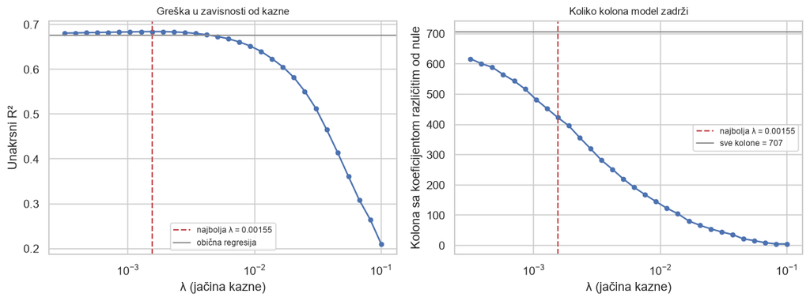

```
unakrsni R² duž mreže: od 0.2102 do 0.6845
broj zadržanih kolona: od 5 do 617
pri najboljoj λ: R² 0.6845, kolona 423
pri najmanjoj λ: R² 0.6811, kolona 617

sa upola manje kolona (357): R² 0.6837, gubitak -0.0008
```

```python
fig, axes = plt.subplots(1, 2, figsize=(11, 4.2))

ax = axes[0]
ax.plot(LASSO_ALPHAS, lasso_table["R2"], marker="o", markersize=4, color="#4C72B0")
ax.axvline(best_lasso, color="#C44E52", linestyle="--", linewidth=1.4,
           label=f"najbolja λ = {best_lasso:.5f}")
ax.axhline(reference.loc["sve kolone, regresija", "R2"], color="#8C8C8C", linewidth=1.2,
           label="obična regresija")
ax.set_xscale("log")
ax.set_xlabel("λ (jačina kazne)")
ax.set_ylabel("Unakrsni R²")
ax.set_title("Greška u zavisnosti od kazne", fontsize=10)
ax.legend(fontsize=8)

ax = axes[1]
ax.plot(LASSO_ALPHAS, nonzero, marker="o", markersize=4, color="#4C72B0")
ax.axvline(best_lasso, color="#C44E52", linestyle="--", linewidth=1.4,
           label=f"najbolja λ = {best_lasso:.5f}")
ax.axhline(len(independent), color="#8C8C8C", linewidth=1.2,
           label=f"sve kolone = {len(independent)}")
ax.set_xscale("log")
ax.set_xlabel("λ (jačina kazne)")
ax.set_ylabel("Kolona sa koeficijentom različitim od nule")
ax.set_title("Koliko kolona model zadrži", fontsize=10)
ax.legend(fontsize=8)

plt.tight_layout()
plt.show()

print(f"unakrsni R² duž mreže: od {lasso_table['R2'].min():.4f} do {lasso_table['R2'].max():.4f}")
print(f"broj zadržanih kolona: od {nonzero.min()} do {nonzero.max()}")
print(f"pri najboljoj λ: R² {lasso_table['R2'].max():.4f}, kolona {nonzero[chosen]}")
print(f"pri najmanjoj λ: R² {lasso_table['R2'].iloc[-1]:.4f}, kolona {nonzero[-1]}")
print()
half = int(np.argmin(np.abs(nonzero - len(independent) // 2)))
print(f"sa upola manje kolona ({nonzero[half]}): R² {lasso_table['R2'].iloc[half]:.4f}, "
      f"gubitak {lasso_table['R2'].iloc[half] - lasso_table['R2'].max():+.4f}")
```

**Zapažanje:** Za razliku od Ridge-a, ovde kriva greške **ima oblik**. Raste od 0,2102 pri najjačoj kazni do vrha na **0,6845**, pa se blago spušta na **0,6811** pri najslabijoj. Broj zadržanih kolona istovremeno raste od **5** do **617**.

Vrh greške pada tamo gde model ima 423 kolone — dakle ne na kraju gde ih je najviše, ni blizu mesta gde ih je malo.

Poslednji red ispisa daje i cenu strožeg izbora: sa **357** kolona, dakle upola manje od svih, unakrsni R² je **0,6837**, samo **0,0008** ispod najboljeg.

**Tumačenje:** Oblik krive je ono zbog čega Lasso ovde radi a Ridge nije.

Levi deo krive pokazuje da model kojem se odseče previše kolona zaista gubi — pri pet kolona objašnjava samo pete deo varijanse. Desni deo pokazuje da model kojem se dozvoli previše kolona **takođe** gubi, i to je ono što obična regresija nije umela da izbegne. Između njih postoji jasno najbolje mesto, i unakrsna validacija ga nalazi.

Zadnji broj je praktično najupotrebljiviji: **357 kolona umesto 707 košta 0,0008 unakrsnog R².** Postoji, dakle, i osetno manji model koji radi skoro isto, pa bi se mogao uzeti on ako bi čitljivost bila važnija od poslednje decimale. Time se bavi sedma sekcija, gde se selekcija ocenjuje merilima sa predavanja.

### 5.2 Koje grupe promenljivih Lasso zadržava

Do sada smo brojali kolone. Pitanje koje nas zapravo zanima je **koje** su preživele, i to ne pojedinačno nego po grupama. Grupu prepoznajemo po prefiksu imena kolone — `Chose_`, `Count_`, `KeptShare_`, `NotAnswered_` su prefiksi koje smo sami uveli u prethodnom notebook-u, a `Country_`, `Currency_` i ostali dolaze iz enkodiranja anketnih pitanja. Uz svaku od naših grupa u tabeli stoji i hipoteza iz koje je nastala, da se rezultat može pročitati naspram onoga što je tamo tvrđeno.

Ovo je najstroža provera koju feature engineering može da dobije: nismo mi odlučili šta ostaje, nego postupak koji jedino gleda unakrsnu grešku.

```python
survived = set(np.array(independent)[lasso_coefficients[:, chosen] != 0])

# The groups the previous notebook built, each with the hypothesis it came
# from, so the count can be read against what was claimed there.
FAMILIES = [
    ("Chose_", "Chose_ — pojedinačne stavke (Hip. 7)"),
    ("Count_", "Count_ — broj izabranih stavki (Hip. 6)"),
    ("KeptShare_", "KeptShare_ — odnos zadržanog (Hip. 5)"),
    ("NotAnswered_", "NotAnswered_ — neodgovaranje"),
    ("Country_", "Country — zemlja"),
    ("Currency_", "Currency — valuta"),
    ("DevType_", "DevType — tip posla"),
    ("Industry_", "Industry — industrija"),
    ("Age_", "Age — uzrast"),
]
RANK_FAMILY = ("TechEndorse_", "TechOppose_", "JobSatPoints_", "SO_Actions_")
PLAIN_FAMILY = ("WorkExp", "YearsCode", "JobSat", "ToolCountWork",
                "ToolCountPersonal", "OrgSize")

print(f"{'grupa kolona':<40} {'zadržano':>9} {'ukupno':>7} {'udeo':>7}")
for prefix, label in FAMILIES:
    columns = [c for c in independent if c.startswith(prefix)]
    kept = sum(1 for c in columns if c in survived)
    print(f"{label:<40} {kept:>9} {len(columns):>7} {100 * kept / len(columns):>6.0f}%")
ranks = [c for c in independent if c.startswith(RANK_FAMILY)]
kept_ranks = sum(1 for c in ranks if c in survived)
print(f"{'TechEndorse_ i sl. — rangiranja (Hip. 8)':<40} {kept_ranks:>9} {len(ranks):>7} "
      f"{100 * kept_ranks / len(ranks):>6.0f}%")
plain = [c for c in independent if c in PLAIN_FAMILY]
kept_plain = sum(1 for c in plain if c in survived)
print(f"{'WorkExp i sl. — nasleđene brojčane':<40} {kept_plain:>9} {len(plain):>7} "
      f"{100 * kept_plain / len(plain):>6.0f}%")
print()
derived_columns = [c for c in independent
                   if c.startswith(("Chose_", "Count_", "KeptShare_", "NotAnswered_"))]
kept_derived = sum(1 for c in derived_columns if c in survived)
print(f"naših kolona zadržano:      {kept_derived} od {len(derived_columns)}")
print(f"nasleđenih kolona zadržano: {len(survived) - kept_derived} od "
      f"{len(independent) - len(derived_columns)}")
```

```
grupa kolona                              zadržano  ukupno    udeo
Chose_ — pojedinačne stavke (Hip. 7)           168     314     54%
Count_ — broj izabranih stavki (Hip. 6)          0      16      0%
KeptShare_ — odnos zadržanog (Hip. 5)            0       7      0%
NotAnswered_ — neodgovaranje                     6      15     40%
Country — zemlja                                48      60     80%
Currency — valuta                               60      80     75%
DevType — tip posla                             20      31     65%
Industry — industrija                           11      15     73%
Age — uzrast                                     5       6     83%
TechEndorse_ i sl. — rangiranja (Hip. 8)        25      36     69%
WorkExp i sl. — nasleđene brojčane               6       6    100%

naših kolona zadržano:      174 od 352
nasleđenih kolona zadržano: 249 od 355
```

**Zapažanje:** Rezultat je vrlo neravnomeran po grupama, i dva broja su nula.

**Sve 16 kolona `Count_` i svih 7 kolona `KeptShare_` Lasso je spustio na nulu.** Nijedna nije preživela.

Nasuprot tome, od **314 kolona po stavci preživelo je 168**, dakle više od polovine. Kod nasleđenih obeležja: zemlja 48 od 60, valuta 60 od 80, tip posla 20 od 31, rangiranja 25 od 36, a **sve šest nasleđenih brojčanih kolona** su ostale.

Ukupno: od naših 352 kolone preživelo je **174**, a od 355 nasleđenih **249**.

**Tumačenje:** Ovo je najoštrija ocena prethodnog notebook-a koju smo mogli da dobijemo, i deli je na dva dela.

**Kolone `Count_` su izgubile posao.** Hipoteza 6 je pokazala da oni nose signal koji zemlja i staž ne nose, i to je tada bilo tačno. Ali u prethodnom notebook-u smo, u sekciji 9, izmerili i zašto to ne mora da preživi: `Count_` kolone su **zbir** kolona po stavci istog pitanja, pa je 11 od njih imalo VIF preko 10. Kad su i jedne i druge u modelu, kolone po stavci nose istu informaciju finije, a Lasso onda uzima finiju verziju i grublju ukine. Isto važi i za odnos zadržanog.

**Kolone `Chose_` su se potvrdile.** Hipoteza 7 je bila najveći dobitak u prethodnom notebook-u i ostaje najveći doprinos ovde — 168 kolona koje je izabrao postupak koji o našim hipotezama ne zna ništa.

Ovo **ne znači da je Hipoteza 6 bila pogrešna**. Ona je merila da li brojevi nose signal preko zemlje i staža, i nosili su ga. Tek u društvu sa 314 kolona po stavci postaju suvišni — što je tačno ona razlika između samostalnog merenja i merenja u punom modelu na koju smo se pozivali kroz ceo prethodni notebook.

### Šta sekcija ostavlja sledećoj

**Lasso sa λ = 0,00155 daje unakrsni R² 0,6845** i koristi **423 od 707 kolona** — najbolji rezultat i najmanji model do sada.

Tri nalaza:

- **broj kolona je bio problem, ne veličina koeficijenata.** Lasso dobija +0,0076 preko obične regresije i +0,0047 preko Ridge-a, uz 284 kolone manje;
- **kriva greške ima jasan oblik**, sa padom na oba kraja, pa je unakrsna validacija zaista birala a ne samo potvrđivala. Sa 357 kolona rezultat je samo 0,0008 slabiji;
- **formalna selekcija je obavljena i ne slaže se sa svim našim hipotezama.** Sve kolone `Count_` i `KeptShare_` su ukinute, dok je 168 od 314 kolona po stavci ostalo.

Sledeća sekcija uvodi treći pristup sa predavanja — regresiju na glavne komponente, koja problem previše kolona rešava tako što ih zameni manjim brojem izvedenih.

## 6. Regresija na glavne komponente

Treći pristup sa predavanja rešava isti problem na sasvim drugi način. Ridge i Lasso rade sa originalnim kolonama i menjaju koeficijente; regresija na glavne komponente (PCR) **menja same kolone**.

Postupak je u dva koraka. Prvo se nad standardizovanim prediktorima uradi **analiza glavnih komponenata**. Svaka komponenta je težinska kombinacija svih kolona, `Zₘ = Σⱼ φⱼₘ Xⱼ`, a biraju se po pravilu sa predavanja: prva je pravac u kom se ispitanici **najviše razlikuju** među sobom, druga je pravac najveće preostale razlike koji je nekorelisan sa prvom, i tako redom. Kolona na kraju ima isto koliko ih je i bilo, ali su nove međusobno nekorelisane i poređane po tome koliko varijanse prediktora nose. Zatim se obična regresija radi samo na **prvih M** komponenata, a ostale se odbace — otud i smisao postupka: umesto `p` koeficijenata model procenjuje `M`, pa ima manje slobode. M se bira unakrsnom validacijom.

Jedna stvar se ovde lako previdi, pa je kažemo unapred: komponente su poređane po varijansi **prediktora**, a ne po vezi sa platom. PCR, dakle, pretpostavlja da su smerovi u kojima se ispitanici najviše razlikuju ujedno i smerovi koji objašnjavaju platu — a to ne mora da važi.

### 6.1 Izbor broja komponenata

Mrežu M vodimo do 600, a ne do svih 707. Razlog je numerički: komponenta sa vrlo malom varijansom u regresiji ulazi u imenilac, pa deljenje skoro nulom daje nestabilan koeficijent. To je isti rang problem koji smo videli u 3.1, samo u drugom obliku. Koliko varijanse zaista ostaje iza šeststote komponente, ispis meri.

```python
from sklearn.decomposition import PCA

# Up to 600 rather than all 707, for the reason given above.
COMPONENTS = [1, 2, 5, 10, 20, 40, 70, 100, 150, 200, 300, 400, 500, 600]


def pcr_out_of_fold(design, target, sizes, folds=FOLDS, seed=SEED):
    """Out-of-fold predictions for every number of components at once.

    The components are uncorrelated, so each one gets its own coefficient
    independently of the others; the prediction for the first M is then just the
    running sum of their contributions.
    """
    target = np.asarray(target, dtype=float)
    predictions = np.empty((len(sizes), len(target)))
    splitter = KFold(n_splits=folds, shuffle=True, random_state=seed)
    for fit_rows, eval_rows in splitter.split(design):
        scaler = StandardScaler().fit(design[fit_rows])
        pca = PCA(n_components=max(sizes)).fit(scaler.transform(design[fit_rows]))
        scores_fit = pca.transform(scaler.transform(design[fit_rows]))
        scores_eval = pca.transform(scaler.transform(design[eval_rows]))
        centre = float(target[fit_rows].mean())
        slopes = (scores_fit.T @ (target[fit_rows] - centre)) / (scores_fit ** 2).sum(axis=0)
        running = np.cumsum(scores_eval * slopes, axis=1)
        for position, size in enumerate(sizes):
            predictions[position, eval_rows] = running[:, size - 1] + centre
    return predictions


pcr_predictions = pcr_out_of_fold(regularized_design, y_train, COMPONENTS)
pcr_table = pd.DataFrame([metrics(y_train, row) for row in pcr_predictions], index=COMPONENTS)
best_components = int(pcr_table["R2"].idxmax())

pca_all = PCA(n_components=max(COMPONENTS)).fit(scaled_all)
explained = np.cumsum(pca_all.explained_variance_ratio_)

print(f"{'M':>5} {'unakrsni R²':>13} {'varijansa prediktora':>21}")
for size in COMPONENTS:
    print(f"{size:>5} {pcr_table.loc[size, 'R2']:>13.4f} {100 * explained[size - 1]:>20.1f}%")
print()
print(f"najbolji M: {best_components}   unakrsni R² {pcr_table['R2'].max():.4f}")
print(f"tada je objašnjeno {100 * explained[best_components - 1]:.1f}% varijanse prediktora")
print()
# Why the grid stops at 600: what the components past it are worth.
tail = len(independent) - max(COMPONENTS)
print(f"prvih {max(COMPONENTS)} komponenata nosi {100 * explained[-1]:.2f}% varijanse prediktora, "
      f"{100 * explained[-1] / max(COMPONENTS):.4f}% po komponenti")
print(f"preostalih {tail} nosi zajedno {100 * (1 - explained[-1]):.2f}%, "
      f"{100 * (1 - explained[-1]) / tail:.4f}% po komponenti")
print()
for name, value in [("obična regresija", reference.loc["sve kolone, regresija", "R2"]),
                    ("Ridge", reference.loc["Ridge", "R2"]),
                    ("Lasso", reference.loc["Lasso", "R2"]),
                    ("PCR", pcr_table["R2"].max())]:
    print(f"  {name:<18} {value:.4f}")

reference.loc["PCR"] = pd.Series(metrics(y_train, pcr_predictions[COMPONENTS.index(best_components)]))
```

```
    M   unakrsni R²  varijansa prediktora
    1       -0.0003                  3.4%
    2        0.0949                  5.9%
    5        0.2308                  9.6%
   10        0.4195                 13.4%
   20        0.4548                 18.2%
   40        0.4978                 24.9%
   70        0.5181                 33.5%
  100        0.5511                 40.8%
  150        0.5792                 50.6%
  200        0.5900                 59.0%
  300        0.6095                 73.3%
  400        0.6375                 85.0%
  500        0.6613                 93.5%
  600        0.6695                 98.6%

najbolji M: 600   unakrsni R² 0.6695
tada je objašnjeno 98.6% varijanse prediktora

prvih 600 komponenata nosi 98.56% varijanse prediktora, 0.1643% po komponenti
preostalih 107 nosi zajedno 1.44%, 0.0134% po komponenti

  obična regresija   0.6769
  Ridge              0.6798
  Lasso              0.6845
  PCR                0.6695
```

**Zapažanje:** PCR je najslabiji od četiri pristupa. Najbolji M je **600**, sa unakrsnim R² od **0,6695** — ispod obične regresije (0,6769), Ridge-a (0,6798) i Lassa (0,6845).

Tabela pokazuje i zašto. Sa **10** komponenata model objašnjava **0,4195** varijanse plate, sa **100** komponenata **0,5511**, sa **300** komponenata **0,6095**. Rast je, dakle, spor i ne staje — najbolje je na samom kraju mreže.

Uz to, **300 komponenata objašnjava 73,3% varijanse prediktora**, a 600 komponenata **98,6%**.

Poslednji deo ispisa opravdava i to što mreža staje na 600. Prvih 600 komponenata nosi **98,56%** varijanse prediktora, dakle **0,1643%** po komponenti; preostalih **107** nosi zajedno **1,44%**, odnosno **0,0134%** po komponenti — dvanaest puta manje. Na tako malim količinama regresija bi delila skoro nulom.

**Tumačenje:** PCR ovde ne radi, i razlog je onaj koji smo naveli unapred.

Zašto je poredak takav, ne pretpostavljamo. Očekivanje je da prve komponente nose ono po čemu se ispitanici najviše razlikuju međusobno — a to ne mora biti ono što objašnjava platu. Ako je tako, zemlja i valuta, dva najjača obeležja po merenju iz 2.4, u tom poretku ne bi bile na vrhu. To se proverava u 6.2.

Time PCR odgovara na pitanje zbog kog je i uveden. Sažimanje kolona **ne pomaže** ako se sažimanje radi bez obzira na ciljnu promenljivu. Lasso radi bolje jer ciljnu promenljivu gleda.

### Grafik 8 — koliko se dobija svakom sledećom komponentom

**Motivacija:** Iz tabele se vidi da najbolje ispada na kraju mreže, ali ne i **kakvog je oblika** rast. Ako kriva greške ide uporedo sa krivom objašnjene varijanse prediktora, komponente su korisne po redu kojim su poređane; ako se razilaze, poredak je pogrešan za naš posao. Crtamo obe krive zajedno, pa se odgovor čita iz toga da li se prate.

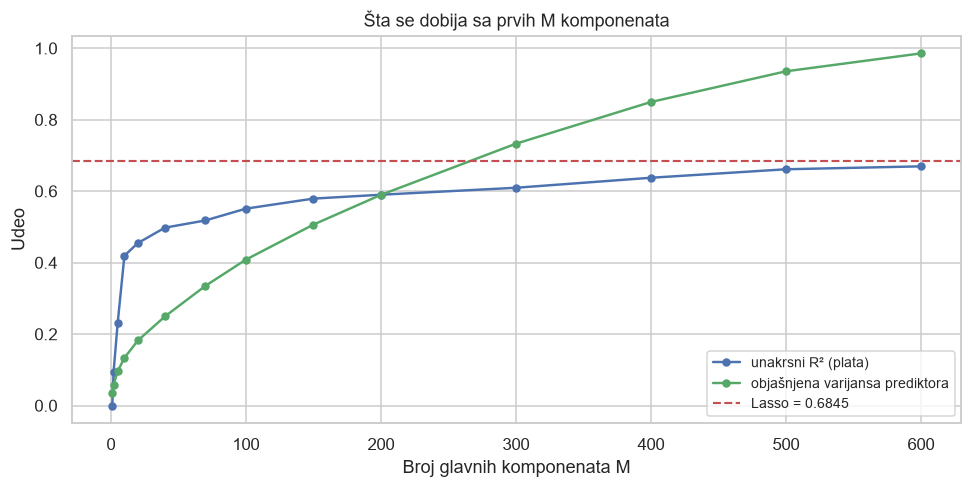

```
    M  R² (plata)  varijansa prediktora   razlika
   10      0.4195                 13.4%   +0.2859
  100      0.5511                 40.8%   +0.1427
  300      0.6095                 73.3%   -0.1233
  500      0.6613                 93.5%   -0.2742
  600      0.6695                 98.6%   -0.3162

komponenata potrebnih da PCR dostigne Lasso: nijedan M do 600 to ne postiže
  najbolji PCR 0.6695   Lasso 0.6845   razlika -0.0150
```

```python
fig, ax = plt.subplots(figsize=(9, 4.6))
ax.plot(COMPONENTS, pcr_table["R2"], marker="o", markersize=4.5, linewidth=1.6,
        color="#4C72B0", label="unakrsni R² (plata)")
ax.plot(COMPONENTS, [explained[size - 1] for size in COMPONENTS], marker="o", markersize=4.5,
        linewidth=1.6, color="#55A868", label="objašnjena varijansa prediktora")
ax.axhline(reference.loc["Lasso", "R2"], color="#C44E52", linestyle="--", linewidth=1.4,
           label=f"Lasso = {reference.loc['Lasso', 'R2']:.4f}")
ax.set_xlabel("Broj glavnih komponenata M")
ax.set_ylabel("Udeo")
ax.set_title("Šta se dobija sa prvih M komponenata")
ax.legend(fontsize=9, loc="lower right")
plt.tight_layout()
plt.show()

print(f"{'M':>5} {'R² (plata)':>11} {'varijansa prediktora':>21} {'razlika':>9}")
for size in (10, 100, 300, 500, 600):
    row = pcr_table.loc[size, "R2"]
    print(f"{size:>5} {row:>11.4f} {100 * explained[size - 1]:>20.1f}% "
          f"{row - explained[size - 1]:>+9.4f}")
print()
print(f"komponenata potrebnih da PCR dostigne Lasso: nijedan M do {max(COMPONENTS)} to ne postiže")
print(f"  najbolji PCR {pcr_table['R2'].max():.4f}   Lasso {reference.loc['Lasso', 'R2']:.4f}   "
      f"razlika {pcr_table['R2'].max() - reference.loc['Lasso', 'R2']:+.4f}")
```

Kod **M = 100** komponente objašnjavaju 40,8% varijanse prediktora a samo 0,5511 varijanse plate. Kod **M = 500** objašnjavaju 93,5% prediktora i 0,6613 plate.

Nijedan M do 600 ne dostiže Lasso — razlika ostaje **−0,0150**.

**Tumačenje:** Razilaženje dve krive je odgovor na pitanje iz motivacije. Komponente **nisu** poređane korisno za naš posao: one koje najviše opisuju kako se ispitanici razlikuju međusobno nisu one koje najviše govore o plati.

To je i praktična granica metode, ne naša greška u primeni. PCA je nenadgledan postupak — ne vidi ciljnu promenljivu — pa u skupu u kom signal nose retke kolone sa malom varijansom nužno greši u poretku. Da je naša matrica imala nekoliko jakih, gustih pravaca, PCR bi radio dobro i sa dvadeset komponenata.

PCR zato ostaje u poređenju modela kao izmerena mogućnost koja nije prošla, a ne kao nešto što nismo probali.

### 6.2 Odakle dolazi pogrešan poredak komponenata

Objašnjenje iz prethodnog odeljka — da komponente nisu poređane korisno jer signal nose retke kolone — zvuči uverljivo, ali je zasad tvrdnja. Merimo ga, jer se lako proverava.

Komponenta je težinska kombinacija svih kolona. Kvadrat težine je udeo te kolone u komponenti, pa se sabiranjem kvadrata preko prvih deset komponenata dobija **od kojih su kolona te komponente sastavljene**. Ako je objašnjenje tačno, kolone po stavci treba da nose neproporcionalno mnogo, a zemlja i valuta neproporcionalno malo.

```python
# The square of a loading is that column's share of a component, so summing the
# squares over the first components says which columns those components are made
# of. That is what decides whether their order is useful for predicting pay.
LOADING_FAMILIES = {"Chose_": "pojedinačne stavke", "Country_": "zemlja",
                    "Currency_": "valuta"}


def family_of(name):
    """Which group of columns this one belongs to, for the table below."""
    for prefix, label in LOADING_FAMILIES.items():
        if name.startswith(prefix):
            return label
    if name.startswith(("Count_", "KeptShare_", "NotAnswered_")):
        return "ostale naše"
    return "ostale nasleđene"


families = np.array([family_of(name) for name in independent])
weight_ten = (pca_all.components_[:10] ** 2).sum(axis=0)
weight_ten = weight_ten / weight_ten.sum()
weight_fifty = (pca_all.components_[:50] ** 2).sum(axis=0)
weight_fifty = weight_fifty / weight_fifty.sum()

# The order the table is printed in, largest group of columns first.
ORDER = ["pojedinačne stavke", "zemlja", "valuta", "ostale naše", "ostale nasleđene"]
print(f"{'grupa kolona':<22} {'kolona':>7} {'udeo kolona':>12} "
      f"{'u prvih 10':>11} {'u prvih 50':>11}")
for label in ORDER:
    inside = families == label
    print(f"{label:<22} {int(inside.sum()):>7} {100 * inside.mean():>11.1f}% "
          f"{100 * weight_ten[inside].sum():>10.1f}% {100 * weight_fifty[inside].sum():>10.1f}%")
print()

# Why they land where they do: a dummy for one country is one among many, so it
# is almost always zero, and a column that rarely changes carries little variance.
binary_column = np.array([set(np.unique(X_train[name].to_numpy())) <= {0.0, 1.0}
                          for name in independent])
print("prosečan udeo jedinica u binarnim kolonama grupe:")
for label in ("pojedinačne stavke", "zemlja", "valuta"):
    inside = (families == label) & binary_column
    columns = list(np.array(independent)[inside])
    print(f"  {label:<22} {X_train[columns].to_numpy().mean():.4f}   "
          f"(binarnih kolona {len(columns)})")
```

```
grupa kolona            kolona  udeo kolona  u prvih 10  u prvih 50
pojedinačne stavke         314        44.4%       58.9%       40.5%
zemlja                      60         8.5%        1.1%       14.8%
valuta                      80        11.3%        1.0%       14.9%
ostale naše                 38         5.4%       13.0%        7.6%
ostale nasleđene           215        30.4%       26.0%       22.3%

prosečan udeo jedinica u binarnim kolonama grupe:
  pojedinačne stavke     0.1521   (binarnih kolona 314)
  zemlja                 0.0165   (binarnih kolona 60)
  valuta                 0.0125   (binarnih kolona 80)
```

**Zapažanje:** Očekivanje se potvrđuje, i razlika je velika.

| grupa kolona | udeo kolona | udeo u prvih 10 komponenata | u prvih 50 |
| --- | --- | --- | --- |
| pojedinačne stavke | 44,4% | **58,9%** | 40,5% |
| zemlja | 8,5% | **1,1%** | 14,8% |
| valuta | 11,3% | **1,0%** | 14,9% |
| ostale naše | 5,4% | 13,0% | 7,6% |
| ostale nasleđene | 30,4% | 26,0% | 22,3% |

Prvih deset komponenata, dakle, sastavljeno je pretežno od **kolona po stavci** — one nose 58,9% težine a čine 44,4% kolona. Zemlja i valuta zajedno nose **oko dva posto**, iako čine skoro petinu kolona. Tek u prvih pedeset komponenata njihov udeo raste na 14,8% i 14,9%.

Drugi deo ispisa pokazuje mehanizam: prosečan udeo jedinica je **0,1521** kod kolona po stavci, a **0,0165** kod zemlje i **0,0125** kod valute.

**Tumačenje:** Ovo objašnjava rezultat iz 6.1 do kraja i bez pretpostavki.

Dummy kolona za jednu zemlju je jedinica kod nepuna dva posto ispitanika, pa se skoro nikad ne menja — a kolona koja se retko menja nosi malu varijansu. PCA komponente poređa **po varijansi**, pa takve kolone nužno gura na kraj liste. Kolona po stavci se, nasuprot tome, menja kod svakog sedmog ispitanika, pa ulazi u prve komponente.

Time je i objašnjeno zašto je PCR-u bilo potrebno **600** komponenata: da bi došao do zemlje i valute, morao je da uzme skoro sve. Ridge i Lasso do njih dolaze odmah, jer gledaju platu, a ne varijansu prediktora.

To je i granica metode koju treba zapisati: **PCR loše radi kad signal nose retke kolone.** U skupu sa nekoliko gustih, jakih pravaca radio bi dobro i sa dvadeset komponenata.

### Šta sekcija ostavlja sledećoj

**PCR sa 600 komponenata daje unakrsni R² 0,6695**, najslabije od četiri pristupa.

- **sažimanje bez ciljne promenljive ne pomaže.** Krive objašnjene varijanse prediktora i objašnjene varijanse plate se razilaze, jer PCA ne zna šta predviđamo;
- **izmereno je i zašto.** Prvih deset komponenata čine 58,9% kolone po stavci, a zemlja i valuta zajedno svega oko dva posto, jer su njihove dummy kolone jedinica kod nepuna dva posto ispitanika i time nose malu varijansu. PCR je zato morao da uzme 600 od 707 komponenata da bi do njih došao;
- **PCR loše radi kad signal nose retke kolone**, i to je granica metode, a ne greška u primeni.

Sva četiri modela su time napravljena i izmerena unakrsnom validacijom. Sledeća sekcija ih poredi merilima za izbor modela sa predavanja, i tek na kraju uzima test skup.

## 7. Poređenje modela

Četiri modela su napravljena i svaki je izmeren istom unakrsnom validacijom. Ostaje da se izaberu, i tu treba razdvojiti dve vrste merila, jer se lako pomešaju.

**Merila za izbor promenljivih unutar jedne vrste modela** — Cp, AIC, BIC i prilagođeni R² — sa predavanja služe da se između ugnežđenih regresija izabere ona sa pravim brojem prediktora. Sva četiri rade tako što uzmu grešku na trening skupu i **kazne je za broj kolona**, svako sa svojom kaznom. Ona su definisana za običnu regresiju sa procenom `σ²`, pa se ne mogu primeniti na Ridge, Lasso ili PCR — kod njih broj kolona nije ni celobrojan u istom smislu.

**Merilo za poređenje različitih vrsta modela** je **greška unakrsne validacije**. Ona ne pretpostavlja ništa o obliku modela, pa jedina može da uporedi sve četiri.

U 7.1 radimo prvo: nad nizom podmodela koje je Lasso izabrao, po jedan za svaku vrednost λ, ponovo fitujemo običnu regresiju i računamo sva četiri merila. Time dobijamo formalnu selekciju u obliku u kom je učena na predavanjima, i vidimo da li se ta merila slažu međusobno i sa unakrsnom validacijom.

### 7.1 Cp, AIC, BIC i prilagođeni R² nad podmodelima

```python
# Cp needs an estimate of the error variance, and it is taken from the largest
# model, as the lectures do.
full_ols = np.linalg.lstsq(np.column_stack([np.ones(len(X_train)), regularized_design]),
                           y_train.to_numpy(), rcond=None)[0]
full_residual = y_train.to_numpy() - (np.column_stack([np.ones(len(X_train)),
                                                       regularized_design]) @ full_ols)
sigma_squared = float(full_residual @ full_residual) / (len(X_train) - len(independent) - 1)
total_squares = float((y_train - y_train.mean()) @ (y_train - y_train.mean()))

rows = []
for position in range(0, len(LASSO_ALPHAS), 3):
    selected = np.where(lasso_coefficients[:, position] != 0)[0]
    if len(selected) == 0:
        continue
    design = np.column_stack([np.ones(len(X_train)), regularized_design[:, selected]])
    coefficients = np.linalg.lstsq(design, y_train.to_numpy(), rcond=None)[0]
    residual_here = y_train.to_numpy() - design @ coefficients
    rss = float(residual_here @ residual_here)
    count = design.shape[1]
    rows.append({
        "kolona": len(selected),
        "Cp": (rss + 2 * count * sigma_squared) / len(X_train),
        "AIC": len(X_train) * np.log(rss / len(X_train)) + 2 * count,
        "BIC": len(X_train) * np.log(rss / len(X_train)) + np.log(len(X_train)) * count,
        "prilagođeni_R2": 1 - (rss / (len(X_train) - count)) / (total_squares / (len(X_train) - 1)),
        "unakrsni_R2": lasso_table["R2"].iloc[position],
    })

criteria = pd.DataFrame(rows)
print(criteria.to_string(index=False, float_format=lambda v: f"{v:.4f}"))
print()
for name, best in [("Cp", "min"), ("AIC", "min"), ("BIC", "min"),
                   ("prilagođeni_R2", "max"), ("unakrsni_R2", "max")]:
    row = criteria[name].idxmin() if best == "min" else criteria[name].idxmax()
    print(f"  {name:<16} bira {int(criteria.loc[row, 'kolona']):>3} kolona")
print()
strict = criteria.loc[criteria["BIC"].idxmin()]
loose = criteria.loc[criteria["unakrsni_R2"].idxmax()]
print(f"izbor BIC-a ({int(strict['kolona'])} kolona) naspram izbora unakrsne validacije "
      f"({int(loose['kolona'])}): unakrsni R² {strict['unakrsni_R2']:.4f} naspram "
      f"{loose['unakrsni_R2']:.4f}, razlika {strict['unakrsni_R2'] - loose['unakrsni_R2']:+.4f}")
```

```
 kolona     Cp         AIC         BIC  prilagođeni_R2  unakrsni_R2
      5 0.1197 -31007.5294 -30961.9934          0.3790       0.2102
     16 0.0956 -34278.9307 -34149.9122          0.5040       0.3611
     45 0.0716 -38494.6716 -38145.5627          0.6291       0.5135
     81 0.0644 -40044.6486 -39422.3240          0.6672       0.6056
    145 0.0602 -41033.2724 -39925.2310          0.6904       0.6523
    220 0.0586 -41431.3014 -39754.0606          0.7002       0.6737
    320 0.0579 -41628.2369 -39192.0637          0.7062       0.6824
    423 0.0578 -41644.6932 -38426.8196          0.7085       0.6845
    517 0.0581 -41587.7603 -37656.4902          0.7092       0.6833
    589 0.0585 -41486.6929 -37008.9914          0.7086       0.6819

  Cp               bira 423 kolona
  AIC              bira 423 kolona
  BIC              bira 145 kolona
  prilagođeni_R2   bira 517 kolona
  unakrsni_R2      bira 423 kolona

izbor BIC-a (145 kolona) naspram izbora unakrsne validacije (423): unakrsni R² 0.6523 naspram 0.6845, razlika -0.0322
```

**Zapažanje:** Četiri merila **ne biraju isti model**.

Cp i AIC su najmanji pri **423** kolone, isto koliko bira i unakrsna validacija. **BIC je najmanji pri 145** kolona, dakle skoro tri puta manjem modelu. Prilagođeni R² je najveći pri **517** kolona, dakle najvećem od tri izbora.

Pri 423 kolone prilagođeni R² iznosi **0,7085**, a njegov najbolji je **0,7092** pri 517 — razlika je sedam desethiljaditih delova.

**Tumačenje:** Razilaženje nije greška nego posledica toga što svako merilo drugačije kažnjava broj kolona, i njihov poredak je upravo onaj koji se sa predavanja i očekuje.

**BIC kažnjava najstrože**, jer mu kazna raste sa `log(n)` po koloni, a kod nas je `log(14.608)` blizu deset — pa je svaka kolona pet puta skuplja nego kod AIC-a, gde je kazna 2. Zato BIC bira najmanji model. **Prilagođeni R² kažnjava najslabije** i zato bira najveći. **Cp i AIC** su između, i kod normalne regresije su međusobno gotovo ekvivalentni — što se i vidi, jer daju identičan izbor.

### Grafik 9 — kako se četiri merila razilaze

**Motivacija:** Iz tabele se vidi koji broj kolona svako merilo bira, ali ne i **koliko je taj izbor izražen** — da li je minimum oštar ili je kriva skoro ravna, pa je izbor slučajan. Uz to su četiri merila u različitim jedinicama i ne mogu se crtati zajedno, pa svako svodimo na sopstveni opseg, od najgore vrednosti do najbolje. Tako se porede oblici, ne nivoi.

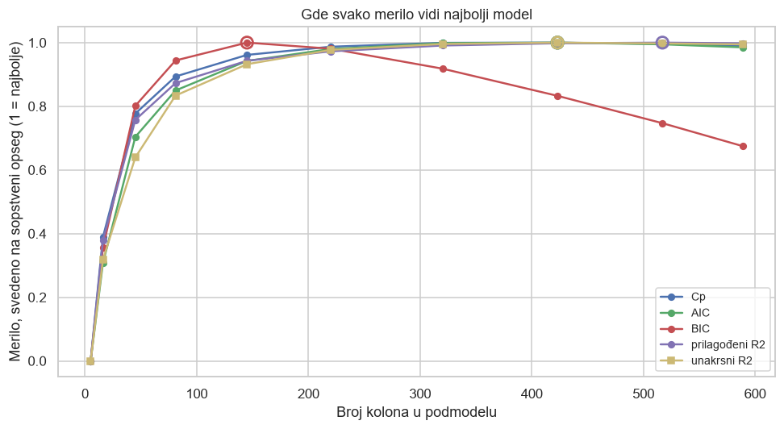

```
koliko svako merilo gubi ako se uzme izbor unakrsne validacije:
  Cp               pri 423 kolona       0.0578   najbolje       0.0578
  AIC              pri 423 kolona  -41644.6932   najbolje  -41644.6932
  BIC              pri 423 kolona  -38426.8196   najbolje  -39925.2310
  prilagođeni_R2   pri 423 kolona       0.7085   najbolje       0.7092
  unakrsni_R2      pri 423 kolona       0.6845   najbolje       0.6845
```

```python
fig, ax = plt.subplots(figsize=(9, 5))
# The five measures drawn together, each with its own colour.
STYLE = {"Cp": "#4C72B0", "AIC": "#55A868", "BIC": "#C44E52", "prilagođeni_R2": "#8172B3",
         "unakrsni_R2": "#CCB974"}

for name, colour in STYLE.items():
    values = criteria[name].to_numpy(dtype=float)
    # Every measure onto the same 0-1 range, with 1 always meaning "best", so the
    # shapes can be compared even though the units cannot.
    if name in ("Cp", "AIC", "BIC"):
        values = -values
    scaled = (values - values.min()) / (values.max() - values.min())
    marker = "o" if name != "unakrsni_R2" else "s"
    ax.plot(criteria["kolona"], scaled, marker=marker, markersize=5, linewidth=1.6,
            color=colour, label=name.replace("_", " "))
    ax.scatter([criteria["kolona"].iloc[int(np.argmax(scaled))]], [1.0], s=90,
               facecolors="none", edgecolors=colour, linewidths=1.8, zorder=5)

ax.set_xlabel("Broj kolona u podmodelu")
ax.set_ylabel("Merilo, svedeno na sopstveni opseg (1 = najbolje)")
ax.set_title("Gde svako merilo vidi najbolji model")
ax.legend(fontsize=9, loc="lower right")
plt.tight_layout()
plt.show()

print("koliko svako merilo gubi ako se uzme izbor unakrsne validacije:")
cv_choice = int(criteria.loc[criteria["unakrsni_R2"].idxmax(), "kolona"])
for name in STYLE:
    at_cv = criteria.loc[criteria["kolona"] == cv_choice, name].iloc[0]
    best = criteria[name].min() if name in ("Cp", "AIC", "BIC") else criteria[name].max()
    print(f"  {name:<16} pri {cv_choice} kolona {at_cv:>12.4f}   najbolje {best:>12.4f}")
```

**Zapažanje:** Četiri krive imaju **različit oblik**, i to je ono što se iz tabele nije videlo.

Ispis pod grafikom pokazuje šta se gubi ako se uzme izbor unakrsne validacije: kod Cp, AIC i unakrsnog R² ništa, jer je 423 i njihov najbolji; kod prilagođenog R² **0,0007**; kod BIC-a razlika je velika (**−38.426,8** naspram **−39.925,2**).

**Tumačenje:** Oblik krivih odlučuje koliko je izbor ozbiljan. Kod Cp i AIC-a minimum je plitak, pa se tvrdnja „najbolje je tačno 423 kolone" ne bi mogla braniti — tačnije je da je između tri i pet stotina kolona sve podjednako dobro. Kod BIC-a je vrh oštar, pa je njegova preporuka jasna, samo se ne tiče predviđanja nego jednostavnosti.

### 7.2 Test skup

Do ovog trenutka test skup nije upotrebljen ni za jednu odluku. Sve — izbor λ, izbor broja komponenata, izbor promenljivih — urađeno je unakrsnom validacijom nad trening skupom.

Sada ga koristimo **jednom**, da izmerimo ono što jedino test skup može da kaže: kako se modeli ponašaju na ljudima koje nisu videli ni posredno, kroz izbor parametara. Svaki model se ponovo uči na **celom** trening skupu, sa vrednostima parametara izabranim ranije, pa se primenjuje na test.

Ovo je i provera unakrsne validacije same. Ako je radila kako treba, poredak modela na testu treba da bude isti kao poredak po unakrsnoj grešci.

```python
# The test set enters the notebook here, and only here.
regularized_test = X_test[independent].to_numpy(dtype=float)
scaled_test = scaler_all.transform(regularized_test)
predictions_on_test = {}

design_train = np.column_stack([np.ones(len(X_train)), regularized_design])
design_test = np.column_stack([np.ones(len(X_test)), regularized_test])
predictions_on_test["obična regresija"] = design_test @ np.linalg.lstsq(
    design_train, y_train.to_numpy(), rcond=None)[0]

predictions_on_test["Ridge"] = ridge_full.predict(scaled_test)

predictions_on_test["Lasso"] = (scaled_test @ lasso_coefficients[:, chosen]
                                + float(y_train.mean()))

pcr_scores = pca_all.transform(scaled_all)[:, :best_components]
pcr_slopes = ((pcr_scores.T @ (y_train.to_numpy() - float(y_train.mean())))
              / (pcr_scores ** 2).sum(axis=0))
predictions_on_test["PCR"] = (pca_all.transform(scaled_test)[:, :best_components]
                              @ pcr_slopes + float(y_train.mean()))

# The reference points from section 2, so the test numbers can be read the same
# way the training numbers were.
predictions_on_test["sama zemlja"] = None
country_train = np.column_stack([np.ones(len(X_train)),
                                 X_train[country_columns].to_numpy(dtype=float)])
country_test = np.column_stack([np.ones(len(X_test)),
                                X_test[country_columns].to_numpy(dtype=float)])
predictions_on_test["sama zemlja"] = country_test @ np.linalg.lstsq(
    country_train, y_train.to_numpy(), rcond=None)[0]
predictions_on_test["medijana treninga"] = np.full(len(X_test), float(y_train.median()))

order = ["medijana treninga", "sama zemlja", "obična regresija", "PCR", "Ridge", "Lasso"]
on_test = pd.DataFrame({name: metrics(y_test, predictions_on_test[name])
                        for name in order}).T
show_metrics(on_test)
print()
print(f"{'model':<20} {'unakrsni R²':>12} {'test R²':>9} {'razlika':>9}")
pairs = [("medijana treninga", "medijana treninga"), ("sama zemlja", "samo Country"),
         ("obična regresija", "sve kolone, regresija"), ("PCR", "PCR"),
         ("Ridge", "Ridge"), ("Lasso", "Lasso")]
for test_name, cv_name in pairs:
    cv_value = reference.loc[cv_name, "R2"]
    test_value = on_test.loc[test_name, "R2"]
    print(f"{test_name:<20} {cv_value:>12.4f} {test_value:>9.4f} {test_value - cv_value:>+9.4f}")
print()
best_on_test = on_test["R2"].idxmax()
best_on_cv = max(pairs, key=lambda pair: reference.loc[pair[1], "R2"])[0]
print(f"najbolji po unakrsnoj validaciji: {best_on_cv}")
print(f"najbolji na test skupu:          {best_on_test}")
print(f"poredak se poklapa: {best_on_cv == best_on_test}")
print()
best_test = on_test.loc[best_on_test, "R2"]
print(f"izabrani model naspram same zemlje:        "
      f"{best_test - on_test.loc['sama zemlja', 'R2']:+.4f}")
print(f"izabrani model naspram medijane treninga:  "
      f"{best_test - on_test.loc['medijana treninga', 'R2']:+.4f}")
```

```
                  RMSE_log MAE_log       R2 puta_RMSE puta_MAE promašaj_% promašaj_USD u_okviru_25% u_okviru_2x
medijana treninga   0.4358  0.2941  -0.0345     2.73x    1.97x      43.8%       37,114        29.8%       66.3%
sama zemlja         0.2906  0.2041  +0.5401     1.95x    1.60x      32.1%       22,258        40.7%       78.3%
obična regresija    0.2471  0.1617  +0.6673     1.77x    1.45x      24.3%       17,228        50.9%       87.2%
PCR                 0.2504  0.1647  +0.6585     1.78x    1.46x      24.8%       16,977        50.4%       86.7%
Ridge               0.2466  0.1611  +0.6687     1.76x    1.45x      24.5%       16,997        50.9%       87.4%
Lasso               0.2454  0.1586  +0.6720     1.76x    1.44x      23.8%       16,630        51.6%       87.6%

model                 unakrsni R²   test R²   razlika
medijana treninga         -0.0330   -0.0345   -0.0015
sama zemlja                0.5429    0.5401   -0.0028
obična regresija           0.6769    0.6673   -0.0096
PCR                        0.6695    0.6585   -0.0109
Ridge                      0.6798    0.6687   -0.0111
Lasso                      0.6845    0.6720   -0.0125

najbolji po unakrsnoj validaciji: Lasso
najbolji na test skupu:          Lasso
poredak se poklapa: True

izabrani model naspram same zemlje:        +0.1320
izabrani model naspram medijane treninga:  +0.7066
```

**Zapažanje:** Poredak modela na test skupu je **isti** kao po unakrsnoj validaciji, i to je prva stvar koju treba primetiti.

| model | unakrsni R² | test R² | razlika |
| --- | --- | --- | --- |
| medijana treninga | −0,0330 | −0,0345 | −0,0015 |
| sama zemlja | 0,5429 | 0,5401 | −0,0028 |
| obična regresija | 0,6769 | 0,6673 | −0,0096 |
| PCR | 0,6695 | 0,6585 | −0,0109 |
| Ridge | 0,6798 | 0,6687 | −0,0111 |
| **Lasso** | **0,6845** | **0,6720** | −0,0125 |

**Lasso je najbolji i na testu**, sa R² **0,6720**: tipičan promašaj **23,8%**, odnosno **16.630 dolara**, a kod **87,6%** ispitanika predviđanje je u okviru dvostruko i kod **51,6%** u okviru četvrtine.

Svi modeli su na testu **neznatno slabiji** nego po unakrsnoj validaciji, i to sistematski: razlika ide od −0,0015 kod medijane do −0,0125 kod Lassa.

**Tumačenje:** Iz tabele slede dve stvari.

**Unakrsna validacija je radila.** Da nije, poredak bi se na testu promešao — a nije, čak ni između Ridge-a i Lassa, koje deli manje od pet hiljaditih delova. To znači da su svi izbori napravljeni u sekcijama 4 do 6 bili izbori na osnovu podataka, a ne slučajni.

**Pad od unakrsnog ka test rezultatu je mali i pravilan.** Zanimljivo je da je **veći kod boljih modela** — kod medijane 0,0015, kod Lassa 0,0125. To ima smisla: model koji koristi više promenljivih više zavisi od toga da su te promenljive u novom skupu raspoređene isto kao u starom. Ali ni kod Lassa pad nije takav da bi menjao zaključak.

Naspram same zemlje, koja na testu daje 0,5401, izabrani model dodaje **+0,1320**. Naspram predviđanja medijanom dodaje **+0,7066**. Ta dva broja nose najviše težine od svega izmerenog, jer su jedina dobijena na ljudima koje model nije video ni posredno.

### Šta sekcija ostavlja sledećoj

**Izabrani model je Lasso sa λ = 0,00155 i 423 kolone. Na test skupu daje R² 0,6720**, tipičan promašaj 23,8% i predviđanje u okviru dvostruko kod 87,6% ispitanika.

Tri nalaza:

- **tri merila i unakrsna validacija slažu se na 423 kolone.** BIC bi izabrao 145, uz gubitak 0,0322 unakrsnog R², a prilagođeni R² 517, uz dobitak 0,0007 — poredak strogosti kazni je onaj sa predavanja;
- **poredak modela na testu je isti kao po unakrsnoj validaciji**, što potvrđuje da su izbori u sekcijama 4 do 6 bili zasnovani na podacima;
- **pad sa unakrsnog na test rezultat je mali i veći kod složenijih modela** — od 0,0015 kod medijane do 0,0125 kod Lassa.

Sledeća sekcija čita koeficijente izabranog modela.

## 8. Šta model kaže

Model je izabran, pa se može pitati **šta je naučio**. Odgovor traži dva prevoda i jednu ogradu.

**Prvi prevod: sa standardizovane skale na skalu kolone.** Lasso je učen na standardizovanim kolonama, pa mu koeficijent kaže koliko se plata menja po jednoj standardnoj devijaciji te kolone. Za dummy kolonu to nije upotrebljivo — jedna standardna devijacija indikatora nije ništa konkretno. Zato koeficijente delimo standardnom devijacijom kolone i dobijamo promenu **po jedinici same kolone**: za dummy to je razlika između „ima to obeležje" i osnovne kategorije, za brojčanu kolonu jedna godina staža ili jedan alat.

**Drugi prevod: iz logaritma u procente.** Ciljna promenljiva je dekadni logaritam, pa koeficijent `b` znači da se plata množi sa `10^b`. Promena u procentima je `(10^b − 1) × 100`.

**Ograda:** U sekciji 3 smo izmerili da rasipanje ostatka nije ujednačeno i da ostatak nije normalan, pa **p-vrednosti i intervali poverenja za ove koeficijente nisu pouzdani.** Zato ih čitamo kao veličine, a ne kao rezultate testova, i uz svaki navodimo **na koliko se ispitanika oslanja** — jer koeficijent procenjen na nekoliko ljudi nije isto što i koeficijent procenjen na hiljadama.

### 8.1 Najjači koeficijenti

```python
# From the standardized scale back to the scale of the column itself, and then
# from the logarithm into a percentage change.
per_unit = lasso_coefficients[:, chosen] / scaler_all.scale_
support = X_train[independent].sum().to_numpy()
binary = np.array([set(np.unique(X_train[c].to_numpy())) <= {0.0, 1.0} for c in independent])

effects = pd.DataFrame({
    "kolona": independent,
    "koef_log10": per_unit,
    "promena_%": (10.0 ** per_unit - 1) * 100,
    "ispitanika": np.where(binary, support, len(X_train)),
}).query("koef_log10 != 0")

print("deset koeficijenata koji najviše podižu platu:")
print(effects.nlargest(10, "promena_%").to_string(
    index=False, formatters={"koef_log10": "{:+.4f}".format, "promena_%": "{:+.1f}".format,
                             "ispitanika": "{:,.0f}".format}))
print()
print("deset koji je najviše snižavaju:")
print(effects.nsmallest(10, "promena_%").to_string(
    index=False, formatters={"koef_log10": "{:+.4f}".format, "promena_%": "{:+.1f}".format,
                             "ispitanika": "{:,.0f}".format}))
print()
print("nasleđene brojčane kolone, promena po jednoj jedinici:")
for name in ("WorkExp", "YearsCode", "OrgSize", "JobSat", "ToolCountWork", "ToolCountPersonal"):
    row = effects[effects["kolona"] == name]
    if len(row):
        print(f"  {name:<20} {row['promena_%'].iloc[0]:+7.2f}%")
print()
thin = effects[effects["ispitanika"] < 50]
print(f"koeficijenata koji se oslanjaju na manje od 50 ispitanika: {len(thin)} od {len(effects)}")
print(f"  najjači među njima: {thin.loc[thin['promena_%'].abs().idxmax(), 'kolona']}, "
      f"{thin['promena_%'].abs().max():.1f}% na {int(thin.loc[thin['promena_%'].abs().idxmax(), 'ispitanika'])} ispitanika")
```

```
deset koeficijenata koji najviše podižu platu:
                          kolona koef_log10 promena_% ispitanika
                 DevType_Retired    +0.3715    +135.2          2
       Currency_IRR Iranian rial    +0.3580    +128.0         40
Country_United States of America    +0.3464    +122.0      3,205
                  Country_Israel    +0.2791     +90.2        108
    Currency_MOP Macanese pataca    +0.2383     +73.1          2
             Country_Switzerland    +0.2304     +70.0        214
                  Country_Norway    +0.1725     +48.7        116
       Currency_DKK Danish krone    +0.1717     +48.5        139
                  Country_Canada    +0.1646     +46.1        577
                 Country_Ireland    +0.1499     +41.2         96

deset koji je najviše snižavaju:
                              kolona koef_log10 promena_% ispitanika
                    Country_Viet Nam    -0.9441     -88.6         33
                       Country_Nepal    -0.9383     -88.5         21
         Currency_NGN Nigerian naira    -0.8604     -86.2         40
      Currency_IDR Indonesian rupiah    -0.8577     -86.1         51
        Currency_KES Kenyan shilling    -0.7851     -83.6         31
         Currency_EGP Egyptian pound    -0.6066     -75.3         27
Country_Iran, Islamic Republic of...    -0.5094     -69.1         51
       Currency_LKR Sri Lankan rupee    -0.4638     -65.6         32
        Currency_PKR Pakistani rupee    -0.4332     -63.1         73
      Currency_UAH Ukrainian hryvnia    -0.4158     -61.6        259

nasleđene brojčane kolone, promena po jednoj jedinici:
  WorkExp                +1.13%
  YearsCode              +0.53%
  OrgSize                +4.89%
  JobSat                 +2.00%
  ToolCountWork          +0.16%
  ToolCountPersonal      -0.09%

koeficijenata koji se oslanjaju na manje od 50 ispitanika: 63 od 423
  najjači među njima: DevType_Retired, 135.2% na 2 ispitanika
```

**Zapažanje:** Najjači koeficijenti su gotovo isključivo **zemlje i valute**, i to je očekivano posle sekcije 2, gde su ta dva obeležja bila daleko iznad svih ostalih — 0,5429 i 0,4821, naspram 0,1829 kod trećeg po jačini.

Na strani viših plata: **Sjedinjene Države +122,0%** (na 3.205 ispitanika), **Izrael +90,2%** (108), **Švajcarska +70,0%** (214), **Norveška +48,7%** (116), **Kanada +46,1%** (577). Na strani nižih: **Vijetnam −88,6%** (33), **Nepal −88,5%** (21), nigerijska najra **−86,2%** (40), indonezijska rupija **−86,1%** (51).

Nasleđene brojčane kolone daju čitljive veličine: jedna godina radnog staža **+1,13%**, jedan korak u veličini firme **+4,89%**, jedan poen zadovoljstva poslom **+2,00%**, jedna godina programiranja **+0,53%**.

**Tumačenje:** Tabela se čita na dva nivoa i lako je pogrešiti.

**Ono što je pouzdano** su koeficijenti sa velikim brojem ispitanika. Sjedinjene Države sa 3.205 ispitanika i Kanada sa 577 daju procene na koje se može osloniti, i one kažu ono što je i očekivano: tržište rada objašnjava najveći deo razlike u plati.

**Ono što nije pouzdano** je vrh liste. Koeficijent od +135,2% procenjen na dva čoveka nije nalaz o penzionisanim developerima nego artefakt — sa 707 kolona model ima dovoljno slobode da jednoj retkoj koloni da veliki koeficijent, jer je gubi manje nego što dobija na tim dvema tačkama. To je ista stvar koju smo u 3.4 videli kao polugu jednaku jedinici, samo sada u obliku koeficijenta.

Praktična posledica je da **jačina koeficijenta bez broja ispitanika ne znači ništa**, i zato ih u tabeli prikazujemo zajedno. U nastavku se zato pozivamo samo na koeficijente sa razumnim brojem ispitanika, a ostale navodimo kao poznato ograničenje.

Nasleđene brojčane kolone su pri tome najzahvalnije za tumačenje, jer se odnose na sve ispitanike i imaju prirodnu jedinicu. Godina staža koja donosi **1,13%** je broj koji se može izgovoriti bez ograda.

### Grafik 10 — najjači koeficijenti i koliko ih ljudi podupire

**Motivacija:** Tabela iz 8.1 daje veličine, ali se iz nje ne vidi odnos između **jačine** koeficijenta i **broja ispitanika** na kojima je procenjen — a to je ono što odlučuje da li se koeficijentu može verovati. Crtamo dvadeset najjačih, sa dužinom trake za promenu u procentima i brojem ispitanika ispisanim uz svaku, pa se dva podatka čitaju odjednom.

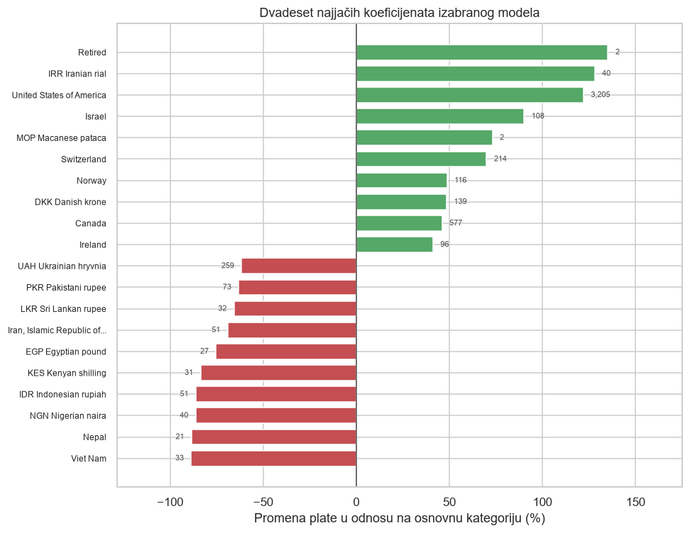

```
kolona                                     promena  ispitanika
DevType_Retired                            +135.2%           2
Currency_IRR Iranian rial                  +128.0%          40
Country_United States of America           +122.0%       3,205
Country_Israel                              +90.2%         108
Currency_MOP Macanese pataca                +73.1%           2
Country_Switzerland                         +70.0%         214
Country_Norway                              +48.7%         116
Currency_DKK Danish krone                   +48.5%         139
Country_Canada                              +46.1%         577
Country_Ireland                             +41.2%          96
Currency_UAH Ukrainian hryvnia              -61.6%         259
Currency_PKR Pakistani rupee                -63.1%          73
Currency_LKR Sri Lankan rupee               -65.6%          32
Country_Iran, Islamic Republic of...        -69.1%          51
Currency_EGP Egyptian pound                 -75.3%          27
Currency_KES Kenyan shilling                -83.6%          31
Currency_IDR Indonesian rupiah              -86.1%          51
Currency_NGN Nigerian naira                 -86.2%          40
Country_Nepal                               -88.5%          21
Country_Viet Nam                            -88.6%          33
```

```python
top = pd.concat([effects.nlargest(10, "promena_%"), effects.nsmallest(10, "promena_%")])
top = top.sort_values("promena_%")
labels = [name.replace("Country_", "").replace("Currency_", "").replace("DevType_", "")[:34]
          for name in top["kolona"]]

fig, ax = plt.subplots(figsize=(9, 7))
colours = ["#C44E52" if value < 0 else "#55A868" for value in top["promena_%"]]
ax.barh(range(len(top)), top["promena_%"], color=colours, height=0.72)
ax.axvline(0, color="#4C4C4C", linewidth=1)
ax.set_yticks(range(len(top)))
ax.set_yticklabels(labels, fontsize=8)
ax.set_xlabel("Promena plate u odnosu na osnovnu kategoriju (%)")
ax.set_title("Dvadeset najjačih koeficijenata izabranog modela")

for position, (value, people) in enumerate(zip(top["promena_%"], top["ispitanika"])):
    offset = 4 if value > 0 else -4
    ax.text(value + offset, position, f"{int(people):,}", va="center",
            ha="left" if value > 0 else "right", fontsize=7.5, color="#4C4C4C")
ax.set_xlim(top["promena_%"].min() - 40, top["promena_%"].max() + 40)
plt.tight_layout()
plt.show()

print(f"{'kolona':<40} {'promena':>9} {'ispitanika':>11}")
for _, row in top.iloc[::-1].iterrows():
    print(f"{row['kolona'][:39]:<40} {row['promena_%']:>+8.1f}% {int(row['ispitanika']):>11,}")
```

**Zapažanje:** Grafik pokazuje ono što se iz tabele nije videlo — **nema veze između jačine koeficijenta i broja ispitanika na kojima je procenjen.** Najduže trake na oba kraja pripadaju kolonama sa dvocifrenim ili jednocifrenim brojem ljudi, dok Sjedinjene Države sa **3.205** ispitanika stoje tek na trećem mestu po jačini.

Uz to se vidi da je raspored po smeru **nesimetričan**: negativne trake idu do **−88,6%**, pozitivne do **+135,2%**, ali su negativne gušće u opsegu preko šezdeset posto.

**Tumačenje:** Nesimetričnost ima jednostavno objašnjenje. Osnovna kategorija za zemlju i valutu je ona koja je alfabetski prva, a ne prosečna, pa se koeficijenti mere od nje — i pošto je većina ispitanika u skupu iz zemalja sa visokim platama, više je zemalja koje su ispod te osnovice nego iznad.

Praktično, grafik je opomena za tumačenje koje sledi: **koeficijenti se ne smeju rangirati samo po jačini.** Traka sa brojem 2 uz nju i traka sa brojem 3.205 ne znače istu vrstu tvrdnje, i to se iz same dužine ne vidi.

### Šta sekcija ostavlja sledećoj

Koeficijenti izabranog modela pročitani su i prevedeni u procente.

Sledeća sekcija gleda gde model greši.

## 9. Gde model greši i šta ostaje kao ograničenje

Jedan broj za ceo skup — test R² od oko 0,67 — krije to da model ne greši svuda isto. U 1.2 smo postavili očekivanje da će greška biti veća kod ispitanika sa vrlo malim prijavljenim iznosima, a u 3.2 i 3.4 videli prve tragove toga. Ovde to merimo na test skupu, po dva osnova: po nivou plate i po zemlji.

Sve u ovoj sekciji računa se nad **predviđanjima izabranog modela na test skupu**, dakle nad ljudima koje model nije video.

### 9.1 Greška po nivou plate

```python
chosen_predictions = predictions_on_test["Lasso"]
test_error = chosen_predictions - y_test.to_numpy()
test_ratio = 10.0 ** test_error

by_level = pd.DataFrame({
    "decil": pd.qcut(test[TARGET], 10, labels=False),
    "plata": test[TARGET].to_numpy(),
    "greška": test_error,
    "odnos": test_ratio,
})
level_table = by_level.groupby("decil").agg(
    plata_medijana=("plata", "median"), ispitanika=("plata", "size"),
    prosečna_greška=("greška", "mean"),
    tipičan_promašaj=("odnos", lambda values: float(np.median(np.abs(values - 1)) * 100)),
    odnos_medijana=("odnos", "median"))

print(level_table.to_string(float_format=lambda v: f"{v:,.3f}"))
print()
print(f"prosečna greška u najnižem decilu: {level_table['prosečna_greška'].iloc[0]:+.3f} u log10, "
      f"dakle model predviđa {10 ** level_table['prosečna_greška'].iloc[0]:.2f} puta više")
print(f"prosečna greška u najvišem decilu: {level_table['prosečna_greška'].iloc[-1]:+.3f}, "
      f"dakle {10 ** level_table['prosečna_greška'].iloc[-1]:.2f} puta")
middle = level_table.iloc[2:8]["prosečna_greška"]
print(f"u šest srednjih decila greška se kreće od {middle.min():+.3f} do {middle.max():+.3f}")
```

```
       plata_medijana  ispitanika  prosečna_greška  tipičan_promašaj  odnos_medijana
decil
0           9,299.000         366            0.331            80.175           1.802
1          31,324.000         365            0.015            32.193           1.123
2          47,922.000         367            0.004            25.360           1.064
3          61,264.000         363           -0.003            23.384           1.040
4          75,000.000         393           -0.033            20.626           1.003
5          88,171.000         337           -0.031            17.678           0.959
6         104,000.000         365           -0.035            19.124           0.941
7         125,296.000         378           -0.070            21.081           0.888
8         160,000.000         359           -0.044            19.585           0.954
9         216,000.000         359           -0.158            26.503           0.744

prosečna greška u najnižem decilu: +0.331 u log10, dakle model predviđa 2.14 puta više
prosečna greška u najvišem decilu: -0.158, dakle 0.70 puta
u šest srednjih decila greška se kreće od -0.070 do +0.004
```

**Zapažanje:** Greška nije ista u svim decilima. U najnižem, sa medijanom plate **9.299** dolara, prosečna greška je **+0,331** u logaritmu — model predviđa **2,14 puta** više nego što ispitanik zarađuje. U najvišem, sa medijanom **216.000**, greška je **−0,158**, dakle **0,70 puta** stvarnog iznosa. U šest srednjih decila kreće se od **−0,070 do +0,004**, praktično nula.

Tipičan promašaj prati isti oblik: **80,2%** u najnižem decilu, **26,5%** u najvišem, a najmanji je **17,7%** u decilu sa medijanom 88.171 dolara.

**Tumačenje:** Predznak greške menja se **jednom** duž raspona — pozitivan na dnu, negativan na vrhu — i to je obrazac **vraćanja ka sredini**. Regresija predviđa uslovnu srednju vrednost, pa kod ispitanika daleko od nje predviđanje vuče ka centru. Da model greši slučajno, znaci bi se mešali po decilima.

Grafik ispod pokazuje isti nalaz u dva oblika, jer se iz brojeva ne vidi da li je prelaz sa precenjivanja na potcenjivanje gladak ili skokovit.

### Grafik 11 — greška po nivou plate

**Motivacija:** Brojevi iz tabele pokazuju da greška nije ista u svim decilima, ali se iz njih ne vidi **da li je obrazac pravilan**. Ako model podjednako promašuje na oba kraja a tačan je u sredini, to je poznat obrazac vraćanja ka sredini i ima jedno objašnjenje; ako greši samo na jednom kraju, objašnjenje je drugo. Crtamo prosečnu grešku po decilu, sa nulom kao referencom.

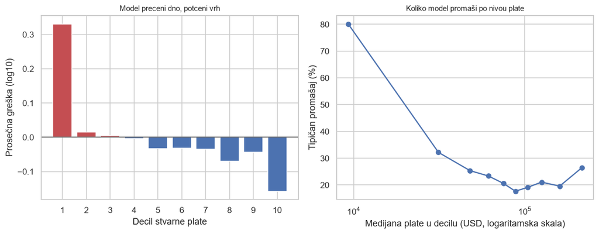

```
tipičan promašaj: najmanji 17.7% u decilu sa medijanom 88,171 USD
                  najveći 80.2% u decilu sa medijanom 9,299 USD
ispitanika sa platom ispod 1.000 USD u testu: 17
  njihov tipičan promašaj: 1,199%
  ostali: 23.7%
```

```python
fig, axes = plt.subplots(1, 2, figsize=(11, 4.4))

ax = axes[0]
colours = ["#C44E52" if value > 0 else "#4C72B0"
           for value in level_table["prosečna_greška"]]
ax.bar(range(1, 11), level_table["prosečna_greška"], color=colours)
ax.axhline(0, color="#4C4C4C", linewidth=1)
ax.set_xticks(range(1, 11))
ax.set_xlabel("Decil stvarne plate")
ax.set_ylabel("Prosečna greška (log10)")
ax.set_title("Model preceni dno, potceni vrh", fontsize=10)

ax = axes[1]
ax.plot(level_table["plata_medijana"], level_table["tipičan_promašaj"], marker="o",
        markersize=6, linewidth=1.6, color="#4C72B0")
ax.set_xscale("log")
ax.set_xlabel("Medijana plate u decilu (USD, logaritamska skala)")
ax.set_ylabel("Tipičan promašaj (%)")
ax.set_title("Koliko model promaši po nivou plate", fontsize=10)

plt.tight_layout()
plt.show()

print(f"tipičan promašaj: najmanji {level_table['tipičan_promašaj'].min():.1f}% u decilu sa medijanom "
      f"{level_table.loc[level_table['tipičan_promašaj'].idxmin(), 'plata_medijana']:,.0f} USD")
print(f"                  najveći {level_table['tipičan_promašaj'].max():.1f}% u decilu sa medijanom "
      f"{level_table.loc[level_table['tipičan_promašaj'].idxmax(), 'plata_medijana']:,.0f} USD")
low = test[TARGET].to_numpy() < 1000
print(f"ispitanika sa platom ispod 1.000 USD u testu: {int(low.sum())}")
print(f"  njihov tipičan promašaj: {100 * float(np.median(np.abs(test_ratio[low] - 1))):,.0f}%")
print(f"  ostali: {100 * float(np.median(np.abs(test_ratio[~low] - 1))):.1f}%")
```

Sedamnaest ispitanika u testu ima platu ispod hiljadu dolara, i njihov tipičan promašaj je **1.199%**, naspram **23,7%** kod svih ostalih.

**Tumačenje:** Oblik slova U znači da model najbolje radi tamo gde ima najviše podataka, a slabije na oba kraja — što je i očekivano, ali je desni krak mnogo blaži od levog.

Promašaj od 1.199% kod sedamnaest ljudi pokazuje da za njih model nema nikakvu upotrebu. To je isti nalaz koji smo u 1.2 postavili kao očekivanje a u 3.2 i 3.4 videli u obliku obrnute lepeze i netipičnih vrednosti — i time je očekivanje potvrđeno, na test skupu i u dolarima.

Za praktičnu upotrebu iz ovoga sledi jasna granica: **model je upotrebljiv u srednjih osamdeset posto raspona plata**, gde je tipičan promašaj između 17,7% i 32,2%. Van tog opsega predviđanja treba čitati sa velikim rezervom, i to je tvrdnja koja se sada može potkrepiti brojem.

### 9.2 Greška po zemlji

Zemlja je najjače obeležje u modelu, pa je i prvo mesto na kom treba proveriti da li model radi podjednako za sve. Gledamo samo zemlje sa najmanje četrdeset ispitanika u test skupu, jer se na manjem broju prosečna greška ne može razlikovati od slučaja.

```python
# Below this many respondents an average error cannot be told from chance.
MINIMUM_FOR_COUNTRY = 40

by_country = pd.DataFrame({"zemlja": test["Country"].to_numpy(), "greška": test_error,
                           "odnos": test_ratio})
country_table = by_country.groupby("zemlja").agg(
    ispitanika=("greška", "size"), prosečna_greška=("greška", "mean"),
    tipičan_promašaj=("odnos", lambda values: float(np.median(np.abs(values - 1)) * 100)))
country_table = country_table[country_table["ispitanika"] >= MINIMUM_FOR_COUNTRY]
country_table = country_table.sort_values("prosečna_greška")

print(f"zemalja sa bar {MINIMUM_FOR_COUNTRY} ispitanika u testu: {len(country_table)} "
      f"(nose {int(country_table['ispitanika'].sum()):,} od {len(test):,} ispitanika)")
print()
print("pet zemalja kod kojih model najviše potcenjuje platu:")
print(country_table.head(5).to_string(float_format=lambda v: f"{v:,.3f}"))
print()
print("pet kod kojih najviše precenjuje:")
print(country_table.tail(5).to_string(float_format=lambda v: f"{v:,.3f}"))
print()
print(f"raspon prosečne greške: od {country_table['prosečna_greška'].min():+.3f} do "
      f"{country_table['prosečna_greška'].max():+.3f} u log10")
print(f"  u odnosu: od {10 ** country_table['prosečna_greška'].min():.2f} do "
      f"{10 ** country_table['prosečna_greška'].max():.2f} puta")
print(f"tipičan promašaj: od {country_table['tipičan_promašaj'].min():.1f}% "
      f"({country_table['tipičan_promašaj'].idxmin()}) do "
      f"{country_table['tipičan_promašaj'].max():.1f}% ({country_table['tipičan_promašaj'].idxmax()})")
```

```
zemalja sa bar 40 ispitanika u testu: 20 (nose 2,887 od 3,652 ispitanika)

pet zemalja kod kojih model najviše potcenjuje platu:
             ispitanika  prosečna_greška  tipičan_promašaj
zemlja
Ukraine             122           -0.085            71.929
Switzerland          78           -0.041            14.867
France              145           -0.021            17.024
Australia            69           -0.018            17.088
Poland               91           -0.018            27.951

pet kod kojih najviše precenjuje:
          ispitanika  prosečna_greška  tipičan_promašaj
zemlja
India            180            0.008            49.515
Brazil            94            0.015            32.972
Other            122            0.027            40.288
Portugal          43            0.042            31.559
Romania           46            0.107            33.835

raspon prosečne greške: od -0.085 do +0.107 u log10
  u odnosu: od 0.82 do 1.28 puta
tipičan promašaj: od 14.0% (Austria) do 71.9% (Ukraine)
```

**Zapažanje:** Dvadeset zemalja ima najmanje četrdeset ispitanika u testu i one nose **2.887 od 3.652** ispitanika.

**Prosečna greška je po zemljama mala.** Raspon ide od **−0,085** kod Ukrajine do **+0,107** kod Rumunije, dakle od **0,82** do **1,28 puta**. Model, dakle, ni za jednu zemlju sistematski ne promašuje više od tridesetak posto u prosečnom smeru.

**Tipičan promašaj se razlikuje mnogo više** — od **14,0%** u Austriji do **71,9%** u Ukrajini.

**Tumačenje:** Razlika između tih dveju mera je ono što treba pročitati.

Mala prosečna greška znači da model **nije pristrasan po zemljama**: ne postoji zemlja za koju sistematski predviđa previsoko ili prenisko. To je i očekivano, jer zemlja u modelu ima svoju kolonu, pa model za svaku uči sopstveni nivo.

Veliki tipičan promašaj kod pojedinih zemalja znači da unutar njih model **slabo razlikuje ljude**. Kod Ukrajine je promašaj 71,9% uz prosečnu grešku svega −0,085 — dakle greši u obe strane podjednako. To je ista grupa koja se javlja kroz celu sekciju: u prethodnom notebook-u smo izmerili da su ispitanici sa prijavljenim iznosima ispod hiljadu dolara najviše iz Ukrajine.

Iz ovoga sledi jedna korisna tvrdnja: kvalitet predviđanja se razlikuje po zemljama, ali razlika nije u pristrasnosti nego u **rasipanju** — što je manji problem, jer ne iskrivljuje zaključke nego samo ograničava tačnost.

### 9.3 Šta ostaje kao ograničenje

Tri stvari ovaj model ne rešava i treba ih reći izričito, jer se iz brojeva u prethodnim odeljcima ne čitaju same.

**Uzorak nije slučajan uzorak programera.** U njemu su ljudi koji su popunili anketu Stack Overflow-a i prijavili platu. U prethodnom notebook-u smo izmerili da prijavljivanje plate zavisi od posmatranih obeležja — zemlja, veličina firme, način rada — i da brisanje redova bez plate pomera sastav uzorka. Model, dakle, opisuje **tu populaciju**, a ne sve programere, i predviđanja za nekoga van nje nemaju zagarantovanu vrednost.

**Ispitanici sa vrlo malim prijavljenim iznosima ostaju nerešeni.** Njih smo zadržali svesno, jer bi svaka apsolutna donja granica bila izmišljen broj, i cenu te odluke sada vidimo na tri mesta: obrnuta lepeza u 3.2, gušći levi rep u 3.3, i najveća greška u prvom decilu u 9.1. Alternativa — izbaciti ih — popravila bi sve tri mere, ali bi značila da podatke prilagođavamo modelu.

**Ideja o samopopunjavanju ciljne promenljive nije izvedena.** U izveštaju poslatom na odobrenje pominjali smo mogućnost da se model istreniran na onima koji su prijavili platu upotrebi da popuni ostale, pa da se trenira ponovo. Nju **ne radimo**, i razlog je merenje iz prethodnog notebook-a: nedostajanje plate nije slučajno, pa bi model popunjavao onim što je naučio na sistematski drugačijoj grupi i time **učvrstio sopstvenu pristrasnost**, a rezultat bi izgledao bolje jer se meri na podacima koje je sam napravio. Za ozbiljan pokušaj bilo bi potrebno i sačuvati redove bez prijavljene plate, koji u isporučenim podacima ne postoje. Ostaje kao predlog za dalji rad, uz obavezno poređenje sa osnovnim modelom, a ne kao zamena za njega.

### Šta sekcija ostavlja sledećoj

Model greši **pravilno**, i to je jedan od korisnijih nalaza notebook-a.

Tri nalaza:

- **greška prati nivo plate.** Na dnu model preceni 2,14 puta, na vrhu potceni na 0,70, a u šest srednjih decila greška je praktično nula. To je vraćanje ka sredini i sledi iz toga što regresija predviđa uslovnu srednju vrednost;
- **model je upotrebljiv u srednjih osamdeset posto raspona**, gde je tipičan promašaj između 17,7% i 32,2%. Kod sedamnaest ispitanika sa platom ispod hiljadu dolara promašaj je 1.199% i model za njih nema upotrebu;
- **po zemljama model nije pristrasan ali je nejednako tačan.** Prosečna greška ide od 0,82 do 1,28 puta, a tipičan promašaj od 14,0% u Austriji do 71,9% u Ukrajini.

Ostaje da se predviđanja i koeficijenti sačuvaju i da se izvuče zaključak.

## 10. Čuvanje i zaključak

Iz notebook-a izlaze dve stvari koje vredi sačuvati, i nijedna nije sam model — njega bi svako ponovno pokretanje dalo isti, jer su svi izbori zapisani u kodu.

**Predviđanja na test skupu**, uz stvarnu platu i grešku, da se svaka tvrdnja iz devete sekcije može proveriti bez ponovnog računanja. **Koeficijenti izabranog modela**, prevedeni u promenu u procentima i sa brojem ispitanika koji ih podupire, jer je to tabela na koju se poziva osma sekcija.

Oba idu u `data/processed/`, pored postojećih fajlova.

```python
predictions_frame = pd.DataFrame({
    "ConvertedCompYearly": test[TARGET].to_numpy(),
    "log_comp": y_test.to_numpy(),
    "predicted_log_comp": chosen_predictions,
    "predicted_usd": 10.0 ** chosen_predictions,
    "error_log": test_error,
    "ratio_predicted_actual": test_ratio,
    "Country": test["Country"].to_numpy(),
})
coefficients_frame = effects.rename(columns={
    "kolona": "column", "koef_log10": "coefficient_log10",
    "promena_%": "change_percent", "ispitanika": "respondents"}
).sort_values("change_percent", ascending=False)

predictions_path = PROCESSED_DIR / "test_predictions.csv.gz"
coefficients_path = PROCESSED_DIR / "model_coefficients.csv"
predictions_frame.to_csv(predictions_path, index=False, encoding="utf-8", compression="gzip")
coefficients_frame.to_csv(coefficients_path, index=False, encoding="utf-8")

for path in (predictions_path, coefficients_path):
    print(f"{path.name:<28} {path.stat().st_size / 1024:>7.1f} kB")
print()

# Read back, because writing and reading a file can change what is in it.
predictions_check = pd.read_csv(predictions_path)
coefficients_check = pd.read_csv(coefficients_path)
print(f"predviđanja: {predictions_check.shape[0]:,} redova x {predictions_check.shape[1]} kolona")
print(f"koeficijenti: {coefficients_check.shape[0]:,} redova x {coefficients_check.shape[1]} kolona")
print(f"test R² ponovo izračunat iz fajla: "
      f"{metrics(predictions_check['log_comp'], predictions_check['predicted_log_comp'])['R2']:.4f}")
print()
print("konačna tabela svih modela, unakrsna validacija i test:")
summary = pd.DataFrame({
    "unakrsni_R2": [reference.loc[cv, "R2"] for _, cv in pairs],
    "test_R2": [on_test.loc[t, "R2"] for t, _ in pairs],
    "test_promašaj_%": [on_test.loc[t, "promašaj_%"] for t, _ in pairs],
    "test_u_okviru_2x": [on_test.loc[t, "u_okviru_2x"] for t, _ in pairs],
}, index=[t for t, _ in pairs])
print(summary.to_string(float_format=lambda v: f"{v:.4f}"))
```

```
test_predictions.csv.gz        175.4 kB
model_coefficients.csv          34.6 kB

predviđanja: 3,652 redova x 7 kolona
koeficijenti: 423 redova x 4 kolona
test R² ponovo izračunat iz fajla: 0.6720

konačna tabela svih modela, unakrsna validacija i test:
                   unakrsni_R2  test_R2  test_promašaj_%  test_u_okviru_2x
medijana treninga      -0.0330  -0.0345          43.7943           66.3198
sama zemlja             0.5429   0.5401          32.0820           78.3406
obična regresija        0.6769   0.6673          24.2983           87.2399
PCR                     0.6695   0.6585          24.7792           86.7470
Ridge                   0.6798   0.6687          24.5207           87.4042
Lasso                   0.6845   0.6720          23.8348           87.6232
```

**Zapažanje:** Oba fajla su zapisana i pročitana nazad. Predviđanja imaju **3.652 reda i 7 kolona**, koeficijenti **423 reda i 4 kolone**, a test R² ponovo izračunat iz fajla iznosi **0,6720** — isto kao pre čuvanja.

**Tumačenje:** Provera čitanjem je ista ona koju smo radili u prethodnom notebook-u i ima isti razlog: zapis u CSV i čitanje nazad mogu da promene tip kolone. Pošto se test R² iz fajla poklapa sa onim iz sekcije 7, fajl sadrži ono što mislimo da sadrži.

Konačna tabela na kraju ispisa sabira ceo notebook — svih šest modela, unakrsni i test rezultat jedan uz drugi.

## Zaključak notebook-a

Pošli smo od 429 kolona iz prethodnog notebook-a, a završavamo sa jednim izabranim modelom i merenjem koje se može braniti.

**Izabrani model je Lasso** sa λ = 0,00155, koji koristi **423 od 707 kolona**. Na test skupu daje **R² 0,6720**, tipičan promašaj **23,8%** odnosno **16.630 dolara**, a kod **87,6%** ispitanika predviđanje je u okviru dvostruko. Naspram same zemlje, koja na testu daje 0,5401, to je **+0,1320**.

Put do tog rezultata bio je sledeći:

1. **Merila postavljena pre prvog modela** — RMSE, MAE i R² u logaritmu, prevedeni u promašaj u procentima i dolarima, sve preko unakrsne validacije sa deset delova. Uz njih tri izmerena stepenika: konstanta (−0,0001), najjače pojedinačno obeležje `Country` (0,5429) i sva anketna obeležja bez ijedne naše promenljive (0,6668).
2. **Izmereno koliko slobode model ima** — na nasumično promešanoj ciljnoj promenljivoj regresija sa 709 kolona dobija R² 0,0471 na treningu, a −0,0573 po unakrsnoj validaciji. Time je unapred bilo poznato koliko trening rezultat precenjuje model.
3. **Obična regresija** — unakrsni R² 0,6769. Dijagnostika je pokazala da linearnost stoji, a ujednačenost rasipanja i normalnost ostatka ne stoje, pa se p-vrednosti koeficijenata ne smeju čitati kao pouzdane. Uticajnih opservacija nema, ali četiri ispitanika model uči napamet.
4. **Ridge** — 0,6798, dakle +0,0029. Kazna jasno smanjuje koeficijente ali skoro ne menja grešku, pa veliki koeficijenti nisu bili problem.
5. **Lasso** — 0,6845 uz 284 kolone ukinute. Problem je, dakle, bio **broj** kolona.
6. **Regresija na glavne komponente** — 0,6695, najslabija, jer PCA poređa komponente po varijansi prediktora a ne po vezi sa platom.
7. **Formalna selekcija** — Cp, AIC i unakrsna validacija slažu se na 423 kolone; BIC bi izabrao 145 uz gubitak 0,0322, prilagođeni R² 517 uz dobitak 0,0007.

**Tri nalaza koja vredi izdvojiti:**

**Doprinos prethodnog notebook-a je stvaran ali skroman.** Naših 352 kolone dodaju **+0,0101** unakrsnog R² preko svega što anketa daje sama. Na trening skupu je izgledao znatno veći, a razlika je upravo ono prilagođavanje šumu koje smo izmerili na početku.

**Lasso se ne slaže sa svim našim hipotezama.** Sve 16 kolona `Count_` i svih 7 `KeptShare_` spustio je na nulu, dok je od 314 kolona po stavci zadržao 168. To ne obara Hipotezu 6 — ona je merila da brojevi nose signal preko zemlje i staža, i nosili su ga — ali pokazuje da u društvu sa kolonama po stavci postaju suvišni, jer su njihov zbir.

**Poredak modela na testu je isti kao po unakrsnoj validaciji.** To je najbolji dokaz da postupak nije biran prema ishodu: svi izbori napravljeni su nad trening skupom, a test ih je potvrdio.

**Šta ostaje otvoreno:**

- **Model je upotrebljiv u srednjih osamdeset posto raspona plata.** Na dnu preceni 2,14 puta, na vrhu potceni na 0,70, a kod sedamnaest ispitanika sa platom ispod hiljadu dolara promašaj je 1.199%.
- **Uzorak nije slučajan uzorak programera** nego onih koji su popunili anketu i prijavili platu, a prijavljivanje zavisi od posmatranih obeležja.
- **Interakcije nisu probane.** Razlike postojećih kolona odbačene su u prethodnom notebook-u jer ih linearni model pravi sam; proizvodi i odnosi to nisu, i ostaju kao mogućnost.
- **Samopopunjavanje ciljne promenljive nije izvedeno**, iz razloga navedenih u 9.3, i za ozbiljan pokušaj bilo bi potrebno sačuvati i redove bez prijavljene plate.
- **Nelinearni modeli nisu probani.** Stabla i ansambli nisu deo gradiva ovog predmeta, pa su izvan obima rada, ali bi bili prvi sledeći korak.